# 2022_2_14_CHAP_9

Chapter 9: The Cist Tombs

Python Notebook

Chris Mavromatis

May 1 2023

# Metadata

- **Associated Publication**: Given, Michael, Chris Mavromatis, and R. Smadar Gabrieli, ed. (2024) City and Cemetery: Excavations at Kourion’s Amathous Gate Cemetery, Cyprus. The Excavations of Danielle A. Parks (Annual of the American Society of Overseas Research, Volumes 76 & 77, ASOR).
  - **Associationd Publication Chapter(s)**:
    - Mavromatis, Christopher *et al*. (2024) Chapter 9 The cist Tombs. Pp: 147-200. In Given, Michael, Chris Mavromatis, and R. Smadar Gabrieli, ed. City and Cemetery: Excavations at Kourion’s Amathous Gate Cemetery, Cyprus. The Excavations of Danielle A. Parks (Annual of the American Society of Overseas Research, Volumes 76 ASOR).
    - Mavromatis, Christopher and Michael Given (2024), Chapter 3 Methodology. Pp: 21-28. In Given, Michael, Chris Mavromatis, and R. Smadar Gabrieli, ed. (2024) City and Cemetery: Excavations at Kourion’s Amathous Gate Cemetery, Cyprus. The Excavations of Danielle A. Parks (Annual of the American Society of Overseas Research, Volume 76 ASOR).
- **File Name**: Chapter 9 Python Notebook
- **File Format**: HTML
- **Software**:
  - Python (3.10.10), Ipython (8.12.0),
    - Python Distibution: Anaconda 3
  - Visual Studio Code (1.79.2)
- **Hardware**:
  - MacBook Air 10, M1
    - 8 GIG RAM
    - CPU: Apple M1
    - GPU: Apple M1
  - Lennovo IdeaPad 3
    - 12 GIG RAM
    - CPU: 11th Gen Intel i5
    - GPU: Intel TigerLake-LP G2
- **Operating System Used to Create File**:
  - Ubuntu Linux 22.04.02 LTS (Kernal 6.8.0-31)
    - 64 bit, X86
  - MacOS 14.5 (Kernel Darwin 23.5.0)
    - 64 bit, Arm64
- **Date of Creation/Last File Update**:
  - Creation: 02 January 2021
  - Last File Update: 01 May 2023
- **Processing History**:
  - Analysis of cleaned artifact datasets by Depositional Unit.
- **Python Packages**:
  - scipy : 1.10.0
  - matplotlib: 3.7.1
  - watermark : 2.4.3
  - pandas : 1.5.3
  - seaborn : 0.12.2
  - re : 2.2.1
  - numpy : 1.23.5
  - sqlite3 : 2.6.0
- **Python Moduels Created For the Project**:
  - Mavromatis, C. (2023) [KAGC_Functions (Version 2.0)](https://github.com/ChrisMavromatis/KAGC)
  - Mavromatis, C. (2023) [KAGC_Contexts_Class (Version 3.0)](https://github.com/ChrisMavromatis/KAGC)
  - Mavromatis, C. (2023) [KAGC_Marker_Artifacts (Version 2.0)](https://github.com/ChrisMavromatis/KAGC)
  - Mavromatis, C. (2023) [KAGC_Depositional_Units (Version 2.0)](https://github.com/ChrisMavromatis/KAGC)

**Table of contents**

- Data, Packages, Package Versions, and Hardware Profile
  - Package Versions and Hardware Information
  - Notebook Specific Functions
- Introduction
- The TA01 Area: TA01, TrA02, TrA07, and TrA08
  - DUS A501
    - CAT Nos
    - Dating
      - MCLS TPQS
      - Meadian Dates
    - Marker Groups
    - Faunal
  - DU A801
  - DU A014
  - DU A015
  - DU A017
  - FA04
- Area B
  - BDS-1
    - Cat items
    - FCounts
    - MCLS TPQS
    - MG1
    - MG3
    - Late Dates
    - BDS-1 Summary
    - MCLS TPQs
    - CC TPQS
    - BDS-1 Mean Median Dates
    - Faunal
  - DU B502
    - Cat Nos
    - FCounts
    - MCLS TPQs
    - CC TPQS
    - B502 Summary
    - Marker Groups
    - Faunal
  - DU B503
    - Cat nos
    - FCounts
    - MCLS TPQs
    - CC TPQS
      - ubiquity
    - B503 Summary
    - Mean Median Dates
    - Marker Groups
      - comments
- Area B Case studies
  - TB03
  - TB08
  - TB09
  - TB10
  - TB18
  - TrB09
- Area E
  - E501
  - E502
  - E503
    - Case studies: TE20 & TE22
- Discussion and Analysis
- Late Items (400 AD +)
  - Catalog Late Items from Area A
  - Late Items from Area B
    - B503
    - B502
    - BDS1
- Personal Items and adornments Tombs: Spatial
  - Point system
  - TPQ spatial dist B501 & B503
- Area B DU Model
  - Prep DATA for Aoristic analysis
- Low hindrance space in Area B
- Exploratory Analysis Part 2
- B901 art comp for BDS-1

# Data, Packages, Package Versions, and Hardware Profile

```python
# Packages
import os
import glob
import pandas as pd
import numpy as np
import re
from pandas import ExcelWriter
from pandas import ExcelFile
import sqlite3
import matplotlib.pyplot as plt
from collections import Counter
import seaborn as sns
import statistics as stats
import scipy as sp
import watermark as watermark
from tabulate import tabulate

# Settings-1
from IPython.display import display, HTML
# Settings-2
pd.set_option('display.max_columns', None)
pd.options.display.max_rows = 1000
pd.set_option('display.max_colwidth', None)
pd.options.mode.chained_assignment = None
import warnings
warnings.filterwarnings('ignore')


# Import KAGC Moduels
working = os.getcwd()
# Insert path to project moduels
my_mods = " "

os.chdir(my_mods)

import KAGC_Functions
import KAGC_DUS
import KAGC_FUN
import BClusters
import KAGC_MarkerArts
import ContextObjects as co


os.chdir(working)

# Insert path to project database.
art_db = " "

%load_ext watermark
```

## Package Versions and Hardware Information

```python
%watermark --iversions
```

```
scipy     : 1.10.0
matplotlib: 3.7.1
watermark : 2.4.3
pandas    : 1.5.3
seaborn   : 0.12.2
re        : 2.2.1
numpy     : 1.23.5
sqlite3   : 2.6.0
```

```python
%watermark
```

```
Last updated: 2024-06-04T18:43:42.289925-04:00

Python implementation: CPython
Python version       : 3.10.10
IPython version      : 8.12.0

Compiler    : Clang 14.0.6
OS          : Darwin
Release     : 23.5.0
Machine     : arm64
Processor   : arm
CPU cores   : 8
Architecture: 64bit
```

```python
df = KAGC_Functions.KAGC_DB_con(art_db)
```

## Notebook Specific Functions

```python
def GenPlot(df, save_plot, out_ti,  fext, start, stop):
    """
    Parameters:
        * df = dataframe of DU material class
        * TITLE = text plot title
        * out_ti = figure title
        * save _plot = save the plot 'Y' or 'N'
        * fext = output file extension (eg '.png')
        * start = earliest date in data set (round it to the nearest century)
        * stop latest date in the dataset (round it to nearest century)
    Requires: seaborn, matplotlib.pyplot and numpy
    """
    import  matplotlib.pyplot as plt
    import matplotlib.patches as mpatches
    import seaborn as sns
    import numpy as np


    df['lbl'] = df.DU +'-'+ df.Cat.fillna(df.mcls)

    x2 = df

    my_range = range(1, len(x2.index)+1)

    x_ticks = []
    for i in range(start, stop, 100):
        x_ticks.append(i)

    # Plot style
    if len(x2) > 15:
        plt.figure(figsize=(10,6))
    else:
        pass

    if len(x2) > 20:
        plt.yticks(my_range, x2.lbl, fontsize=12)
    else:

        plt.tick_params(axis = 'y', rotation = 0, labelsize = 11)


    sns.set_style("white", rc= {"xtick.bottom": True, "ytick.left": True,})
    sns.set_context("paper", font_scale = 0.9)
    plt.hlines(y=my_range, xmin=x2['date3'], xmax=x2['date4'], color='black', alpha= 1)
    plt.scatter(x2['date3'], my_range, color='black', alpha= 1, label='date3', s = 11)


    # PLot lables
    plt.yticks(my_range, x2.lbl, fontname = "Sans Serif", fontsize=9)
    plt.xticks(x_ticks, fontsize = 10)
    plt.tick_params(axis = 'x', rotation = 0)
    plt.tick_params(axis = 'y', rotation = 0, labelsize = 9)
    #plt.title("Times New Roman 18", fontname = "Times New Roman", fontsize=18)
    plt.xlabel('Production Spans', fontname = "Sans Serif", fontsize=12)
    plt.ylabel('DU Material Class', fontname = "Sans Serif", fontsize=12)

    # Plot historical events as blocks
    plt.axvspan(350, 400, alpha =0.2, color= "red")
    earthquake = mpatches.Patch(color= "red", alpha=0.2, label = " Beginning of the \n Early Byzantine \n Tectonic Paroxysm")

    plt.axvspan(430, 450, alpha = 0.2, color = "green")
    recon =  mpatches.Patch(color= "green", alpha=0.2, label = " Beginning of Episcopal Precinct \n and House of Eustolios's \n reconstruction?")

    abandon = plt.axvspan(685, 700, alpha = 0.2, color = "blue", label = " Beginning of \n Kourion's abandoment")

    nero =  plt.axvspan(54, 117, alpha = 0.2, color = "yellow", label = " The Reigns of Nero-Trajan")

    severians = plt.axvspan(145, 211, alpha = 0.2, color = "gray", label = " The Severan Dynasty")
    plt.legend(loc ="lower center", bbox_to_anchor= (0.5, -0.3), ncol = 4, handles = [nero, severians, earthquake, recon, abandon], fontsize =10)

    #save options
    if save_plot == 'Y':
         plt.tight_layout()
         plt.savefig(out_ti + fext, dpi = 600)
    else:
        pass
```

```python
def CC_GenPlot(df, save_plot, out_ti,  fext, start, stop):
    """
    Parameters:
        * df = dataframe of DU material class
        * TITLE = text plot title
        * out_ti = figure title
        * save _plot = save the plot 'Y' or 'N'
        * fext = output file extension (eg '.png')
        * start = earliest date in data set (round it to the nearest century)
        * stop latest date in the dataset (round it to nearest century)
    Requires: seaborn, matplotlib.pyplot and numpy
    """
    import  matplotlib.pyplot as plt
    import matplotlib.patches as mpatches
    import seaborn as sns
    import numpy as np


    df['lbl'] = df.cxn +'-'+ df.Cat.fillna(df.mcls)

    x2 = df

    my_range = range(1, len(x2.index)+1)

    x_ticks = []
    for i in range(start, stop, 100):
        x_ticks.append(i)

    # Plot style
    if len(x2) > 15:
        plt.figure(figsize=(10,6))
    else:
        pass

    if len(x2) > 20:
        plt.yticks(my_range, x2.lbl, fontname = "Sans Serif", fontsize=12)
    else:

        plt.tick_params(axis = 'y', rotation = 0, labelsize = 11)


    sns.set_style("white", rc= {"xtick.bottom": True, "ytick.left": True,})
    sns.set_context("paper", font_scale = 0.9)
    plt.hlines(y=my_range, xmin=x2['date3'], xmax=x2['date4'], color='black', alpha= 1)
    plt.scatter(x2['date3'], my_range, color='black', alpha= 1, label='date3', s = 11)


    # PLot lables
    plt.yticks(my_range, x2.lbl, fontname = "Sans Serif", fontsize=9)
    plt.xticks(x_ticks, fontsize = 10)
    plt.tick_params(axis = 'x', rotation = 0)
    plt.tick_params(axis = 'y', rotation = 0, labelsize = 9)
    #plt.title("Times New Roman 18", fontname = "Times New Roman", fontsize=18)
    plt.xlabel('Production Spans', fontname = "Sans Serif", fontsize=12)
    plt.ylabel('CC Material Class', fontname = "Sans Serif", fontsize=12)

    # Plot historical events as blocks
    #plt.axvspan(350, 400, alpha =0.2, color= "red")
    #earthquake = mpatches.Patch(color= "red", alpha=0.2, label = " Beginning of the \n Early Byzantine \n Tectonic Paroxysm")

    #plt.axvspan(430, 450, alpha = 0.2, color = "green")
    #recon =  mpatches.Patch(color= "green", alpha=0.2, label = " Beginning of Episcopal Precinct \n and House of Eustolios's \n reconstruction?")

    #abandon = plt.axvspan(685, 700, alpha = 0.2, color = "blue", label = " Beginning of \n Kourion's abandoment")

    #nero =  plt.axvspan(54, 117, alpha = 0.2, color = "yellow", label = " The Reigns of Nero-Trajan")

    #severians = plt.axvspan(145, 211, alpha = 0.2, color = "gray", label = " The Severian Dynasty")
    #plt.legend(loc ="lower center", bbox_to_anchor= (0.5, -0.3), ncol = 4, handles = [nero, severians, earthquake, recon, abandon], fontsize =10)

    #save options
    if save_plot == 'Y':
         plt.tight_layout()
         plt.savefig(out_ti + fext, dpi = 600)
    else:
        pass
```

# Introduction

The shifts between commemorative and industrial space loom large in the Amathous Gate Cemetery’s biography. Arguably, it is one of the defining characteristics of the Late Roman incarnation of the cemetery. While Areas A, B, and E follow a similar trajectory, the cyclical character of these shifts produced both broad and localized outcomes in these areas. Chapter 9 explores these outcomes and aims to disentangle and identify their stratigraphic signatures. Like Chapter 7, the discussion and analyses presented in this notebook leverage the techniques laid out in Vol. 1's Chapter 3.

# The TA01 Area: TA01, TrA02, TrA07, and TrA08

KAGC personnel identified TA01 while excavating TrA02 during the 1998 field season. The discovery of TA01, and a blank tomb (FA10) immediately to its south, suggested that the area around TrA02 had high potential for containing additional cist tombs. As a result, during the 1999 field season, KAGC team members expanded their investigations around TrA02’s south and east, with TrA08, and to its west, with TrA07 (Fig. 9.1; Fig. 9.9). Cumulatively, these trenches cover an area of about 60 m2, or approximately 25% of Area A’s total excavated area. Whi|le these excavations did not uncover additional cist tombs, they did identify several contexts from these trenches that are groupable into three discrete DUs: A014, A015, A017 (Table 9.1). Perhaps the most interesting deposit from around TA01 is the dark stain feature, FA04, which KAGC team members recorded during their excavation of TrA08’s Context 004. For the present purpose, we may note that over 200 glass shards, with some deformed by prolonged heat exposure, were recovered from the comparatively small area that FA04 occupied in TrA08. We may also note that the DUs surrounding TA01 differed in their sediment and assemblage compositions from DU A001 from TrA03 and TrA05 as well as DUs A002, A003, and A013 which are associated with the kiln complex (Vol.1's Chapter 10.3) further to the east.

DUs:

- A501
- A801
- A014
- A015
- A017
- FA04

## DUS A501

KAGC personnel identified one context (Context 005 in Trench TrA02’s stratigraphic sequence) within TA01. As the only layer from within TA01, it is also the only Contributing Context (CC) associated with Depositional Unit A501 (DU A501). DU A501’s sediment consisted of c. 0.40–0.45 m of very loose yellowish-brown to brownish-gray sandy silt. Although DU A501’s sediment was similar to DU A801’s, it lacked the clast and irregular limestone spall inclusions that characterize the latter. The excavators also noted extensive root intrusions and a moderate number of snail shells in the tomb’s northern and western sectors. DU A501 abutted all of Tomb TA01’s interior walls and directly overlaid its floor. The DU’s interfaces with these interior surfaces were all sharply defined. Before excavating within Tomb TA01, KAGC team members also noted that numerous human bones were resting on and protruding through DU A501’s upper interface. However, most of the human bone was concentrated within c. 0.20 m of the tomb’s floor. The human remains consisted of c. 501 bone and bone fragments clustered in and around the tomb’s northwestern sector. These fragments are attributable to an MNI (Minimum Number of Individuals) of four, including one adult male (23–57 years), two females (27–31 and 15–45 years) (Volume 2, Chapter 2, Table 2.5) and one indeterminate individual.

```python
a501 = co.Context(KAGC_FUN.DU_Select(df, KAGC_DUS.A501, 'A501'), -24)
```

```python
a501.DUSmry()
```

|  | DU | TPQ | MMDate | Span | TForms | RForms | NRForms | NRF:RF | Dspan > 100 | Arch | Display | P.items | P.adorn | Tool | Production |
| --- | --- | --- | --- | --- | --- | --- | --- | --- | --- | --- | --- | --- | --- | --- | --- |
| 0 | A501 | 375.0 | 351 | 499.0 | 12 | 0 | 12 | inf | 8 | False | False | True | True | False | False |

```python
len(list(a501.DUSmry()))
```

```
15
```

### CAT Nos

```python
a501.DUCatNos()
```

|  | cxn | mcls | diag | Cat | type1 | date3 | date4 |
| --- | --- | --- | --- | --- | --- | --- | --- |
| 7 | TA01-0 | jwl | ring | JW01 | ring | 375.0 | 500.0 |
| 6 | TA01-0 | jwl | ring | JW02 | ring | 301.0 | 500.0 |
| 9 | TA01-0 | jwl | earring | JW10 | earring | 301.0 | 500.0 |
| 1479 | TA01-0 | lmp | Vessberg 18b | LP36 | lamp | 301.0 | 500.0 |
| 1626 | TA01-0 | num | Constantius II – Julian Augusti | CN01 | coin | 355.0 | 363.0 |
| 1628 | TA01-0 | num | Constantius II | CN02 | coin | 351.0 | 355.0 |
| 1629 | TA01-0 | num | coin | CN03 | coin | 301.0 | 500.0 |
| 1630 | TA01-0 | num | Valens | CN04 | coin | 364.0 | 375.0 |

### Dating

```python
a501.CC_TPQS()
```

|  | DU | name | cxn | mcls | Cat | number | diag | type1 | date3 | date4 | Dspan | MPDate |
| --- | --- | --- | --- | --- | --- | --- | --- | --- | --- | --- | --- | --- |
| 7 | A501 | TA01 | TA01-0 | jwl | JW01 | TA1/14 | ring | ring | 375.0 | 500.0 | 125.0 | 437.5 |

#### MCLS TPQS

```python
a501.MCLS_TPQS()
```

|  | DU | name | cxn | mcls | Cat | diag | type1 | type2 | date1 | date3 | date4 | Dspan | MPDate | EAAD | EAAD-M |
| --- | --- | --- | --- | --- | --- | --- | --- | --- | --- | --- | --- | --- | --- | --- | --- |
| 2921 | A501 | TA01 | TA01-0 | gls | None | beaker | beaker | body/base | AD | 201.0 | 400.0 | 199.0 | 300.5 | 174.0 | 137.0 |
| 1478 | A501 | TA01 | TA01-0 | lmp | None | Vessberg 18b | lamp | complete profile | AD | 301.0 | 500.0 | 199.0 | 400.5 | 74.0 | 37.0 |
| 1630 | A501 | TA01 | TA01-0 | num | CN04 | Valens | coin | intact | AD | 364.0 | 375.0 | 11.0 | 369.5 | 11.0 | 68.0 |
| 7 | A501 | TA01 | TA01-0 | jwl | JW01 | ring | ring | intaglio | AD | 375.0 | 500.0 | 125.0 | 437.5 | 0.0 | 0.0 |

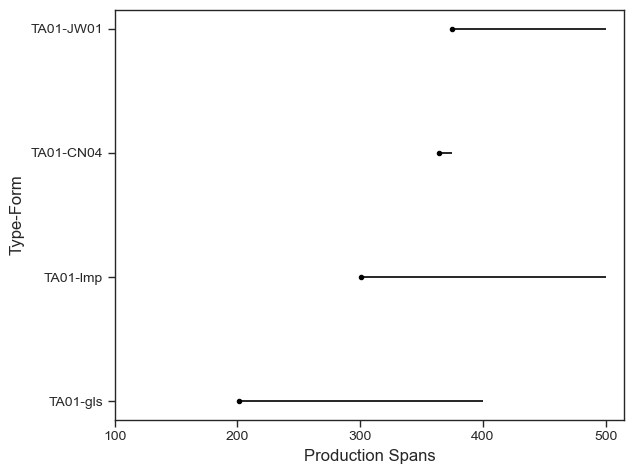

```python
KAGC_FUN.DU_MCLS_TPQ_Plt(a501, "N", "MCLS_TPQ_DUA501", ".pdf", start = 100, stop = 600)
```

```python
a501.FCounts()
```

| col_0 | index | DU | mcls | diag | date3 | date4 | Dspan | MPDate | EAAD | idn | freq | Seq |
| --- | --- | --- | --- | --- | --- | --- | --- | --- | --- | --- | --- | --- |
| 0 | 0 | A501 | gls | beaker | 201.0 | 400.0 | 199.0 | 300.5 | 174.0 | gls-beaker-201.0-400.0 | 1 | 1 |
| 1 | 1 | A501 | gls | dish or bowl | 201.0 | 400.0 | 199.0 | 300.5 | 174.0 | gls-dish or bowl-201.0-400.0 | 4 | 2 |
| 2 | 2 | A501 | jwl | earring | 301.0 | 500.0 | 199.0 | 400.5 | 74.0 | jwl-earring-301.0-500.0 | 1 | 3 |
| 3 | 3 | A501 | jwl | ring | 301.0 | 500.0 | 199.0 | 400.5 | 74.0 | jwl-ring-301.0-500.0 | 1 | 4 |
| 4 | 4 | A501 | jwl | ring | 375.0 | 500.0 | 125.0 | 437.5 | 0.0 | jwl-ring-375.0-500.0 | 1 | 5 |
| 5 | 5 | A501 | lmp | Vessberg 13/14? | 1.0 | 200.0 | 199.0 | 100.5 | 374.0 | lmp-Vessberg 13/14?-1.0-200.0 | 1 | 6 |
| 6 | 6 | A501 | lmp | Vessberg 18b | 301.0 | 500.0 | 199.0 | 400.5 | 74.0 | lmp-Vessberg 18b-301.0-500.0 | 2 | 7 |
| 7 | 10 | A501 | num | coin | 301.0 | 400.0 | 99.0 | 350.5 | 74.0 | num-coin-301.0-400.0 | 1 | 8 |
| 8 | 11 | A501 | num | coin | 301.0 | 500.0 | 199.0 | 400.5 | 74.0 | num-coin-301.0-500.0 | 4 | 9 |
| 9 | 7 | A501 | num | Constantius II | 351.0 | 355.0 | 4.0 | 353.0 | 24.0 | num-Constantius II-351.0-355.0 | 1 | 10 |
| 10 | 8 | A501 | num | Constantius II – Julian Augusti | 355.0 | 363.0 | 8.0 | 359.0 | 20.0 | num-Constantius II – Julian Augusti-355.0-363.0 | 1 | 11 |
| 11 | 9 | A501 | num | Valens | 364.0 | 375.0 | 11.0 | 369.5 | 11.0 | num-Valens-364.0-375.0 | 1 | 12 |

```python
a501.FCounts().MPDate.mean()
```

```
347.75
```

```python
#a501.FCounts().to_excel("A501_FCounts.xlsx")
```

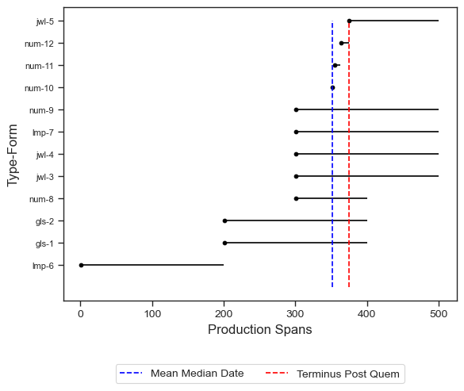

```python
KAGC_FUN.FC_DatePlt(a501, save_plot="N", out_ti="Fig_9_14_A501_Full_Spans", fext=".pdf", start=-100, stop=600, Vlines="Y")
```

#### Meadian Dates

```python
a501.FCounts().MPDate.mean()
```

```
347.75
```

```python
KAGC_FUN.MMDate(a501)
```

|  | mcls | MPDate |
| --- | --- | --- |
| 0 | gls | 300.500000 |
| 1 | jwl | 412.833333 |
| 2 | lmp | 300.500000 |
| 3 | num | 379.250000 |

```python
a501.UniqueForms()
```

```
mcls
gls                                             [beaker, dish or bowl]
jwl                                          [ring, hairring, earring]
lmp                                    [Vessberg 13/14?, Vessberg 18b]
num    [coin, Constantius II – Julian Augusti, Constantius II, Valens]
Name: diag, dtype: object
```

```python
z = a501.UniqueForms();
type(z)
```

```
pandas.core.series.Series
```

```python
a501.ResidualForms()
```

|  | index | area | name | tb.tr | cxn | mcls | number | diag | Cat | date1 | date2 | date3 | date4 | type1 | type2 | type3 | type4 | type5 | type6 | cond | burnt | join | PL | PW | date5 | description | DU | MPDate | Dspan | … |
| --- | --- | --- | --- | --- | --- | --- | --- | --- | --- | --- | --- | --- | --- | --- | --- | --- | --- | --- | --- | --- | --- | --- | --- | --- | --- | --- | --- | --- | --- | --- |

### Marker Groups

```python
a501.MKG2()
```

| type1 cxn | coin | earring | hairring | ring | All |
| --- | --- | --- | --- | --- | --- |
| TA01-0 | 8 | 1 | 1 | 2 | 12 |
| All | 8 | 1 | 1 | 2 | 12 |

```python
a501.MKG3()
```

| type1 cxn | beaker | dish or bowl | lamp | All |
| --- | --- | --- | --- | --- |
| TA01-0 | 1 | 4 | 3 | 8 |
| All | 1 | 4 | 3 | 8 |

### Faunal

```python
a501f =co.Faunal(art_db, KAGC_DUS.A501, 'A501')
```

```python
a501f.faun()
```

|  | index | name | tr_tb | area | level | species | bone | cond | burnt | butchered | worked | freq | Comment | cxn | DU |
| --- | --- | --- | --- | --- | --- | --- | --- | --- | --- | --- | --- | --- | --- | --- | --- |
| 799 | NaN | TA01 | T | A | 0 | equus caballus | radius/ulna | f | n | n | n | 1.0 | DU A501 | TA01-0 | A501 |

```python
a501sh = co.Shell(art_db, KAGC_DUS.A501, 'A501')
```

```python
#a501sh.FxTB()
```

## DU A801

DU A801 corresponds to TrA02’s Context 003. Its sediment consisted of loose, light grayish-brown sandy silt with abundant irregular limestone spall and clast fragment inclusions. It filled the faceted slot and platform that contained Tomb TA01, totally overlaying the tomb, and abutted against the faceted slot’s faces. DU A801’s interface with TA01 and the surrounding bedrock was sharply defined. DU A801 is very similar to DUs A017 and A501’s sediment.

```python
KAGC_DUS.A801
```

```
['TRA02-0.7', 'TRA07-3']
```

```python
np.mean([.02, .25, .69, .52, .53, .60])
```

```
0.435
```

```python
a801 = co.Context(KAGC_FUN.DU_Select(df, KAGC_DUS.A801, 'A801'), -24)
```

```python
a801.cdu
```

|  | index | area | name | tb.tr | cxn | mcls | number | diag | Cat | date1 | date2 | date3 | date4 | type1 | type2 | type3 | type4 | type5 | type6 | cond | burnt | join | PL | PW | date5 | description | DU | MPDate |
| --- | --- | --- | --- | --- | --- | --- | --- | --- | --- | --- | --- | --- | --- | --- | --- | --- | --- | --- | --- | --- | --- | --- | --- | --- | --- | --- | --- | --- |
| 5 | 5.0 | A | TRA02 | TR | TRA02-0.7 | jwl | 1698 | bead | None | UnID | UnID nan-nan | NaN | NaN | bead | None | p.adornment | None | None | glass | None | None | None | None | None | None | None | A801 | NaN |
| 2575 | 438.0 | A | TRA02 | TR | TRA02-0.7 | gls | G17.168 | chunk | G17.168 | None | None | NaN | NaN | chunk | None | production | None | pale blue-green | None | None | None | None | None | None | None | 1 B; small pyramidal chunk | A801 | NaN |
| 2584 | 447.0 | A | TRA02 | TR | TRA02-0.7 | gls | G17.170 | windowpane | GL871 | AD | AD 201-400 | 201.0 | 400.0 | windowpane | body | architectural | cylindrical blown | pale yellow-green | None | None | None | None | None | None | None | 1 B | A801 | 300.5 |
| 2585 | 448.0 | A | TRA02 | TR | TRA02-0.7 | gls | G17.169 | windowpane | GL870 | AD | AD 201-400 | 201.0 | 400.0 | windowpane | rim | architectural | cylindrical blown | pale blue-green | None | None | None | None | None | None | None | 1 R; with pointed rim and rounded edge | A801 | 300.5 |
| 2596 | 459.0 | A | TRA02 | TR | TRA02-0.7 | gls | 1694 | jug or bottle | None | None | None | NaN | NaN | jug or bottle | handle | storage-processing | applied | blue-green | None | None | None | None | 4 | 4 | None | 1 H; narrow vertical handle with wide base resting on the shoulder | A801 | NaN |
| 2597 | 460.0 | A | TRA02 | TR | TRA02-0.7 | gls | 1693 | jar | None | None | None | NaN | NaN | jar | base | storage-processing | free-blown | decolourised | None | None | None | None | 6 | 1 | None | 1 Bs; very large elongated tubular folded vertical footring | A801 | NaN |

```python
a801.DUCatNos()
```

|  | cxn | mcls | diag | Cat | type1 | date3 | date4 |
| --- | --- | --- | --- | --- | --- | --- | --- |
| 2575 | TRA02-0.7 | gls | chunk | G17.168 | chunk | NaN | NaN |
| 2585 | TRA02-0.7 | gls | windowpane | GL870 | windowpane | 201.0 | 400.0 |
| 2584 | TRA02-0.7 | gls | windowpane | GL871 | windowpane | 201.0 | 400.0 |

```python
a801.CC_TPQS()
```

|  | DU | name | cxn | mcls | Cat | number | diag | type1 | date3 | date4 | Dspan | MPDate |
| --- | --- | --- | --- | --- | --- | --- | --- | --- | --- | --- | --- | --- |
| 2584 | A801 | TRA02 | TRA02-0.7 | gls | GL871 | G17.170 | windowpane | windowpane | 201.0 | 400.0 | 199.0 | 300.5 |

```python
a801.FCounts()
```

| col_0 | index | DU | mcls | diag | date3 | date4 | Dspan | MPDate | EAAD | idn | freq | Seq |
| --- | --- | --- | --- | --- | --- | --- | --- | --- | --- | --- | --- | --- |
| 0 | 0 | A801 | gls | windowpane | 201.0 | 400.0 | 199.0 | 300.5 | 0.0 | gls-windowpane-201.0-400.0 | 2 | 1 |

```python
a801.DUSmry()
```

|  | DU | TPQ | MMDate | Span | TForms | RForms | NRForms | NRF:RF | Dspan > 100 | Arch | Display | P.items | P.adorn | Tool | Production |
| --- | --- | --- | --- | --- | --- | --- | --- | --- | --- | --- | --- | --- | --- | --- | --- |
| 0 | A801 | 201.0 | 300 | 199.0 | 1 | 0 | 1 | inf | 1 | True | False | False | True | False | True |

## DU A014

DU A014 consists of three Contributing Contexts (CC): Trench TrA02’s Context 001, Trench TrA07’s Context 001, and Trench TrA08’s Context 001. DU A014’s sediment consisted of a grayish-brown to light-brown silty sand with graded compaction. The sediment contained numerous comparatively small angular limestone inclusions and numerous rootlets but few artifacts. DU A014 completely overlaid DU A015 in Trenches TrA07 and TrA08. However, in Trench TrA02’s eastern sector, DU A014 was exceptionally shallow (< 0.10 m) and it overlaid worked bedrock, an incomplete cist tomb (FA10), and DU A015. DU A014 also abutted against the bedrock spur wall. The interface between DU A014 and the spur wall and underlying bedrock, including FA10, was sharply defined; the interface between DUs A014 and A015 was clearly defined (transitional zone: 2.5–6.0 cm).

```python
a014 = co.Context(KAGC_FUN.DU_Select(df, KAGC_DUS.A014, 'A014'), -24)
```

```python
a014.DUCatNos()[a014.DUCatNos().mcls == "stn"]
```

|  | cxn | mcls | diag | Cat | type1 | date3 | date4 |
| --- | --- | --- | --- | --- | --- | --- | --- |
| 3599 | TRA07-0 | stn | None | ST12 | mortarium | NaN | NaN |
| 3700 | TRA07-0 | stn | None | ST43 | mosaic | NaN | NaN |

```python
a014.MCLS_TPQS()
```

|  | DU | name | cxn | mcls | Cat | diag | type1 | type2 | date1 | date3 | date4 | Dspan | MPDate | EAAD | EAAD-M |
| --- | --- | --- | --- | --- | --- | --- | --- | --- | --- | --- | --- | --- | --- | --- | --- |
| 2079 | A014 | TRA02 | TRA02-0 | amp | SA01 | Rhodian stamped handle | stamped-eponym | H/STAMP | BC | -200.0 | -100.0 | 100.0 | -150.0 | 701.0 | 750.5 |
| 3075 | A014 | TRA07 | TRA07-0 | fw | FW186 | african red slip form 50a | Bowl | rim | AD | 230.0 | 360.0 | 130.0 | 295.0 | 271.0 | 305.5 |
| 1536 | A014 | TRA07 | TRA07-0 | lmp | None | Vessberg 18 | lamp | handle | AD | 301.0 | 500.0 | 199.0 | 400.5 | 200.0 | 200.0 |
| 2433 | A014 | TRA07 | TRA07-0 | gls | None | lamp | lamp | body | AD | 501.0 | 700.0 | 199.0 | 600.5 | 0.0 | 0.0 |

```python
a014.MCLS_Grps().get_group('gls')
```

|  | index | area | name | tb.tr | cxn | mcls | number | diag | Cat | date1 | date2 | date3 | date4 | type1 | type2 | type3 | type4 | type5 | type6 | cond | burnt | join | PL | PW | date5 | description | DU | MPDate | idn |
| --- | --- | --- | --- | --- | --- | --- | --- | --- | --- | --- | --- | --- | --- | --- | --- | --- | --- | --- | --- | --- | --- | --- | --- | --- | --- | --- | --- | --- | --- |
| 2177 | 40.0 | A | TRA02 | TR | TRA02-0.2 | gls | G17.175 | undiagnostic | None | None | None | NaN | NaN | undiagnostic | body | vessel | undiagnostic | decolourised | None | None | None | None | None | None | None | 1 B | A014 | NaN | gls-undiagnostic-nan-nan |
| 2323 | 186.0 | A | TRA07 | TR | TRA07-0 | gls | G17.150 | undiagnostic | None | None | None | NaN | NaN | undiagnostic | body | vessel | free-blown | decolourised | None | strongly weathered | None | None | None | None | None | 2 B; strongly weathered | A014 | NaN | gls-undiagnostic-nan-nan |
| 2432 | 295.0 | A | TRA07 | TR | TRA07-0 | gls | GL-15 | raw glass ? | GL-15 | None | None | NaN | NaN | raw glass ? | chunk | production | chopped | None | None | None | None | None | None | None | None | 2 joining pieces of glassy material (possibly of metalworking) | A014 | NaN | gls-raw glass ?-nan-nan |
| 2433 | 296.0 | A | TRA07 | TR | TRA07-0 | gls | 2605 GL-16 | lamp | None | AD | AD 501-700 | 501.0 | 700.0 | lamp | body | illumination | free-blown | amber-yellow | None | None | None | None | None | None | None | 1 B; flat lower part of body towards a funnel-shaped start of the hollow stem | A014 | 600.5 | gls-lamp-501.0-700.0 |
| 2598 | 461.0 | A | TRA02 | TR | TRA02-0.2 | gls | 2248 | lamp | None | AD | AD 501-700 | 501.0 | 700.0 | lamp | body | illumination | free-blown | decolourised | None | None | None | None | None | None | None | 1 B; funnel-shaped lower part of the body towards the hollow stem | A014 | 600.5 | gls-lamp-501.0-700.0 |
| 2682 | 545.0 | A | TRA07 | TR | TRA07-0 | gls | 2707 GL-21c | jar | None | AD | AD 51-300 | 51.0 | 300.0 | jar | body/base | storage-processing | free-blown | blue-green | None | None | None | None | None | None | None | 3 B; joining; large conical pushed-in base without footstand with small negative pontil mark | A014 | 175.5 | gls-jar-51.0-300.0 |
| 3017 | 880.0 | A | TRA07 | TR | TRA07-0 | gls | 2602 GL-13 | bowl | None | AD | AD 1-100 | 1.0 | 100.0 | bowl | rim/body | vessel | cast | blue | None | None | None | None | None | None | None | 1 R; thin-walled; hemispherical body; vertical rim with rounded edge; grinded | A014 | 50.5 | gls-bowl-1.0-100.0 |
| 3020 | 883.0 | A | TRA07 | TR | TRA07-0 | gls | 2603 GL-13 | undiagnostic | None | None | None | NaN | NaN | undiagnostic | rim | vessel | free-blown | decolourised | None | None | None | None | None | None | None | 1 R; thin-walled; vertical rim with thicker rounded edge | A014 | NaN | gls-undiagnostic-nan-nan |
| 3021 | 884.0 | A | TRA07 | TR | TRA07-0 | gls | 2604 GL-14 | undiagnostic | None | None | None | NaN | NaN | undiagnostic | undiagnostic | vessel | undiagnostic | decolourised | None | None | None | None | None | None | None | 1 very small fragment | A014 | NaN | gls-undiagnostic-nan-nan |

```python
a014.DUSmry()
```

|  | DU | TPQ | MMDate | Span | TForms | RForms | NRForms | NRF:RF | Dspan > 100 | Arch | Display | P.items | P.adorn | Tool | Production |
| --- | --- | --- | --- | --- | --- | --- | --- | --- | --- | --- | --- | --- | --- | --- | --- |
| 0 | A014 | 501.0 | 1 | 1200.0 | 22 | 9 | 13 | 1.44 | 14 | True | True | False | False | False | True |

```python
a014f = co.Faunal(art_db, KAGC_DUS.A014, "A014")
```

```python
a014f.faun()
```

|  | index | name | tr_tb | area | level | species | bone | cond | burnt | butchered | worked | freq | Comment | cxn | DU |
| --- | --- | --- | --- | --- | --- | --- | --- | --- | --- | --- | --- | --- | --- | --- | --- |
| 366 | 366.0 | TRA02 | TR | A | 0.1 | bird | tibiotarsus | i | n | n | n | 1.0 | None | TRA02-0.1 | A014 |
| 593 | 593.0 | TRA07 | TR | A | 0 | bos | pelvis/ischium | f | n | n | n | 1.0 | None | TRA07-0 | A014 |
| 595 | 595.0 | TRA08 | TR | A | 0 | ovis-capra | calcaneus | f | n | n | n | 1.0 | None | TRA08-0 | A014 |
| 596 | 596.0 | TRA08 | TR | A | 0 | ovis-capra | vertebra | f | n | n | n | 2.0 | None | TRA08-0 | A014 |
| 597 | 597.0 | TRA08 | TR | A | 0 | ovis-capra | rib | f | n | n | n | 1.0 | None | TRA08-0 | A014 |

## DU A015

DU A015 consists of three Contributing Contexts (CC): Trench TrA02’s Context 002, Trench TrA07’s Context 002, and Trench TrA08’s Context 002. DU A015’s sediment consisted of pale brown sandy silt with graded compaction. The excavators noted that the sediment gradually transitioned horizontally into a dark brown sandy silt with graded compaction in Trenches TrA07 and TrA08. They also noted a substantial increase in fist-sized rubble inclusions and artifact frequencies in TrA07 and TrA08 but not in TrA02. DU A015 overlaid worked bedrock in Trench TrA02 and DU A017 in TrA07 and TrA08. DU A015 also abutted against the bedrock spur wall. DU A015’s interface with the underlying bedrock and the spur wall was sharply defined; its interface with DU A017 was clearly defined (transitional zone: 2.5–6.0 cm).

```python
a015 = co.Context(KAGC_FUN.DU_Select(df, KAGC_DUS.A015, 'A015'), -24)
```

```python
a015.DUCatNos()
```

|  | cxn | mcls | diag | Cat | type1 | date3 | date4 |
| --- | --- | --- | --- | --- | --- | --- | --- |
| 2088 | TRA02-1.1 | amp | Koan stamped handle | SA10 | stamped | -200.0 | -101.0 |
| 3112 | TRA08-1 | fw | classical-hellenistic black glaze | FW019 | Bowl | -500.0 | -201.0 |
| 3447 | TRA08-1 | fw | hellenistic color coated | FW072 | Shallow Bowl | -300.0 | -101.0 |
| 3491 | TRA08-1 | fw | hellenistic fine ware | FW091 | Bowl | -300.0 | -1.0 |
| 3511 | TRA08-1 | fw | hellenistic-early roman fine ware | FW104 | Bowl | -200.0 | 100.0 |
| 1542 | TRA07-1 | lmp | saucer lamp | LP01 | lamp | -325.0 | -275.0 |
| 1704 | TRA02-1.2 | num | Arcadius or Honorius | CN22 | coin | 395.0 | 401.0 |
| 3598 | TRA07-1 | stn | None | ST11 | mortarium | NaN | NaN |
| 3712 | TRA07-1 | stn |  | ST23 | statuary | NaN | NaN |
| 3555 | TRA02-1.6 | stn | None | ST30 | revetment | NaN | NaN |
| 3655 | TRA07-1 | stn | None | ST36 | mosaic | NaN | NaN |
| 3659 | TRA07-1 | stn | None | ST37 | mosaic | NaN | NaN |
| 3638 | TRA02-1.1 | stn | None | ST38 | mosaic | NaN | NaN |
| 3639 | TRA02-1.1 | stn | None | ST39 | mosaic | NaN | NaN |
| 3675 | TRA07-1 | stn | None | ST40 | mosaic | NaN | NaN |
| 3682 | TRA07-1 | stn | None | ST41 | mosaic | NaN | NaN |
| 3686 | TRA07-1 | stn | None | ST42 | mosaic | NaN | NaN |
| 93 | TRA02-1.1 | trc | figurine | TC08 | figurine | -750.0 | -100.0 |
| 90 | TRA02-1.1 | trc | figurine | TC09 | figurine | -125.0 | -101.0 |
| 109 | TRA07-1 | trc | figurine | TC14 | figurine | -312.0 | -100.0 |

```python
a015.CC_TPQS()
```

|  | DU | name | cxn | mcls | Cat | number | diag | type1 | date3 | date4 | Dspan | MPDate |
| --- | --- | --- | --- | --- | --- | --- | --- | --- | --- | --- | --- | --- |
| 2338 | A015 | TRA08 | TRA08-1 | gls | None | 2708 GL-22 | dish or bowl | dish or bowl | 51.0 | 300.0 | 249.0 | 175.5 |
| 2607 | A015 | TRA02 | TRA02-1.6 | gls | None | 2218 | bottle | bottle | 201.0 | 400.0 | 199.0 | 300.5 |
| 1221 | A015 | TRA02 | TRA02-1.3 | lmp | None | 1.3.121 | Vessberg 18b | lamp | 301.0 | 500.0 | 199.0 | 400.5 |
| 3050 | A015 | TRA07 | TRA07-1 | amp | None | None | LRA 1 | LRA 1 | 325.0 | 435.0 | 110.0 | 380.0 |
| 1704 | A015 | TRA02 | TRA02-1.2 | num | CN22 | 1542 | Arcadius or Honorius | coin | 395.0 | 401.0 | 6.0 | 398.0 |
| 2104 | A015 | TRA02 | TRA02-1.1 | amp | None | TR_A_II_1.1_1022 | LRA 1 | LRA 1 | 400.0 | 499.0 | 99.0 | 449.5 |

```python
a015.MCLS_TPQS()
```

|  | DU | name | cxn | mcls | Cat | diag | type1 | type2 | date1 | date3 | date4 | Dspan | MPDate | EAAD | EAAD-M |
| --- | --- | --- | --- | --- | --- | --- | --- | --- | --- | --- | --- | --- | --- | --- | --- |
| 3511 | A015 | TRA08 | TRA08-1 | fw | FW104 | hellenistic-early roman fine ware | Bowl | base | BC-AD | -200.0 | 100.0 | 300.0 | -50.0 | 600.0 | 499.5 |
| 90 | A015 | TRA02 | TRA02-1.1 | trc | TC09 | figurine | figurine | horse torso | BC | -125.0 | -101.0 | 24.0 | -113.0 | 525.0 | 562.5 |
| 2426 | A015 | TRA07 | TRA07-1 | gls | None | jar or bowl | jar or bowl | rim/handle | AD | 201.0 | 400.0 | 199.0 | 300.5 | 199.0 | 149.0 |
| 1209 | A015 | TRA02 | TRA02-1.2 | lmp | None | Vessberg 18b | lamp | upper part | AD | 301.0 | 500.0 | 199.0 | 400.5 | 99.0 | 49.0 |
| 1704 | A015 | TRA02 | TRA02-1.2 | num | CN22 | Arcadius or Honorius | coin | intact | AD | 395.0 | 401.0 | 6.0 | 398.0 | 5.0 | 51.5 |
| 2104 | A015 | TRA02 | TRA02-1.1 | amp | None | LRA 1 | LRA 1 | R | AD | 400.0 | 499.0 | 99.0 | 449.5 | 0.0 | 0.0 |

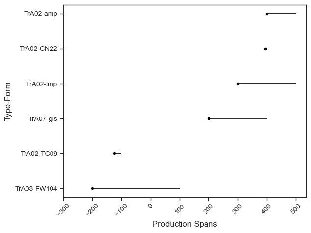

```python
KAGC_FUN.DU_MCLS_TPQ_Plt(a015, "N", "F9_17_A015_MCLS_TPQ", ".pdf", start = -300, stop = 600)
```

```python
a015.FCounts()
```

| col_0 | index | DU | mcls | diag | date3 | date4 | Dspan | MPDate | EAAD | idn | freq | Seq |
| --- | --- | --- | --- | --- | --- | --- | --- | --- | --- | --- | --- | --- |
| 0 | 1 | A015 | amp | BH | -325.0 | -275.0 | 50.0 | -300.0 | 725.0 | amp-BH--325.0--275.0 | 1 | 1 |
| 1 | 2 | A015 | amp | BH-AM | -325.0 | -275.0 | 50.0 | -300.0 | 725.0 | amp-BH-AM--325.0--275.0 | 1 | 2 |
| 2 | 8 | A015 | amp | Kouriote | -325.0 | -275.0 | 50.0 | -300.0 | 725.0 | amp-Kouriote--325.0--275.0 | 3 | 3 |
| 3 | 9 | A015 | amp | Kouriote | -325.0 | -250.0 | 75.0 | -287.5 | 725.0 | amp-Kouriote--325.0--250.0 | 2 | 4 |
| 4 | 11 | A015 | amp | Kouriote? | -325.0 | -275.0 | 50.0 | -300.0 | 725.0 | amp-Kouriote?--325.0--275.0 | 2 | 5 |
| 5 | 27 | A015 | amp | UnID | -325.0 | -275.0 | 50.0 | -300.0 | 725.0 | amp-UnID--325.0--275.0 | 2 | 6 |
| 6 | 7 | A015 | amp | Kos? | -299.0 | -30.0 | 269.0 | -164.5 | 699.0 | amp-Kos?--299.0--30.0 | 1 | 7 |
| 7 | 10 | A015 | amp | Kouriote | -299.0 | -100.0 | 199.0 | -199.5 | 699.0 | amp-Kouriote--299.0--100.0 | 1 | 8 |
| 8 | 22 | A015 | amp | Rodos | -299.0 | -30.0 | 269.0 | -164.5 | 699.0 | amp-Rodos--299.0--30.0 | 1 | 9 |
| 9 | 24 | A015 | amp | TR-DBH | -299.0 | -100.0 | 199.0 | -199.5 | 699.0 | amp-TR-DBH--299.0--100.0 | 1 | 10 |
| 10 | 25 | A015 | amp | TR-DBH | -299.0 | -30.0 | 269.0 | -164.5 | 699.0 | amp-TR-DBH--299.0--30.0 | 2 | 11 |
| 11 | 28 | A015 | amp | UnID | -299.0 | -30.0 | 269.0 | -164.5 | 699.0 | amp-UnID--299.0--30.0 | 1 | 12 |
| 12 | 6 | A015 | amp | Koan stamped handle | -200.0 | -101.0 | 99.0 | -150.5 | 600.0 | amp-Koan stamped handle--200.0--101.0 | 1 | 13 |
| 13 | 23 | A015 | amp | Rodos type | -199.0 | -100.0 | 99.0 | -149.5 | 599.0 | amp-Rodos type--199.0--100.0 | 1 | 14 |
| 14 | 29 | A015 | amp | UnID | -199.0 | 150.0 | 349.0 | -24.5 | 599.0 | amp-UnID--199.0-150.0 | 1 | 15 |
| 15 | 4 | A015 | amp | Chios? | -150.0 | 30.0 | 180.0 | -60.0 | 550.0 | amp-Chios?--150.0-30.0 | 1 | 16 |
| 16 | 18 | A015 | amp | Pseudo-Kos | -99.0 | 175.0 | 274.0 | 38.0 | 499.0 | amp-Pseudo-Kos--99.0-175.0 | 5 | 17 |
| 17 | 19 | A015 | amp | Pseudo-Kos | -75.0 | 199.0 | 274.0 | 62.0 | 475.0 | amp-Pseudo-Kos--75.0-199.0 | 1 | 18 |
| 18 | 26 | A015 | amp | TR-DBH | -75.0 | 175.0 | 250.0 | 50.0 | 475.0 | amp-TR-DBH--75.0-175.0 | 2 | 19 |
| 19 | 5 | A015 | amp | ER type | -30.0 | 150.0 | 180.0 | 60.0 | 430.0 | amp-ER type--30.0-150.0 | 3 | 20 |
| 20 | 20 | A015 | amp | Pseudo-Kos | -30.0 | 175.0 | 205.0 | 72.5 | 430.0 | amp-Pseudo-Kos--30.0-175.0 | 3 | 21 |
| 21 | 21 | A015 | amp | Pseudo-Kos? | -30.0 | 150.0 | 180.0 | 60.0 | 430.0 | amp-Pseudo-Kos?--30.0-150.0 | 1 | 22 |
| 22 | 30 | A015 | amp | UnID | -30.0 | 150.0 | 180.0 | 60.0 | 430.0 | amp-UnID--30.0-150.0 | 6 | 23 |
| 23 | 31 | A015 | amp | UnID | -30.0 | 175.0 | 205.0 | 72.5 | 430.0 | amp-UnID--30.0-175.0 | 1 | 24 |
| 24 | 17 | A015 | amp | Pompei 5 | 50.0 | 125.0 | 75.0 | 87.5 | 350.0 | amp-Pompei 5-50.0-125.0 | 1 | 25 |
| 25 | 16 | A015 | amp | PSEUDO-KOS-EN-CLOCHE | 75.0 | 175.0 | 100.0 | 125.0 | 325.0 | amp-PSEUDO-KOS-EN-CLOCHE-75.0-175.0 | 1 | 26 |
| 26 | 3 | A015 | amp | Beirut type | 200.0 | 299.0 | 99.0 | 249.5 | 200.0 | amp-Beirut type-200.0-299.0 | 1 | 27 |
| 27 | 12 | A015 | amp | Kouriote? | 200.0 | 399.0 | 199.0 | 299.5 | 200.0 | amp-Kouriote?-200.0-399.0 | 1 | 28 |
| 28 | 0 | A015 | amp | Almagro 50? | 300.0 | 499.0 | 199.0 | 399.5 | 100.0 | amp-Almagro 50?-300.0-499.0 | 1 | 29 |
| 29 | 15 | A015 | amp | LRA 4 | 300.0 | 499.0 | 199.0 | 399.5 | 100.0 | amp-LRA 4-300.0-499.0 | 1 | 30 |
| 30 | 13 | A015 | amp | LRA 1 | 325.0 | 435.0 | 110.0 | 380.0 | 75.0 | amp-LRA 1-325.0-435.0 | 1 | 31 |
| 31 | 14 | A015 | amp | LRA 1 | 400.0 | 499.0 | 99.0 | 449.5 | 0.0 | amp-LRA 1-400.0-499.0 | 1 | 32 |
| 32 | 32 | A015 | fw | classical-hellenistic black glaze | -500.0 | -201.0 | 299.0 | -350.5 | 900.0 | fw-classical-hellenistic black glaze--500.0--201.0 | 1 | 33 |
| 33 | 33 | A015 | fw | hellenistic color coated | -300.0 | -101.0 | 199.0 | -200.5 | 700.0 | fw-hellenistic color coated--300.0--101.0 | 4 | 34 |
| 34 | 34 | A015 | fw | hellenistic fine ware | -300.0 | -1.0 | 299.0 | -150.5 | 700.0 | fw-hellenistic fine ware--300.0--1.0 | 1 | 35 |
| 35 | 35 | A015 | fw | hellenistic-early roman fine ware | -200.0 | 100.0 | 300.0 | -50.0 | 600.0 | fw-hellenistic-early roman fine ware--200.0-100.0 | 1 | 36 |
| 36 | 41 | A015 | gls | undiagnostic | -200.0 | 100.0 | 300.0 | -50.0 | 600.0 | gls-undiagnostic--200.0-100.0 | 1 | 37 |
| 37 | 38 | A015 | gls | dish or bowl | 51.0 | 300.0 | 249.0 | 175.5 | 349.0 | gls-dish or bowl-51.0-300.0 | 1 | 38 |
| 38 | 42 | A015 | gls | undiagnostic | 51.0 | 400.0 | 349.0 | 225.5 | 349.0 | gls-undiagnostic-51.0-400.0 | 1 | 39 |
| 39 | 37 | A015 | gls | cup or shallow bowl | 101.0 | 300.0 | 199.0 | 200.5 | 299.0 | gls-cup or shallow bowl-101.0-300.0 | 1 | 40 |
| 40 | 43 | A015 | gls | unguentarium | 101.0 | 300.0 | 199.0 | 200.5 | 299.0 | gls-unguentarium-101.0-300.0 | 1 | 41 |
| 41 | 36 | A015 | gls | bottle | 201.0 | 400.0 | 199.0 | 300.5 | 199.0 | gls-bottle-201.0-400.0 | 1 | 42 |
| 42 | 39 | A015 | gls | dish or bowl | 201.0 | 400.0 | 199.0 | 300.5 | 199.0 | gls-dish or bowl-201.0-400.0 | 1 | 43 |
| 43 | 40 | A015 | gls | jar or bowl | 201.0 | 400.0 | 199.0 | 300.5 | 199.0 | gls-jar or bowl-201.0-400.0 | 1 | 44 |
| 44 | 51 | A015 | lmp | saucer lamp | -325.0 | -275.0 | 50.0 | -300.0 | 725.0 | lmp-saucer lamp--325.0--275.0 | 1 | 45 |
| 45 | 44 | A015 | lmp | UnID | 1.0 | 200.0 | 199.0 | 100.5 | 399.0 | lmp-UnID-1.0-200.0 | 7 | 46 |
| 46 | 46 | A015 | lmp | Vessberg 10? | 1.0 | 100.0 | 99.0 | 50.5 | 399.0 | lmp-Vessberg 10?-1.0-100.0 | 2 | 47 |
| 47 | 47 | A015 | lmp | Vessberg 13 | 1.0 | 200.0 | 199.0 | 100.5 | 399.0 | lmp-Vessberg 13-1.0-200.0 | 1 | 48 |
| 48 | 48 | A015 | lmp | Vessberg 14? | 101.0 | 200.0 | 99.0 | 150.5 | 299.0 | lmp-Vessberg 14?-101.0-200.0 | 2 | 49 |
| 49 | 49 | A015 | lmp | Vessberg 16? | 201.0 | 400.0 | 199.0 | 300.5 | 199.0 | lmp-Vessberg 16?-201.0-400.0 | 2 | 50 |
| 50 | 45 | A015 | lmp | UnID | 301.0 | 500.0 | 199.0 | 400.5 | 99.0 | lmp-UnID-301.0-500.0 | 1 | 51 |
| 51 | 50 | A015 | lmp | Vessberg 18b | 301.0 | 500.0 | 199.0 | 400.5 | 99.0 | lmp-Vessberg 18b-301.0-500.0 | 12 | 52 |
| 52 | 52 | A015 | num | Arcadius or Honorius | 395.0 | 401.0 | 6.0 | 398.0 | 5.0 | num-Arcadius or Honorius-395.0-401.0 | 1 | 53 |
| 53 | 53 | A015 | trc | figurine | -750.0 | -100.0 | 650.0 | -425.0 | 1150.0 | trc-figurine--750.0--100.0 | 1 | 54 |
| 54 | 54 | A015 | trc | figurine | -312.0 | -100.0 | 212.0 | -206.0 | 712.0 | trc-figurine--312.0--100.0 | 1 | 55 |
| 55 | 55 | A015 | trc | figurine | -125.0 | -101.0 | 24.0 | -113.0 | 525.0 | trc-figurine--125.0--101.0 | 1 | 56 |

```python
a015.ResidualForms().head()
```

|  | index | area | name | tb.tr | cxn | mcls | number | diag | Cat | date1 | date2 | date3 | date4 | type1 | type2 | type3 | type4 | type5 | type6 | cond | burnt | join | PL | PW | date5 | description | DU | MPDate | Dspan | … |
| --- | --- | --- | --- | --- | --- | --- | --- | --- | --- | --- | --- | --- | --- | --- | --- | --- | --- | --- | --- | --- | --- | --- | --- | --- | --- | --- | --- | --- | --- | --- |
| 90 | 6.0 | A | TRA02 | TR | TRA02-1.1 | trc | 1583A-B | figurine | TC09 | BC | BC 175-100 | -125.0 | -101.0 | figurine | horse torso | special purpose | handmade-solid | pale red | semi-fine | frag | None | None | 6.1 | 4.2 | None | fabric: semi-fine, pale red (mansell: 10r6/4), lime, brown and black inclusions, grey core, some voids; white slip; fragmented, 2 pieces, horse torso and 3 legs are preserved; comparanda: winter 1989;… | A015 | -113.0 | 24.0 | … |
| 93 | 9.0 | A | TRA02 | TR | TRA02-1.1 | trc | 2190 | figurine | TC08 | BC | BC 750-100 | -750.0 | -100.0 | figurine | animal leg | special purpose | handmade-solid | pale red | semi-fine | frag | N | None | 3.91 | 2.17 | None | None | A015 | -425.0 | 650.0 | … |
| 109 | 25.0 | A | TRA07 | TR | TRA07-1 | trc | TrA07_A015 | figurine | TC14 | BC | BC 312-100 | -312.0 | -100.0 | figurine | body of a rider | special purpose | handmade-solid | pale red | semi-fine | frag | N | None | 5.8 | 5.3 | None | fabric: semi-fine, pale red (mansell: 10r/6/4), lime, black and brown inclusions; white slip; fragmentary torso of a human, neck, shoulders and part of legs are preserved; comparanda: Winter 1989; 199… | A015 | -206.0 | 212.0 | … |
| 1542 | 1433.0 | A | TRA07 | TR | TRA07-1 | lmp | 1.0.1705 | saucer lamp | LP01 | BC | BC -325 -275 | -325.0 | -275.0 | lamp | nozzle | illumination | None | None | coarse ware | None | Y | N | None | None | None | rim with fragm of a pinched nozzle; dim: UniD; munsell: UnID; burnt: Y; mended: UnID | A015 | -300.0 | 50.0 | … |
| 2082 | 3.0 | A | TRA02 | TR | TRA02-1.1 | amp | TR_A_II_1.1_139 | Pseudo-Kos | None | BC-AD | BC-AD -99.0 175.0 | -99.0 | 175.0 | Pseudo-Kos | HW | transport-storage | None | None | red fabric, yellow wash, rough quartz | None | None | None | None | None | LH - ER | None | A015 | 38.0 | 274.0 | … |

```python
a015.DUSmry()
```

|  | DU | TPQ | MMDate | Span | TForms | RForms | NRForms | NRF:RF | Dspan > 100 | Arch | Display | P.items | P.adorn | Tool | Production |
| --- | --- | --- | --- | --- | --- | --- | --- | --- | --- | --- | --- | --- | --- | --- | --- |
| 0 | A015 | 400.0 | 55 | 1250.0 | 56 | 33 | 23 | 0.7 | 39 | True | True | True | False | False | True |

```python
a015f = co.Faunal(art_db, KAGC_DUS.A015, "A015")
```

```python
a015f.faun()
```

|  | index | name | tr_tb | area | level | species | bone | cond | burnt | butchered | worked | freq | Comment | cxn | DU |
| --- | --- | --- | --- | --- | --- | --- | --- | --- | --- | --- | --- | --- | --- | --- | --- |
| 367 | 367.0 | TRA02 | TR | A | 1.1 | canis | premolar | i | n | n | n | 1.0 | adult | TRA02-1.1 | A015 |
| 368 | 368.0 | TRA02 | TR | A | 1.1 | canis | proximal metapodial | i | n | n | n | 1.0 | adult | TRA02-1.1 | A015 |
| 369 | 369.0 | TRA02 | TR | A | 1.6 | unid | shaft | f | n | n | n | 1.0 | None | TRA02-1.6 | A015 |
| 598 | 598.0 | TRA08 | TR | A | 1 | ovis-capra | shaft | f | y | n | n | 2.0 | None | TRA08-1 | A015 |
| 599 | 599.0 | TRA08 | TR | A | 1 | ovis-capra | rib | f | n | y | n | 1.0 | None | TRA08-1 | A015 |

```python
a015.MCLS_Grps().get_group('stn')
```

|  | index | area | name | tb.tr | cxn | mcls | number | diag | Cat | date1 | date2 | date3 | date4 | type1 | type2 | type3 | type4 | type5 | type6 | cond | burnt | join | PL | PW | date5 | description | DU | MPDate | Dspan | … |
| --- | --- | --- | --- | --- | --- | --- | --- | --- | --- | --- | --- | --- | --- | --- | --- | --- | --- | --- | --- | --- | --- | --- | --- | --- | --- | --- | --- | --- | --- | --- |
| 3552 | 25.0 | A | TRA02 | TR | TRA02-1.1 | stn | 1465 | None | None | None | None | NaN | NaN | revetment | fragment | architectural | None | gray | marble | None | N | None | 8.7 | 6.1 | None | gray proconnessian marble. two smooth, worked faces. remnants of mortar on one face. rust color pigment on the other (corrosion from metal object?) L: 8.7; W: 6.1; Th: 1.4 | A015 | NaN | NaN | … |
| 3553 | 26.0 | A | TRA02 | TR | TRA02-1.1 | stn | 1466 | None | None | None | None | NaN | NaN | revetment | fragment | architectural | None | light gray | marble | None | N | None | 6.5 | 5.5 | None | light gray proconnessian marble with dark gray veins. two smooth, worked faces. some concretion (calcite?) on one face. remnants of mortar on the other L: 6.5; W: 5.5; Th: 1.2 | A015 | NaN | NaN | … |
| 3554 | 27.0 | A | TRA02 | TR | TRA02-1.1 | stn | 1467 | None | None | None | None | NaN | NaN | revetment | fragment | architectural | None | light gray | marble | None | N | None | 6 | 4.6 | None | light gray proconnessian marble with dark gray veins. two smooth, worked faces. some concretion (calcite?) on one face. remnants of mortar on the other face. L: 6; W: 4.6; Th: 1.5 | A015 | NaN | NaN | … |
| 3555 | 28.0 | A | TRA02 | TR | TRA02-1.6 | stn | 1468 | None | ST30 | None | None | NaN | NaN | revetment | fragment | architectural | None | white | marble | None | N | None | 15.5 | 10.4 | None | white, attic marble. two smooth, worked faces. one finished edge. two "ridges" on front side. remains of mortar on edges. L: 15.5; W: 10.4; Th: 3.6 | A015 | NaN | NaN | … |
| 3558 | 31.0 | A | TRA02 | TR | TRA02-1.6 | stn | 1471 A,B | None | None | None | None | NaN | NaN | revetment | 2 fragments | architectural | None | light gray | marble | None | N | None | 15.3 | 5.7 | None | light gray proconnessian marble with dark gray veins. two smooth, worked faces. remnants of mortar on one side. L: 15.3; W: 5.7; Th: 1.8 | A015 | NaN | NaN | … |
| 3559 | 32.0 | A | TRA02 | TR | TRA02-1.6 | stn | 1472 | None | None | None | None | NaN | NaN | revetment | fragment | architectural | None | light gray | marble | None | N | None | 7.9 | 7.4 | None | light gray proconnessian marble with dark gray veins. two smooth, worked faces. remnants of mortar on one side. L: 7.9; W: 7.4; Th: 1.8 | A015 | NaN | NaN | … |
| 3560 | 33.0 | A | TRA02 | TR | TRA02-1.6 | stn | 1473 | None | None | None | None | NaN | NaN | revetment | fragment | architectural | None | light gray | marble | None | N | None | 5.3 | 5 | None | light gray proconnessian marble with dark gray veins. two smooth, worked faces. remnants of mortar on one side L: 5.3; W: 5; Th: 1 | A015 | NaN | NaN | … |
| 3598 | 71.0 | A | TRA07 | TR | TRA07-1 | stn | TC 2 | None | ST11 | None | None | NaN | NaN | mortarium | base/rim fragment | production | None | dark gray | dunite | None | N | None | 19.1 | 12 | None | hard, coarse-grained stone (dunite). dark gray in color with large particles throughout. shallow basin with slightly curved wall extending into flat, lug handle. smooth, abraded interior. exterior is … | A015 | NaN | NaN | … |
| 3634 | 107.0 | A | TRA02 | TR | TRA02-1.1 | stn | 1463 | None | None | None | None | NaN | NaN | marble "chip" | complete | reduction | None | white | marble | None | N | None | 3 | 1.5 | None | 1 white proconnessian marble chip with light blue veins. destined for lime kiln? L: 3.0; W: 1.5; Th: 0.50 | A015 | NaN | NaN | … |
| 3635 | 108.0 | A | TRA02 | TR | TRA02-1.1 | stn | 1464 | None | None | None | None | NaN | NaN | marble "chip" | complete | reduction | None | white | marble | None | N | None | 2.5 | 1 | None | 1 white proconnessian marble chip with light gray veins. destined for lime kiln? L: 2.5; W: 1; Th: 0.50 | A015 | NaN | NaN | … |
| 3638 | 111.0 | A | TRA02 | TR | TRA02-1.1 | stn | 312 | None | ST38 | None | None | NaN | NaN | mosaic | fragment | display | None | white | mosaic | None | N | None | 8 | 3 | None | 5 white, 1 black tesserae. tessera = ca. 2x2cm L: 8; W: 3; Th: 4.9 | A015 | NaN | NaN | … |
| 3639 | 112.0 | A | TRA02 | TR | TRA02-1.1 | stn | 313 | None | ST39 | None | None | NaN | NaN | mosaic | fragment | display | None | white | mosaic | None | N | None | 12.2 | 4.9 | None | 26 white, 26 blue, 21 brown, 8 cream tesserae. tessera = ca. 1x1cm L: 12.2; W: 4.9; Th: 8.9 | A015 | NaN | NaN | … |
| 3640 | 113.0 | A | TRA02 | TR | TRA02-1.1 | stn | 1525 | None | None | None | None | NaN | NaN | mosaic | fragment | display | None | white | mosaic | None | N | None | 10.5 | 3.5 | None | 18 white, 4 black tesserae. tessera = ca. 1x1cm L: 10.5; W: 3.5; Th: 6 | A015 | NaN | NaN | … |
| 3641 | 114.0 | A | TRA02 | TR | TRA02-1.1 | stn | 1526 | None | None | None | None | NaN | NaN | mosaic | fragment | display | None | black | mosaic | None | N | None | 7.3 | 7.2 | None | black, white tesserae L: 7.3; W: 7.2 | A015 | NaN | NaN | … |
| 3642 | 115.0 | A | TRA02 | TR | TRA02-1.1 | stn | 1527 | None | None | None | None | NaN | NaN | mosaic | fragment | display | None | black | mosaic | None | N | None | 6.9 | 4.4 | None | 7 black, 4 white tesserae. tessera = ca. 1x1cm L: 6.9; W: 4.4; Th: 4.7 | A015 | NaN | NaN | … |
| 3643 | 116.0 | A | TRA02 | TR | TRA02-1.1 | stn | 1528 | None | None | None | None | NaN | NaN | mosaic | fragment | display | None | black | mosaic | None | N | None | 6.7 | 4.5 | None | 9 black, 4 white tesserae. tessera = ca. 1.5x1.5cm L: 6.7; W: 4.5; Th: 5.2 | A015 | NaN | NaN | … |
| 3647 | 120.0 | A | TRA07 | TR | TRA07-1 | stn | 1647 | None | None | None | None | NaN | NaN | mosaic | fragment | display | None | white | mosaic | None | N | None | 1.8 | 1.5 | None | 4 white, 1 pink tesserae. L: 1.8; W: 1.5; Th: 2.7 | A015 | NaN | NaN | … |
| 3648 | 121.0 | A | TRA07 | TR | TRA07-1 | stn | 1648 | None | None | None | None | NaN | NaN | mosaic | fragment | display | None | white | mosaic | None | N | None | 4.2 | 3.7 | None | 2 white tesserae (each ca. 2x2cm) L: 4.2; W: 3.7; Th: 4.6 | A015 | NaN | NaN | … |
| 3649 | 122.0 | A | TRA07 | TR | TRA07-1 | stn | 1649 | None | None | None | None | NaN | NaN | mosaic | fragment | display | None | cream | mosaic | None | N | None | 3.4 | 2.4 | None | 3 cream, 3 light gray, 2 black tesserae. tessera = ca. 1x1cm. cream tesserae arranged in curving band. L: 3.4; W: 2.4; Th: 3 | A015 | NaN | NaN | … |
| 3650 | 123.0 | A | TRA07 | TR | TRA07-1 | stn | 1650 | None | None | None | None | NaN | NaN | mosaic | fragment | display | None | purple | mosaic | None | N | None | 4.2 | 3.4 | None | 3 purple and 2 white tesserae. tessera = ca. 1x2cm. L: 4.2; W: 3.4; Th: 3.6 | A015 | NaN | NaN | … |
| 3651 | 124.0 | A | TRA07 | TR | TRA07-1 | stn | 1651 | None | None | None | None | NaN | NaN | mosaic | fragment | display | None | white | mosaic | None | N | None | None | None | None | None | A015 | NaN | NaN | … |
| 3652 | 125.0 | A | TRA07 | TR | TRA07-1 | stn | 1652 | None | None | None | None | NaN | NaN | mosaic | fragment | display | None | white | mosaic | None | N | None | 5.5 | 3.3 | None | 4 white, 3 black tesserae. tessera = ca. 2x2cm L: 5.5; W: 3.3; Th: 5.4 | A015 | NaN | NaN | … |
| 3653 | 126.0 | A | TRA07 | TR | TRA07-1 | stn | 1653 | None | None | None | None | NaN | NaN | mosaic | fragment | display | None | gray | mosaic | None | N | None | 3.8 | 2.5 | None | 1 gray, 1 white tesserae. tessera = ca. 2x2cm L: 3.8; W: 2.5; Th: 4 | A015 | NaN | NaN | … |
| 3654 | 127.0 | A | TRA07 | TR | TRA07-1 | stn | 1654 | None | None | None | None | NaN | NaN | mosaic | fragment | display | None | black | mosaic | None | N | None | 9.6 | 4.4 | None | 23 black, 22 blue, 12 brown, 19 white, 13 light gray tesserae. tessera = ca. 0.50x0.50cm L: 9.6; W: 4.4; Th: 11.1 | A015 | NaN | NaN | … |
| 3655 | 128.0 | A | TRA07 | TR | TRA07-1 | stn | 1655 | None | ST36 | None | None | NaN | NaN | mosaic | fragment | display | None | white | mosaic | None | N | None | 6.2 | 4.1 | None | 42 white tesserae in 7 bands. tessera = ca. 0.50x0.50cm L: 6.2; W: 4.1; Th: 6.2 | A015 | NaN | NaN | … |
| 3656 | 129.0 | A | TRA07 | TR | TRA07-1 | stn | 1656 | None | None | None | None | NaN | NaN | mosaic | fragment | display | None | white | mosaic | None | N | None | 5.5 | 4.2 | None | 18 white tesserae in 4 bands. tessera = ca. 2x2cm L: 5.5; W: 4.2; Th: 7.8 | A015 | NaN | NaN | … |
| 3657 | 130.0 | A | TRA07 | TR | TRA07-1 | stn | 1657 | None | None | None | None | NaN | NaN | mosaic | fragment | display | None | white | mosaic | None | N | None | 3.7 | 3.5 | None | 6 white, 3 purple tesserae in 3 bands. tessera = ca. 1x1cm L: 3.7; W: 3.5; Th: 9.2 | A015 | NaN | NaN | … |
| 3658 | 131.0 | A | TRA07 | TR | TRA07-1 | stn | 1658 | None | None | None | None | NaN | NaN | mosaic | fragment | display | None | white | mosaic | None | N | None | 7.7 | 5 | None | 6 white tesserae in bands. tessera = ca. 1.5x1.5cm. L: 7.7; W: 5; Th: 8.6 | A015 | NaN | NaN | … |
| 3659 | 132.0 | A | TRA07 | TR | TRA07-1 | stn | 1659 | None | ST37 | None | None | NaN | NaN | mosaic | fragment | display | None | white | mosaic | None | N | None | 5.1 | 3.9 | None | 34 white tesserae in curving bands. tessera = ca. 0.50x0.50cm L: 5.1; W: 3.9; Th: 6.5 | A015 | NaN | NaN | … |
| 3660 | 133.0 | A | TRA07 | TR | TRA07-1 | stn | 1660 | None | None | None | None | NaN | NaN | mosaic | fragment | display | None | white | mosaic | None | N | None | 3 | 2.9 | None | 2 white tesserae in a band. tessera = ca. 2x2cm L: 3; W: 2.9; Th: 2.7 | A015 | NaN | NaN | … |
| 3661 | 134.0 | A | TRA07 | TR | TRA07-1 | stn | 1661 | None | None | None | None | NaN | NaN | mosaic | fragment | display | None | white | mosaic | None | N | None | 4 | 3.1 | None | 6 white, 4 gray tesserae in bands. tessera = ca. 1x1cm L: 4; W: 3.1; Th: 4.8 | A015 | NaN | NaN | … |
| 3662 | 135.0 | A | TRA07 | TR | TRA07-1 | stn | 1662 | None | None | None | None | NaN | NaN | mosaic | fragment | display | None | white | mosaic | None | N | None | 6.8 | 4.5 | None | 11 white, 11 black tesserae in curving bands. tessera = ca. 1x1cm L: 6.8; W: 4.5; Th: 6.6 | A015 | NaN | NaN | … |
| 3663 | 136.0 | A | TRA07 | TR | TRA07-1 | stn | 1663 | None | None | None | None | NaN | NaN | mosaic | fragment | display | None | white | mosaic | None | N | None | 4.4 | 3.2 | None | 12 white tesserae. tessera = ca. 2x2 cm L: 4.4; W: 3.2; Th: 4.5 | A015 | NaN | NaN | … |
| 3664 | 137.0 | A | TRA07 | TR | TRA07-1 | stn | 1664 | None | None | None | None | NaN | NaN | mosaic | fragment | display | None | gray | mosaic | None | N | None | 5.3 | 5 | None | 7 gray, 6 cream, 5 brown, 4 white, 3 black tesserae in 6 rows forming a semi-circular arch. tessera = ca. 2 x 1 cm L: 5.3; W: 5.0; Th: 7 | A015 | NaN | NaN | … |
| 3665 | 138.0 | A | TRA07 | TR | TRA07-1 | stn | 1665 | None | None | None | None | NaN | NaN | mosaic | fragment | display | None | white | mosaic | None | N | None | 6.1 | 4.3 | None | 20 white tesserae in bands. tessera = ca. 2x2 cm L: 6.1; W: 4.3; Th: 7.5 | A015 | NaN | NaN | … |
| 3666 | 139.0 | A | TRA07 | TR | TRA07-1 | stn | 1666 | None | None | None | None | NaN | NaN | mosaic | fragment | display | None | white | mosaic | None | N | None | 5.2 | 4.9 | None | 7 white and 5 black tesserae in bands. white tessera = ca 2x2cm. black tessera = ca. 1x1cm L: 5.2; W: 4.9; Th: 6.7 | A015 | NaN | NaN | … |
| 3667 | 140.0 | A | TRA07 | TR | TRA07-1 | stn | 1667 | None | None | None | None | NaN | NaN | mosaic | fragment | display | None | black | mosaic | None | N | None | 3 | 2.5 | None | 3 black and 1 white tesserae in two bands. tessera = ca. 2x2 cm L: 3; W: 2.5; Th: 3.5 | A015 | NaN | NaN | … |
| 3668 | 141.0 | A | TRA07 | TR | TRA07-1 | stn | 1668 | None | None | None | None | NaN | NaN | mosaic | fragment | display | None | white | mosaic | None | N | None | 2.9 | 2.6 | None | 4 white tesserae in bands. tessera = ca: 2x2cm L: 2.9; W: 2.6; Th: 4 | A015 | NaN | NaN | … |
| 3669 | 142.0 | A | TRA07 | TR | TRA07-1 | stn | 1669 | None | None | None | None | NaN | NaN | mosaic | fragment | display | None | white | mosaic | None | N | None | 5.9 | 4.4 | None | 19 white tesserae and 2 black tesserae in bands. tessera = ca. 2x2cm L: 5.9; W: 4.4; Th: 6.7 | A015 | NaN | NaN | … |
| 3670 | 143.0 | A | TRA07 | TR | TRA07-1 | stn | 1670 | None | None | None | None | NaN | NaN | mosaic | fragment | display | None | white | mosaic | None | N | None | 5.8 | 4.2 | None | 6 white and 4 black tesserae in bands. tessera = ca. 2x2cm L: 5.8; W: 4.2; Th: 6.6 | A015 | NaN | NaN | … |
| 3671 | 144.0 | A | TRA07 | TR | TRA07-1 | stn | 1671 | None | None | None | None | NaN | NaN | mosaic | fragment | display | None | white | mosaic | None | N | None | 5.6 | 5.1 | None | 13 white, 11 black, 11 gray, 8 blue, 5 red tesserae in curving band. white and black tesserae = ca. 2x2cm. all others 1x1 cm L: 5.6; W: 5.1m; Th: 10.1 | A015 | NaN | NaN | … |
| 3672 | 145.0 | A | TRA07 | TR | TRA07-1 | stn | 1672 | None | None | None | None | NaN | NaN | mosaic | fragment | display | None | white | mosaic | None | N | None | None | None | None | None | A015 | NaN | NaN | … |
| 3673 | 146.0 | A | TRA07 | TR | TRA07-1 | stn | 1673 | None | None | None | None | NaN | NaN | mosaic | fragment | display | None | black | mosaic | None | N | None | 4.5 | 3.6 | None | 6 black and 4 white tesserae in bands. tessera = ca. 2x2cm L: 4.5; W: 3.6; Th: 5.6 | A015 | NaN | NaN | … |
| 3674 | 147.0 | A | TRA07 | TR | TRA07-1 | stn | 1674 | None | None | None | None | NaN | NaN | mosaic | fragment | display | None | black | mosaic | None | N | None | 3 | 2.5 | None | 5 black tesserae in bands. tessera = ca. 2x2cm L: 3; W: 2.5; Th: 3.6 | A015 | NaN | NaN | … |
| 3675 | 148.0 | A | TRA07 | TR | TRA07-1 | stn | 1675 | None | ST40 | None | None | NaN | NaN | mosaic | fragment | display | None | blue | mosaic | None | N | None | 5.2 | 4 | None | 14 blue, 10 white, 8 red, 8 pink, 1 black tessera in curving band. tessera = ca. 1x1cm L: 5.2; W: 4; Th: 9 | A015 | NaN | NaN | … |
| 3676 | 149.0 | A | TRA07 | TR | TRA07-1 | stn | 1676 | None | None | None | None | NaN | NaN | mosaic | fragment | display | None | white | mosaic | None | N | None | 4.5 | 3.5 | None | 5 white and 3 dark gray tesserae in bands. tessera = ca. 2x2cm L: 4.5; W: 3.5; Th: 6 | A015 | NaN | NaN | … |
| 3677 | 150.0 | A | TRA07 | TR | TRA07-1 | stn | 1677 | None | None | None | None | NaN | NaN | mosaic | fragment | display | None | white | mosaic | None | N | None | 6 | 4.9 | None | 16 white tesserae in bands. tessera = 2x2cm L: 6.0; W: 4.9; Th: 11 | A015 | NaN | NaN | … |
| 3678 | 151.0 | A | TRA07 | TR | TRA07-1 | stn | 1678 | None | None | None | None | NaN | NaN | mosaic | fragment | display | None | white | mosaic | None | N | None | 4.1 | 3.5 | None | 4 white, 3 black, 1 red tesserae in three curving bands. tessera = ca. 1x1cm L: 4.1; W: 3.5; Th: 4 | A015 | NaN | NaN | … |
| 3679 | 152.0 | A | TRA07 | TR | TRA07-1 | stn | 1679 | None | None | None | None | NaN | NaN | mosaic | fragment | display | None | black | mosaic | None | N | None | 5 | 4.5 | None | 11 black, 9 white, and 2 red tesserae in curving bands. tessera = ca. 1x1cm L: 5; W: 4.5; Th: 6 | A015 | NaN | NaN | … |
| 3680 | 153.0 | A | TRA07 | TR | TRA07-1 | stn | 1680 | None | None | None | None | NaN | NaN | mosaic | fragment | display | None | black | mosaic | None | N | None | None | None | None | None | A015 | NaN | NaN | … |
| 3681 | 154.0 | A | TRA07 | TR | TRA07-1 | stn | 1681 | None | None | None | None | NaN | NaN | mosaic | fragment | display | None | white | mosaic | None | N | None | 3.8 | 3.5 | None | 9 white tesserae in two bands. tessera = ca. 2x2cm. L: 3.8; W: 3.5; Th: 7 | A015 | NaN | NaN | … |
| 3682 | 155.0 | A | TRA07 | TR | TRA07-1 | stn | 1682 | None | ST41 | None | None | NaN | NaN | mosaic | fragment | display | None | white | mosaic | None | N | None | 5.2 | 4.4 | None | 11 white, 8 black, 3 purple tesserae in bands. tessera = 2x2cm L: 5.2; W: 4.4; Th: 7.2 | A015 | NaN | NaN | … |
| 3683 | 156.0 | A | TRA07 | TR | TRA07-1 | stn | 1683 | None | None | None | None | NaN | NaN | mosaic | fragment | display | None | white | mosaic | None | N | None | 4.8 | 4.7 | None | 7 white tesserae in three bands. tessera = 2x2cm L: 4.8; W: 4.7; Th: 6.7 | A015 | NaN | NaN | … |
| 3684 | 157.0 | A | TRA07 | TR | TRA07-1 | stn | 1684 | None | None | None | None | NaN | NaN | mosaic | fragment | display | None | white | mosaic | None | N | None | 5.5 | 5.5 | None | 8 white, 4 purple tesserae in 4 bands of 3. tessera = 2x2cm L: 5.5; W: 5.5; Th: 7.6 | A015 | NaN | NaN | … |
| 3685 | 158.0 | A | TRA07 | TR | TRA07-1 | stn | 1685 | None | None | None | None | NaN | NaN | mosaic | fragment | display | None | white | mosaic | None | N | None | 5.5 | 5.5 | None | 10 white tesserae in 3 bands. tessera = 2x2cm. L: 5.5; W: 5.5; Th: 6.4 | A015 | NaN | NaN | … |
| 3686 | 159.0 | A | TRA07 | TR | TRA07-1 | stn | 1686 | None | ST42 | None | None | NaN | NaN | mosaic | fragment | display | None | cream | mosaic | None | N | None | 3.6 | 3.2 | None | 16 cream, 7 brown, 5 black tesserae. tessera = ca. 0.50x0.50 cm L: 3.6; W: 3.2; Th: 4.9 | A015 | NaN | NaN | … |
| 3687 | 160.0 | A | TRA07 | TR | TRA07-1 | stn | 1687 | None | None | None | None | NaN | NaN | mosaic | fragment | display | None | white | mosaic | None | N | None | 5.2 | 4 | None | 3 white, 3 green, 2 pink tesserae in 3 curving bands. each tessera = ca. 2x2 cm L: 5.2; W: 4; Th: 5.8 | A015 | NaN | NaN | … |
| 3688 | 161.0 | A | TRA07 | TR | TRA07-1 | stn | 1688 | None | None | None | None | NaN | NaN | mosaic | fragment | display | None | black | mosaic | None | N | None | 6.6 | 4 | None | 4 black, 2 white tesserae in two bands. tessera = ca. 1x1cm L: 6.6; W: 4; Th: 6.9 | A015 | NaN | NaN | … |
| 3689 | 162.0 | A | TRA07 | TR | TRA07-1 | stn | 1689 | None | None | None | None | NaN | NaN | mosaic | fragment | display | None | white | mosaic | None | N | None | 3 | 1.9 | None | 4 white tesserae in two bands. tessera = ca. 1x1 cm L: 3.0; W: 1.9; Th: 2 | A015 | NaN | NaN | … |
| 3690 | 163.0 | A | TRA07 | TR | TRA07-1 | stn | 1690 | None | None | None | None | NaN | NaN | mosaic | fragment | display | None | white | mosaic | None | N | None | 3 | 2.65 | None | 3 white tesserae in two bands. tessera = ca. 1x1cm L: 3.0; W: 2.65; Th: 3.2 | A015 | NaN | NaN | … |
| 3691 | 164.0 | A | TRA07 | TR | TRA07-1 | stn | 1691 | None | None | None | None | NaN | NaN | mosaic | fragment | display | None | white | mosaic | None | N | None | 6.6 | 4.4 | None | 12 white tesserae in 3 bands. tessera = ca. 2x2cm L: 6.6; W: 4.4; Th: 7.5 | A015 | NaN | NaN | … |
| 3692 | 165.0 | A | TRA07 | TR | TRA07-1 | stn | 1692 | None | None | None | None | NaN | NaN | mosaic | fragment | display | None | white | mosaic | None | N | None | 6.3 | 4.1 | None | 8 white tesserae in bands. tessera = ca. 2x2cm L: 6.3; W: 4.1; Th: 6.6 | A015 | NaN | NaN | … |
| 3693 | 166.0 | A | TRA07 | TR | TRA07-1 | stn | 1693 | None | None | None | None | NaN | NaN | mosaic | fragment | display | None | black | mosaic | None | N | None | 6.8 | 4.4 | None | 11 black, 2 white tesserae in three bands. tessera = ca. 1x1cm L: 6.8; W: 4.4; Th: 6.6vm | A015 | NaN | NaN | … |
| 3694 | 167.0 | A | TRA07 | TR | TRA07-1 | stn | 1694 | None | None | None | None | NaN | NaN | mosaic | fragment | display | None | gray | mosaic | None | N | None | 4.4 | 3.4 | None | 5 gray tesserae in two bands. tessera = ca. 1x1cm L: 4.4; W: 3.4; Th: 4.3 | A015 | NaN | NaN | … |
| 3695 | 168.0 | A | TRA07 | TR | TRA07-1 | stn | 1695 | None | None | None | None | NaN | NaN | mosaic | fragment | display | None | None | mosaic | None | N | None | None | None | None | None | A015 | NaN | NaN | … |
| 3712 | 185.0 | A | TRA07 | TR | TRA07-1 | stn | TrAVII/1.0/1 |  | ST23 | None | None | NaN | NaN | statuary | leg fragment | display | None | None | marble | None | N | None | 23.9 | 14 | None | left*** leg, tips of 3 fingers L: 23.9, W: 14.0 | A015 | NaN | NaN | … |

## DU A017

DU A017 consists of two Contributing Contexts (CC): Trench TrA07’s and Trench TrA08’s Contexts 003 and 004, respectively. DU A017’s sediment consisted of a dark brown silty sandy with graded compaction. The excavators noted a sharp decrease in artifact frequencies and a rise in fist-sized rubble and angular limestone inclusions. DU A017 overlaid worked bedrock in both trenches and FA04 in TrA08; it also abutted against the spur wall. DU A017’s interface with the spur wall and the underlying worked bedrock was sharply defined, though its interface with FA04 was diffuse and poorly defined.

```python
a017 = co.Context(KAGC_FUN.DU_Select(df, KAGC_DUS.A017, 'A017'), -24)
```

```python
a017.MCLS_Grps().get_group('stn')
```

|  | index | area | name | tb.tr | cxn | mcls | number | diag | Cat | date1 | date2 | date3 | date4 | type1 | type2 | type3 | type4 | type5 | type6 | cond | burnt | join | PL | PW | date5 | description | DU | MPDate | idn |
| --- | --- | --- | --- | --- | --- | --- | --- | --- | --- | --- | --- | --- | --- | --- | --- | --- | --- | --- | --- | --- | --- | --- | --- | --- | --- | --- | --- | --- | --- |
| 3644 | 117.0 | A | TRA07 | TR | TRA07-2 | stn | 1644 | None | None | None | None | NaN | NaN | mosaic | fragment | display | None | white | mosaic | None | N | None | 4.4 | 2.9 | None | white tesserae in bands. tessera = ca. 2x2cm L: 4.4; W: 2.9; Th: 5 | A017 | NaN | stn-UnID-nan-nan |

```python
a017.DUCatNos()
```

|  | cxn | mcls | diag | Cat | type1 | date3 | date4 |
| --- | --- | --- | --- | --- | --- | --- | --- |
| 1548 | TRA08-3 | lmp | Vessberg 10? | LP06 | lamp | 1.0 | 100.0 |
| 1546 | TRA08-3 | lmp | Vessberg 18a | LP32 | lamp | 300.0 | 350.0 |
| 3742 | TRA07-2 | lmp | Vessberg 18a | LP32 | lamp | 300.0 | 350.0 |

```python
a017.MCLS_TPQS()
```

|  | DU | name | cxn | mcls | Cat | diag | type1 | type2 | date1 | date3 | date4 | Dspan | MPDate | EAAD | EAAD-M |
| --- | --- | --- | --- | --- | --- | --- | --- | --- | --- | --- | --- | --- | --- | --- | --- |
| 3070 | A017 | TRA07 | TRA07-2 | amp | None | Kapitan | Kapitan | R | AD | 200.0 | 299.0 | 99.0 | 249.5 | 101.0 | 151.0 |
| 2431 | A017 | TRA07 | TRA07-2 | gls | None | beaker | beaker | rim/base | AD | 301.0 | 500.0 | 199.0 | 400.5 | 0.0 | 0.0 |
| 1547 | A017 | TRA08 | TRA08-3 | lmp | None | Vessberg 18b | lamp | upper part | AD | 301.0 | 500.0 | 199.0 | 400.5 | 0.0 | 0.0 |

```python
a017.CC_TPQS()
```

|  | DU | name | cxn | mcls | Cat | number | diag | type1 | date3 | date4 | Dspan | MPDate |
| --- | --- | --- | --- | --- | --- | --- | --- | --- | --- | --- | --- | --- |
| 2431 | A017 | TRA07 | TRA07-2 | gls | None | 2612 GL-20 | beaker | beaker | 301.0 | 500.0 | 199.0 | 400.5 |
| 1547 | A017 | TRA08 | TRA08-3 | lmp | None | 3.0.1716 | Vessberg 18b | lamp | 301.0 | 500.0 | 199.0 | 400.5 |

```python
a017f = co.Faunal(art_db, KAGC_DUS.A017, "A017")
```

```python
a017f.faun()
```

|  | index | name | tr_tb | area | level | species | bone | cond | burnt | butchered | worked | freq | Comment | cxn | DU |
| --- | --- | --- | --- | --- | --- | --- | --- | --- | --- | --- | --- | --- | --- | --- | --- |
| 594 | 594.0 | TRA07 | TR | A | 2 | ovis-capra | astragalus | f | n | y | n | 1.0 | None | TRA07-2 | A017 |

```python
a017.FCounts()
```

| col_0 | index | DU | mcls | diag | date3 | date4 | Dspan | MPDate | EAAD | idn | freq | Seq |
| --- | --- | --- | --- | --- | --- | --- | --- | --- | --- | --- | --- | --- |
| 0 | 2 | A017 | amp | Kos | -150.0 | -30.0 | 120.0 | -90.0 | 451.0 | amp-Kos--150.0--30.0 | 1 | 1 |
| 1 | 5 | A017 | amp | TR-DBH | -75.0 | 175.0 | 250.0 | 50.0 | 376.0 | amp-TR-DBH--75.0-175.0 | 3 | 2 |
| 2 | 3 | A017 | amp | Kouriote | -50.0 | 150.0 | 200.0 | 50.0 | 351.0 | amp-Kouriote--50.0-150.0 | 1 | 3 |
| 3 | 4 | A017 | amp | Kouriote | -30.0 | 150.0 | 180.0 | 60.0 | 331.0 | amp-Kouriote--30.0-150.0 | 2 | 4 |
| 4 | 0 | A017 | amp | Agora G199 | 101.0 | 225.0 | 124.0 | 163.0 | 200.0 | amp-Agora G199-101.0-225.0 | 3 | 5 |
| 5 | 1 | A017 | amp | Kapitan | 200.0 | 299.0 | 99.0 | 249.5 | 101.0 | amp-Kapitan-200.0-299.0 | 1 | 6 |
| 6 | 8 | A017 | gls | cup | 1.0 | 100.0 | 99.0 | 50.5 | 300.0 | gls-cup-1.0-100.0 | 1 | 7 |
| 7 | 10 | A017 | gls | dish or bowl | 1.0 | 100.0 | 99.0 | 50.5 | 300.0 | gls-dish or bowl-1.0-100.0 | 1 | 8 |
| 8 | 11 | A017 | gls | undiagnostic | 51.0 | 400.0 | 349.0 | 225.5 | 250.0 | gls-undiagnostic-51.0-400.0 | 1 | 9 |
| 9 | 6 | A017 | gls | beaker | 101.0 | 300.0 | 199.0 | 200.5 | 200.0 | gls-beaker-101.0-300.0 | 1 | 10 |
| 10 | 9 | A017 | gls | cup or shallow bowl | 101.0 | 300.0 | 199.0 | 200.5 | 200.0 | gls-cup or shallow bowl-101.0-300.0 | 1 | 11 |
| 11 | 7 | A017 | gls | beaker | 301.0 | 500.0 | 199.0 | 400.5 | 0.0 | gls-beaker-301.0-500.0 | 1 | 12 |
| 12 | 12 | A017 | lmp | UnID | 1.0 | 200.0 | 199.0 | 100.5 | 300.0 | lmp-UnID-1.0-200.0 | 1 | 13 |
| 13 | 13 | A017 | lmp | Vessberg 10? | 1.0 | 100.0 | 99.0 | 50.5 | 300.0 | lmp-Vessberg 10?-1.0-100.0 | 1 | 14 |
| 14 | 14 | A017 | lmp | Vessberg 11? | 1.0 | 100.0 | 99.0 | 50.5 | 300.0 | lmp-Vessberg 11?-1.0-100.0 | 1 | 15 |
| 15 | 15 | A017 | lmp | Vessberg 18a | 300.0 | 350.0 | 50.0 | 325.0 | 1.0 | lmp-Vessberg 18a-300.0-350.0 | 2 | 16 |
| 16 | 16 | A017 | lmp | Vessberg 18b | 301.0 | 500.0 | 199.0 | 400.5 | 0.0 | lmp-Vessberg 18b-301.0-500.0 | 5 | 17 |

```python
a017.FCounts().MPDate.mean()
```

```
149.26470588235293
```

## FA04

FA04 corresponds to Trench TrA08’s Context 005. FA04, a stain, consisted of a discrete ashy area of dark grayish-brown to grayish-brown silty sediment. This stain covered an area of c. 100 x 100 x 3.5 cm was distinct from DU A017’s sediment, which surrounded it, in Trench TrA08’s southwestern sector. FA04 directly overlaid worked bedrock.

```python
fa04 = co.Context(KAGC_FUN.DU_Select(df, KAGC_DUS.FA004, 'FA04'), -24)
```

```python
fa04.cdu
```

|  | index | area | name | tb.tr | cxn | mcls | number | diag | Cat | date1 | date2 | date3 | date4 | type1 | type2 | type3 | type4 | type5 | type6 | cond | burnt | join | PL | PW | date5 | description | DU | MPDate |
| --- | --- | --- | --- | --- | --- | --- | --- | --- | --- | --- | --- | --- | --- | --- | --- | --- | --- | --- | --- | --- | --- | --- | --- | --- | --- | --- | --- | --- |
| 2379 | 242.0 | A | TRA08 | TR | TRA08-3.1 | gls | 2910 GL-28 | None | None | None | None | NaN | NaN | None | None | vessel | None | None | None | None | None | None | None | None | None | None | FA04 | NaN |
| 2380 | 243.0 | A | TRA08 | TR | TRA08-3.1 | gls | 2911 GL-28 | None | None | None | None | NaN | NaN | None | None | vessel | None | None | None | None | None | None | None | None | None | None | FA04 | NaN |
| 2393 | 256.0 | A | TRA08 | TR | TRA08-3.1 | gls | 2902 GL-28 | bowl | None | AD | AD 351-600 | 351.0 | 600.0 | bowl | rim/body/base | vessel | free-blown | decolourised | None | strongly weathered | None | None | None | None | None | 4R/30 B/7 Bs; flat thin-walled base with thick applied annular basering; vertical rim with thicker rounded edge; strongly weathered | FA04 | 475.5 |
| 2418 | 281.0 | A | TRA08 | TR | TRA08-3.1 | gls | 2801 GL-26 | undiagnostic |  | None | None | NaN | NaN | undiagnostic | body | vessel | free-blown | undefined | None | strongly weathered | None | None | None | None | None | c.250 very fragmented strongly weathered pieces | FA04 | NaN |
| 2460 | 323.0 | A | TRA08 | TR | TRA08-3.1 | gls | 2807 GL-27 | cup or shallow bowl | None | AD | AD 101-300 | 101.0 | 300.0 | cup or shallow bowl | base | vessel | free-blown | decolourised | None | None | None | None | None | None | None | 1 Bs; tubular folded oblique footring; flat base | FA04 | 200.5 |
| 2461 | 324.0 | A | TRA08 | TR | TRA08-3.1 | gls | 2808 GL-27 | cup or bowl | None | None | None | NaN | NaN | cup or bowl | base | vessel | free-blown | amber-yellow | None | None | None | None | None | None | None | 1 Bs; elongated folded oblique footring; start of flat body | FA04 | NaN |
| 2670 | 533.0 | A | TRA08 | TR | TRA08-3.1 | gls | 2909 GL-28 (see ID209) | None | None | None | None | NaN | NaN | None | None | vessel | None | None | None | None | None | None | None | None | None | None | FA04 | NaN |
| 2674 | 537.0 | A | TRA08 | TR | TRA08-3.1 | gls | 2908 GL-28 (see ID209) | None | None | None | None | NaN | NaN | None | None | vessel | None | None | None | None | None | None | None | None | None | None | FA04 | NaN |
| 2678 | 541.0 | A | TRA08 | TR | TRA08-3.1 | gls | 2903 GL-28 (see ID209) | None | None | None | None | NaN | NaN | None | None | vessel | None | None | None | None | None | None | None | None | None | None | FA04 | NaN |
| 2679 | 542.0 | A | TRA08 | TR | TRA08-3.1 | gls | 2802 GL-26 (see ID207) | None | None | None | None | NaN | NaN | None | None | vessel | None | None | None | None | None | None | None | None | None | None | FA04 | NaN |
| 2680 | 543.0 | A | TRA08 | TR | TRA08-3.1 | gls | 2803 GL-26 (see ID207) | None | None | None | None | NaN | NaN | None | None | vessel | None | None | None | None | None | None | None | None | None | None | FA04 | NaN |
| 2681 | 544.0 | A | TRA08 | TR | TRA08-3.1 | gls | 2804 GL-26 (see ID207) | None | None | None | None | NaN | NaN | None | None | vessel | None | None | None | None | None | None | None | None | None | None | FA04 | NaN |
| 2683 | 546.0 | A | TRA08 | TR | TRA08-3.1 | gls | 2901 GL-28 | bowl | None | AD | AD 351-500 | 351.0 | 500.0 | bowl | body | vessel | free-blown | yellow-green | None | deformed by fire/secondary melted | None | None | None | None | None | 1 R/11 B/1 Bs; everted rim with thicker rounded edge; non-joining; convex base without footstand; hemispherical body with deep blue elliptical pastille; partly deformed by fire | FA04 | 425.5 |
| 2684 | 547.0 | A | TRA08 | TR | TRA08-3.1 | gls | 2806 GL-26 | secondary melt | GL-26 | AD | AD 351-500? | 351.0 | 500.0 | secondary melt | undiagnostic | production | undiagnostic | green | None | None | None | None | None | None | None | 32 pieces; strongly deformed by long-lasting heat (rather furnace than fire) | FA04 | 425.5 |
| 2685 | 548.0 | A | TRA08 | TR | TRA08-3.1 | gls | 2912 GL-28 (see ID209) | None | None | AD | AD 351-500 | 351.0 | 500.0 | None | None | vessel | None | None | None | None | None | None | None | None | None | some pieces were separated after verification by Mathilde Patin | FA04 | 425.5 |
| 2695 | 558.0 | A | TRA08 | TR | TRA08-3.1 | gls | 2904 GL-28 (see ID674) | None | None | None | None | NaN | NaN | None | None | vessel | None | None | None | None | None | None | None | None | None | None | FA04 | NaN |
| 2696 | 559.0 | A | TRA08 | TR | TRA08-3.1 | gls | 2905 GL-28 (see ID674) | None | None | None | None | NaN | NaN | None | None | vessel | None | None | None | None | None | None | None | None | None | None | FA04 | NaN |
| 2699 | 562.0 | A | TRA08 | TR | TRA08-3.1 | gls | 2906 GL-28 (see ID674) | None | None | None | None | NaN | NaN | None | None | vessel | None | None | None | None | None | None | None | None | None | None | FA04 | NaN |
| 2701 | 564.0 | A | TRA08 | TR | TRA08-3.1 | gls | 2907 GL-28 (see ID674) | None | None | None | None | NaN | NaN | None | None | vessel | None | None | None | None | None | None | None | None | None | None | FA04 | NaN |
| 2901 | 764.0 | A | TRA08 | TR | TRA08-3.1 | gls | 2805 GL-26 | undiagnostic | None | None | None | NaN | NaN | undiagnostic | None | vessel | free-blown | pale yellow | None | deformed by fire/secondary melted | None | None | None | None | None | 2 B; deformed by fire | FA04 | NaN |
| 2945 | 808.0 | A | TRA08 | TR | TRA08-3.1 | gls | G17.201 | secondary melt | G17.201 | AD | AD 351-500? | 351.0 | 500.0 | secondary melt | undiagnostic | production | undiagnostic | green | None | None | None | None | None | None | None | 32 pieces; strongly deformed by long-lasting heat (rather furnace than fire) | FA04 | 425.5 |

```python
fa04.DUCatNos()
```

|  | cxn | mcls | diag | Cat | type1 | date3 | date4 |
| --- | --- | --- | --- | --- | --- | --- | --- |
| 2418 | TRA08-3.1 | gls | undiagnostic |  | undiagnostic | NaN | NaN |
| 2945 | TRA08-3.1 | gls | secondary melt | G17.201 | secondary melt | 351.0 | 500.0 |
| 2684 | TRA08-3.1 | gls | secondary melt | GL-26 | secondary melt | 351.0 | 500.0 |

```python
fa04.FCounts()
```

| col_0 | index | DU | mcls | diag | date3 | date4 | Dspan | MPDate | EAAD | idn | freq | Seq |
| --- | --- | --- | --- | --- | --- | --- | --- | --- | --- | --- | --- | --- |
| 0 | 2 | FA04 | gls | cup or shallow bowl | 101.0 | 300.0 | 199.0 | 200.5 | 250.0 | gls-cup or shallow bowl-101.0-300.0 | 1 | 1 |
| 1 | 0 | FA04 | gls | bowl | 351.0 | 500.0 | 149.0 | 425.5 | 0.0 | gls-bowl-351.0-500.0 | 1 | 2 |
| 2 | 1 | FA04 | gls | bowl | 351.0 | 600.0 | 249.0 | 475.5 | 0.0 | gls-bowl-351.0-600.0 | 1 | 3 |
| 3 | 3 | FA04 | gls | secondary melt | 351.0 | 500.0 | 149.0 | 425.5 | 0.0 | gls-secondary melt-351.0-500.0 | 2 | 4 |

```python
fa04.MCLS_TPQS()
```

|  | DU | name | cxn | mcls | Cat | diag | type1 | type2 | date1 | date3 | date4 | Dspan | MPDate | EAAD | EAAD-M |
| --- | --- | --- | --- | --- | --- | --- | --- | --- | --- | --- | --- | --- | --- | --- | --- |
| 2393 | FA04 | TRA08 | TRA08-3.1 | gls | None | bowl | bowl | rim/body/base | AD | 351.0 | 600.0 | 249.0 | 475.5 | 0.0 | 0.0 |

```python
fa04.DUSmry()
```

|  | DU | TPQ | MMDate | Span | TForms | RForms | NRForms | NRF:RF | Dspan > 100 | Arch | Display | P.items | P.adorn | Tool | Production |
| --- | --- | --- | --- | --- | --- | --- | --- | --- | --- | --- | --- | --- | --- | --- | --- |
| 0 | FA04 | 351.0 | 396 | 499.0 | 4 | 0 | 4 | inf | 4 | False | False | False | False | False | True |

```python
a14sum = a014.DUSmry()
a15sum = a015.DUSmry()
a17sum = a017.DUSmry()
fa04sum = fa04.DUSmry()
```

```python
TA01Area = pd.concat([a14sum, a15sum, a17sum, fa04sum])
```

```python
TA01Area
```

|  | DU | TPQ | MMDate | Span | TForms | RForms | NRForms | NRF:RF | Dspan > 100 | Arch | Display | P.items | P.adorn | Tool | Production |
| --- | --- | --- | --- | --- | --- | --- | --- | --- | --- | --- | --- | --- | --- | --- | --- |
| 0 | A014 | 501.0 | 1 | 1200.0 | 22 | 9 | 13 | 1.44 | 14 | True | True | False | False | False | True |
| 0 | A015 | 400.0 | 55 | 1250.0 | 56 | 33 | 23 | 0.70 | 39 | True | True | True | False | False | True |
| 0 | A017 | 301.0 | 183 | 650.0 | 17 | 4 | 13 | 3.25 | 11 | False | True | False | False | False | False |
| 0 | FA04 | 351.0 | 396 | 499.0 | 4 | 0 | 4 | inf | 4 | False | False | False | False | False | True |

# Area B

Area B is located between Areas A and C and is delineated by (1) the modern road leading to the Acropolis, which defines Area B’s southern limit, and (2) the comparatively shallow “U” shaped bay formed by the quarried-out remains of chamber tombs (Chapter 6.2). As mentioned in Chapter 3, Area B is c. 42 m long (east–west) by 17 m wide (north–south) and covers an area of c. 575 m2. During the 1996– 1998 field seasons, KAGC personnel sampled c. 87% (n = 500.3 m2) of Area B with a grid of standard-sized trenches (i.e. 5 x 5 m) (see Fig. 9.15 for a map, Fig. 5.9 for a photograph)

Here we may also note that nearly all the sediment in the trenches from Area B’s southern sector contained modern material which in some cases was recovered very close to the underlying bedrock surface; these deposits are all Contributing Contexts (CCs) to DU B901 (Chapter 10.5). While the bulldozer truncated most of the sediment in Area B’s eastern quadrant, several trenches were free from modern material; these deposits are all CCs to DU B002 (Fig. 9.21).

Area B’s most important component is the 21 cist tombs the project excavated between 1995 and 1998. Based on an analysis of their centroids, well over half of the tombs fall within one standard deviation from the group’s mean center (Fig. 9.15; Table 9.3). The cist tombs are, on average, located 2.50 m from their nearest neighbor. This value, which is slightly larger than the expected random mean distance of 2.21 m, suggests the tombs have a dispersed distribution pattern.

DUs:

- BDS-1/B501
- B502
- B503

## BDS-1

Area B’s Depositional Sequence 1 (BDS-1) combines DU B002, trench layers without modern artifacts, and DU B501, the upper layer in nearly every cist tomb. Its DU B002 and DU B501 components provide 10 and 20 Contributing Contexts, respectively. The sediment from both components consisted primarily of a semi-compact grayish-brown sandy silt. While angular and rounded rubble and tomb lid fragments were less common in DU B002, they were a significant inclusion type in DU B501 (e.g., TB18). In some cases (e.g., Tomb TB01), tomb lid fragments extended into the underlying sediment (i.e., DUs B502 and B503). Because the construction of the theater road in the late 1980s had truncated BDS-1’s DU B002 component, its sediment was relatively shallow (Chapter 3). The interface between BDS-1’s DU B002 component and the underlying worked bedrock was sharply defined. It also partially or entirely overlaid several features in Trenches TrB03–08 and Trench TrB13. These include blank tombs and libation pipe sockets. In Trench TrB09 (below), BDS-1 overlaid that trench’s Context 003 and abutted against FB19, a mud-bonded wall segment, and their interfaces were clearly defined. BDS-1’s DU B501 component varied in thickness (i.e., 0.05 - 020 m). In six cist tombs (e.g., TB03), BDS-1’s DU B501 component was the only identifiable layer, filling the tombs completely. Its interface with the tomb floors was sharply defined. In the remaining cases, it either overlaid DU B502 or DU B503; its interface with these DUs was either clearly or sharply defined.

```python
bds1 = co.Context(KAGC_FUN.DU_Select(df, KAGC_DUS.BDS1, 'BDS-1'), -24)
```

```python
len(bds1.cdu)
```

```
569
```

### Cat items

```python
bds1.DUCatNos()
```

|  | cxn | mcls | diag | Cat | type1 | date3 | date4 |
| --- | --- | --- | --- | --- | --- | --- | --- |
| 1803 | TB09-0 | amp | Kos | AM02 | Kos | -225.0 | -1.0 |
| 1780 | TB01-0 | amp | UnID | AM03 | UnID | -225.0 | -1.0 |
| 1785 | TB02-0 | amp | UnID | AM04 | UnID-Kos fabric? | -160.0 | -125.0 |
| 1799 | TB09-0 | amp | Kos | AM05 | Kos | -75.0 | 175.0 |
| 1788 | TB05-0 | amp | UnID | AM07 | UnID-Kourion | -325.0 | -150.0 |
| 1787 | TB05-0 | amp | Oval-section Kouriote | AM08 | Oval-section Kouriate | -325.0 | -150.0 |
| 1801 | TB09-0 | amp | UnID-Kouriote | AM09 | UnID-Kouriate | -325.0 | -150.0 |
| 1831 | TB20-0 | amp | UnID-Kouriote | AM10 | UnID-Kouriate | -325.0 | -150.0 |
| 1789 | TB05-0 | amp | UnID-Kouriote | AM11 | UnID-Kouriate | -325.0 | -150.0 |
| 1791 | TB06-0 | amp | Egypt | AM42 | AE 3? | 75.0 | 175.0 |
| 1832 | TB20-0 | amp | Agora G199 | AM50 | Agora G199 | 101.0 | 225.0 |
| 1781 | TB01-0 | amp | LRA 1 | AM60 | LRA 1 | 450.0 | 600.0 |
| 1829 | TB20-0 | amp | LRA 4 | AM66 | LRA 4 | 475.0 | 500.0 |
| 1793 | TB06-0 | amp | UnID | AM71 | UnID | -100.0 | 100.0 |
| 1841 | TB21-0 | amp | UnID | AM82 | UnID | 1.0 | 200.0 |
| 1824 | TB17-0 | amp | UnID | AM88 | Kos? | -25.0 | 175.0 |
| 1830 | TB20-0 | amp | UnID | AM89 | UnID-Aegean fabric? | 1.0 | 200.0 |
| 1828 | TB20-0 | amp | UnID | AM90 | UnID | 1.0 | 200.0 |
| 3094 | TRB01-0 | fw | classical-hellenistic black glaze | FW011 | Bowl | -500.0 | -201.0 |
| 3097 | TRB01-0 | fw | classical-hellenistic black glaze | FW012 | Bowl | -500.0 | -201.0 |
| 3098 | TRB01-0 | fw | classical-hellenistic black glaze | FW013 | Bowl | -500.0 | -201.0 |
| 3102 | TB09-0 | fw | classical-hellenistic black glaze | FW014 | Bowl | -500.0 | -201.0 |
| 3334 | TRB01-0 | fw | eastern sigillata a | FW032 | Bowl | -150.0 | 200.0 |
| 3337 | TB06-0 | fw | eastern sigillata a | FW033 | Jug | -150.0 | 200.0 |
| 3362 | TRB01-0 | fw | eastern sigillata a form 51 | FW056 | UnID | 70.0 | 120.0 |
| 3161 | TRB01-0 | fw | cypriot sigillata | FW105 | Bowl | -100.0 | 200.0 |
| 3163 | TB05-0 | fw | cypriot sigillata | FW106 | Bowl | -100.0 | 200.0 |
| 2223 | TRB13-0 | gls | chunk | G17.87 | chunk | NaN | NaN |
| 2821 | TB06-0 | gls | inlay | GL32 | disc | 1.0 | 400.0 |
| 2824 | TB06-0 | gls | bead | GL511 | bead | 201.0 | 400.0 |
| 2823 | TB06-0 | gls | bead | GL512 | bead | 201.0 | 400.0 |
| 2825 | TB06-0 | gls | bead | GL513 | bead | 201.0 | 400.0 |
| 2157 | TB06-0 | gls | bead | GL514 | bead | 201.0 | 400.0 |
| 2170 | TB06-0 | gls | bead | GL844 | bead | 201.0 | 400.0 |
| 56 | TB04-0 | jwl | bead | JW22 | bead | 1.0 | 600.0 |
| 57 | TB04-0 | jwl | bead | JW22 | bead | 1.0 | 600.0 |
| 1027 | TRB13-0 | lmp | Vessberg 13? | LP25 | lamp | 101.0 | 300.0 |
| 1024 | TRB13-0 | lmp | Vessberg 16 | LP30 | lamp | 201.0 | 400.0 |
| 3739 | TB06-0 | lmp | Vessberg 18a | LP33 | lamp | 301.0 | 350.0 |
| 110 | TRB04-0 | lmp | Vessberg 18b | LP37 | lamp | 301.0 | 500.0 |
| 638 | TB19-0 | lmp | Vessberg 18b | LP39 | lamp | 301.0 | 500.0 |
| 268 | TB03-0 | lmp | Vessberg 18b | LP47 | lamp | 301.0 | 500.0 |
| 269 | TB03-0 | lmp | Vessberg 18b | LP48 | lamp | 301.0 | 500.0 |
| 1039 | TRB13-0 | lmp | Vessberg 19? | LP52 | lamp | 501.0 | 700.0 |
| 3740 | TRB02-0 | lmp | mold Vessberg 16 | LP53 | lamp mold | 201.0 | 400.0 |
| 1631 | TB06-0 | num | Valens, Valentinian I? | CN05 | coin | 364.0 | 367.0 |
| 1632 | TB06-0 | num | Constantius II | CN06 | coin | 347.0 | 361.0 |
| 1637 | TB06-0 | num | coin | CN07 | coin | 101.0 | 250.0 |
| 1638 | TB06-0 | num | Constantius II | CN08 | coin | 347.0 | 361.0 |
| 1639 | TB06-0 | num | Constans | CN09 | coin | 347.0 | 348.0 |
| 1641 | TB06-0 | num | Valens | CN10 | coin | 364.0 | 375.0 |
| 1642 | TB06-0 | num | coin | CN11 | coin | 301.0 | 500.0 |
| 1643 | TB06-0 | num | House of Constantine | CN12 | coin | 307.0 | 364.0 |
| 1714 | TRB08-0 | num | coin | CN31 | coin | 301.0 | 500.0 |
| 3535 | TB12-0 | stn | None | ST03 | colonette | NaN | NaN |
| 3710 | TB21-0 | stn | None | ST07 | quern | NaN | NaN |
| 3600 | TB01-0 | stn | None | ST15 | mortarium | NaN | NaN |
| 3719 | TRB13-0 | stn | None | ST27 | tertiary flake | NaN | NaN |
| 3917 | TRB08-0 | trc | brazier attachment | VA03 | brazier attachment | -100.0 | -31.0 |
| 3914 | TRB19-0 | trc | loom weight | VA06 | loom weight | NaN | NaN |

```python
list(bds1.cdu)
```

```
['index',
 'area',
 'name',
 'tb.tr',
 'cxn',
 'mcls',
 'number',
 'diag',
 'Cat',
 'date1',
 'date2',
 'date3',
 'date4',
 'type1',
 'type2',
 'type3',
 'type4',
 'type5',
 'type6',
 'cond',
 'burnt',
 'join',
 'PL',
 'PW',
 'date5',
 'description',
 'DU',
 'MPDate']
```

```python
bds1.MCLS_Grps().get_group("fw")
```

|  | index | area | name | tb.tr | cxn | mcls | number | diag | Cat | date1 | date2 | date3 | date4 | type1 | type2 | type3 | type4 | type5 | type6 | cond | burnt | join | PL | PW | date5 | description | DU | MPDate | idn |
| --- | --- | --- | --- | --- | --- | --- | --- | --- | --- | --- | --- | --- | --- | --- | --- | --- | --- | --- | --- | --- | --- | --- | --- | --- | --- | --- | --- | --- | --- |
| 3078 | 7.0 | B | TRB01 | TR | TRB01-0 | fw | 1 | byzantine fineware | None | AD | AD 801.0-1500.0 | 1250.0 | 1350.0 | Plate | rim | tableware | None | orange | None | frag | None | None | None | None | Byzantine | white glazed with incised decoration, late byzantine | BDS-1 | 1300.0 | fw-byzantine fineware-1250.0-1350.0 |
| 3079 | 8.0 | B | TB09 | T | TB09-0 | fw | 547 | byzantine fineware | None | AD | AD 801.0-1500.0 | 1250.0 | 1350.0 | Plate | body sherd | tableware | None | orange | None | frag | None | None | None | None | Byzantine | olive and green glaze on white with inscribed lines | BDS-1 | 1300.0 | fw-byzantine fineware-1250.0-1350.0 |
| 3092 | 21.0 | B | TRB01 | TR | TRB01-0 | fw | 16 | classical-hellenistic black glaze | None | BC | BC -500.0--201.0 | -500.0 | -201.0 | Bowl | ring foot | tableware | None | buff, fabric=10r 7/4, slip=10r 4/6 | None | frag | None | None | None | None | late Cypro-Classical and early Hellenistic | high ring foot with brown slip | BDS-1 | -350.5 | fw-classical-hellenistic black glaze--500.0--201.0 |
| 3093 | 22.0 | B | TRB01 | TR | TRB01-0 | fw | 23 | classical-hellenistic black glaze | None | BC | BC -500.0--201.0 | -500.0 | -201.0 | Bowl | rim | tableware | None | orange, fabric=10r 7/4, slip=10r 4/6 | None | frag | None | None | None | None | late Cypro-Classical and early Hellenistic | black slip, thicker wall, attic import | BDS-1 | -350.5 | fw-classical-hellenistic black glaze--500.0--201.0 |
| 3094 | 23.0 | B | TRB01 | TR | TRB01-0 | fw | 29 | classical-hellenistic black glaze | FW011 | BC | BC -500.0--201.0 | -500.0 | -201.0 | Bowl | ring foot | tableware | None | pink; fabric=10r 6/4; slip=7.5yr 3/3 | None | frag | None | None | None | None | late Cypro-Classical and early Hellenistic | brown black slip, roulletting on base, ring foot splayed out and squared, and ridged on bottom | BDS-1 | -350.5 | fw-classical-hellenistic black glaze--500.0--201.0 |
| 3095 | 24.0 | B | TRB01 | TR | TRB01-0 | fw | 31 | classical-hellenistic black glaze | None | BC | BC -500.0--201.0 | -500.0 | -201.0 | Bowl | ring foot | tableware | None | orange; fabric=10r 7/4, slip=10r 4/6 | None | frag | None | None | None | None | late Cypro-Classical and early Hellenistic | rolled ring foot with black slip | BDS-1 | -350.5 | fw-classical-hellenistic black glaze--500.0--201.0 |
| 3096 | 25.0 | B | TRB01 | TR | TRB01-0 | fw | 41 | classical-hellenistic black glaze | None | BC | BC -500.0--201.0 | -500.0 | -201.0 | Jug | handle | tableware | None | brown | None | frag | None | None | None | None | late Cypro-Classical and early Hellenistic | black slip | BDS-1 | -350.5 | fw-classical-hellenistic black glaze--500.0--201.0 |
| 3097 | 26.0 | B | TRB01 | TR | TRB01-0 | fw | 7 | classical-hellenistic black glaze | FW012 | BC | BC -500.0--201.0 | -500.0 | -201.0 | Bowl | rim | tableware | None | brown; fabric=2.5yr 4/4 | None | frag | None | None | None | None | late Cypro-Classical and early Hellenistic | inturned rim bowl with black slip | BDS-1 | -350.5 | fw-classical-hellenistic black glaze--500.0--201.0 |
| 3098 | 27.0 | B | TRB01 | TR | TRB01-0 | fw | 10 | classical-hellenistic black glaze | FW013 | BC | BC -500.0--201.0 | -500.0 | -201.0 | Bowl | rim | tableware | None | brown; fabric=2.5yr 4/3; slip=2.5yr 3/6 | None | frag | None | None | None | None | late Cypro-Classical and early Hellenistic | tiny inturned rim bowl with brown slipped interior and black slipped exterior | BDS-1 | -350.5 | fw-classical-hellenistic black glaze--500.0--201.0 |
| 3100 | 29.0 | B | TB03 | T | TB03-0 | fw | No number | classical-hellenistic black glaze | None | BC | BC -500.0--201.0 | -500.0 | -201.0 | UnID | body sherd | tableware | None | brown | None | frag | None | None | None | None | late Cypro-Classical and early Hellenistic | poor brown slip | BDS-1 | -350.5 | fw-classical-hellenistic black glaze--500.0--201.0 |
| 3102 | 31.0 | B | TB09 | T | TB09-0 | fw | 546 | classical-hellenistic black glaze | FW014 | BC | BC -500.0--201.0 | -500.0 | -201.0 | Bowl | rim | tableware | None | brown; fabric=2.5yr 4/3; slip=2.5yr 3/6 | None | frag | None | None | None | None | late Cypro-Classical and early Hellenistic | inturned rim bowl with brown slip | BDS-1 | -350.5 | fw-classical-hellenistic black glaze--500.0--201.0 |
| 3103 | 32.0 | B | TB09 | T | TB09-0 | fw | 564 | classical-hellenistic black glaze | None | BC | BC -500.0--201.0 | -500.0 | -201.0 | Unguentarium | neck | ung | None | buff | None | frag | None | None | None | None | late Cypro-Classical and early Hellenistic | black slip on interior and exterior | BDS-1 | -350.5 | fw-classical-hellenistic black glaze--500.0--201.0 |
| 3144 | 73.0 | B | TRB02 | TR | TRB02-0 | fw | 145 | cypriot green and brown glazed | None | AD | AD 801.0-1500.0 | 1250.0 | 1350.0 | Bowl | rim | tableware | None | orange | None | frag | None | None | None | None | Byzantine | olive and green glaze, on lighter background, thin flat edge | BDS-1 | 1300.0 | fw-cypriot green and brown glazed-1250.0-1350.0 |
| 3145 | 74.0 | B | TB09 | T | TB09-0 | fw | 544 | cypriot red slip form 8 | None | AD | AD 500.0-650.0 | 500.0 | 650.0 | Bowl | rim | tableware | None | orange | None | frag | None | None | None | None | Roman to Late Roman | veritcal rim with horizizontal flange, two grooves in rim, droopy rim. orange slip, like crs8.8 meyza | BDS-1 | 575.0 | fw-cypriot red slip form 8-500.0-650.0 |
| 3161 | 90.0 | B | TRB01 | TR | TRB01-0 | fw | 28 | cypriot sigillata | FW105 | BC-AD | BC-AD -100.0-200.0 | -100.0 | 200.0 | Bowl | ring foot | tableware | None | brown; fabric=10r 5/4; slip=10r 3/3 | None | frag | None | None | None | None | Late Hellenistic to Early Roman | brown and black slip, black demarcated in center with brown on walls, | BDS-1 | 50.0 | fw-cypriot sigillata--100.0-200.0 |
| 3162 | 91.0 | B | TRB01 | TR | TRB01-0 | fw | 42 | cypriot sigillata | None | BC-AD | BC-AD -100.0-200.0 | -100.0 | 200.0 | Plate | ring foot | tableware | None | brownish-orange | None | frag | None | None | None | None | Late Hellenistic to Early Roman | false ring foot with orange slip | BDS-1 | 50.0 | fw-cypriot sigillata--100.0-200.0 |
| 3163 | 92.0 | B | TB05 | T | TB05-0 | fw | 522 | cypriot sigillata | FW106 | BC-AD | BC-AD -100.0-200.0 | -100.0 | 200.0 | Bowl | ring foot | tableware | None | brown; fabric=10r 5/6; slip=10r 3/6 | None | frag | None | None | None | None | Late Hellenistic to Early Roman | low ring foot with brown slip | BDS-1 | 50.0 | fw-cypriot sigillata--100.0-200.0 |
| 3221 | 150.0 | B | TB02 | T | TB02-0 | fw | 159 | cypriot sigillata form p12 | None | AD | AD 51.0-150.0 | 51.0 | 150.0 | Bowl | rim | tableware | None | brown | None | frag | None | None | None | None | Early Roman | inturned rim with brown slip like lund c-192, hayes piii 12 | BDS-1 | 100.5 | fw-cypriot sigillata form p12-51.0-150.0 |
| 3334 | 263.0 | B | TRB01 | TR | TRB01-0 | fw | 5 | eastern sigillata a | FW032 | BC-AD | BC-AD -150.0-200.0 | -150.0 | 200.0 | Bowl | rim | tableware | None | buff; fab=5yr 8/4; slip=10r 4/6 | None | frag | None | None | None | None | Late Hellenistic to Early Roman | thin vertical rim | BDS-1 | 25.0 | fw-eastern sigillata a--150.0-200.0 |
| 3336 | 265.0 | B | TB01 | T | TB01-0 | fw | 111 A, B | eastern sigillata a | None | BC-AD | BC-AD -150.0-200.0 | -150.0 | 200.0 | Plate | base | tableware | None | buff | None | frag | None | None | None | None | Late Hellenistic to Early Roman | thick square ring foot wuth brown slip, banded on foot | BDS-1 | 25.0 | fw-eastern sigillata a--150.0-200.0 |
| 3337 | 266.0 | B | TB06 | T | TB06-0 | fw | 499 | eastern sigillata a | FW033 | BC-AD | BC-AD -150.0-200.0 | -150.0 | 200.0 | Jug | ring foot | tableware | None | orange; fab=5yr 7/6; slip=10r 5/6 | None | frag | None | None | None | None | Late Hellenistic to Early Roman | lagynos with red slip | BDS-1 | 25.0 | fw-eastern sigillata a--150.0-200.0 |
| 3362 | 291.0 | B | TRB01 | TR | TRB01-0 | fw | 8 | eastern sigillata a form 51 | FW056 | AD | AD 70-120 | 70.0 | 120.0 | UnID | rim | tableware | None | buff; fabric-7.5yr 7/6, slip-10r 3/6 | None | frag | None | None | None | None | Early Roman | thin vertical rim like hayes sig a iii.6 | BDS-1 | 95.0 | fw-eastern sigillata a form 51-70.0-120.0 |
| 3428 | 357.0 | B | TRB01 | TR | TRB01-0 | fw | 12 | hellenistic color coated | None | BC | BC -300.0--101.0 | -300.0 | -101.0 | Bowl | rim | tableware | None | orange | None | frag | None | None | None | None | Hellenistic | inturned rim bowl with red slip | BDS-1 | -200.5 | fw-hellenistic color coated--300.0--101.0 |
| 3429 | 358.0 | B | TRB01 | TR | TRB01-0 | fw | 26 A, B | hellenistic color coated | None | BC | BC -300.0--101.0 | -300.0 | -101.0 | Plate | ring foot | tableware | None | orange | None | frag | None | None | None | None | Hellenistic | squared, slightly splayed ring foot of fish plate with brown and red slip, interior slip, exterior drip marks, red in center circle | BDS-1 | -200.5 | fw-hellenistic color coated--300.0--101.0 |
| 3431 | 360.0 | B | TB02 | T | TB02-0 | fw | 165 | hellenistic color coated | None | BC | BC -300.0--101.0 | -300.0 | -101.0 | Bowl | ring foot | tableware | None | buff | None | frag | None | None | None | None | Hellenistic | squarish ring foot with red slip | BDS-1 | -200.5 | fw-hellenistic color coated--300.0--101.0 |
| 3498 | 427.0 | B | TB05 | T | TB05-0 | fw | 613 | hellenistic fine ware | None | BC | BC -300.0--1.0 | -300.0 | -1.0 | UnID | body sherd | tableware | None | brown | None | frag | None | None | None | None | Hellenistic | body sherd with red slip and black painted bands | BDS-1 | -150.5 | fw-hellenistic fine ware--300.0--1.0 |

### FCounts

```python
bds1.FCounts()
```

| col_0 | index | DU | mcls | diag | date3 | date4 | Dspan | MPDate | EAAD | idn | freq | Seq |
| --- | --- | --- | --- | --- | --- | --- | --- | --- | --- | --- | --- | --- |
| 0 | 11 | BDS-1 | amp | Oval-section Kouriote | -325.0 | -150.0 | 175.0 | -237.5 | 1575.0 | amp-Oval-section Kouriote--325.0--150.0 | 1 | 1 |
| 1 | 14 | BDS-1 | amp | UnID | -325.0 | -150.0 | 175.0 | -237.5 | 1575.0 | amp-UnID--325.0--150.0 | 1 | 2 |
| 2 | 22 | BDS-1 | amp | UnID-Kouriote | -325.0 | -150.0 | 175.0 | -237.5 | 1575.0 | amp-UnID-Kouriote--325.0--150.0 | 3 | 3 |
| 3 | 2 | BDS-1 | amp | Kos | -225.0 | -1.0 | 224.0 | -113.0 | 1475.0 | amp-Kos--225.0--1.0 | 1 | 4 |
| 4 | 15 | BDS-1 | amp | UnID | -225.0 | -1.0 | 224.0 | -113.0 | 1475.0 | amp-UnID--225.0--1.0 | 2 | 5 |
| 5 | 12 | BDS-1 | amp | TR-BF-DBH | -199.0 | 199.0 | 398.0 | 0.0 | 1449.0 | amp-TR-BF-DBH--199.0-199.0 | 1 | 6 |
| 6 | 16 | BDS-1 | amp | UnID | -160.0 | -125.0 | 35.0 | -142.5 | 1410.0 | amp-UnID--160.0--125.0 | 1 | 7 |
| 7 | 17 | BDS-1 | amp | UnID | -100.0 | 100.0 | 200.0 | 0.0 | 1350.0 | amp-UnID--100.0-100.0 | 1 | 8 |
| 8 | 18 | BDS-1 | amp | UnID | -99.0 | -1.0 | 98.0 | -50.0 | 1349.0 | amp-UnID--99.0--1.0 | 1 | 9 |
| 9 | 3 | BDS-1 | amp | Kos | -75.0 | 175.0 | 250.0 | 50.0 | 1325.0 | amp-Kos--75.0-175.0 | 1 | 10 |
| 10 | 13 | BDS-1 | amp | TR-BF-DBH | -75.0 | 175.0 | 250.0 | 50.0 | 1325.0 | amp-TR-BF-DBH--75.0-175.0 | 1 | 11 |
| 11 | 19 | BDS-1 | amp | UnID | -25.0 | 175.0 | 200.0 | 75.0 | 1275.0 | amp-UnID--25.0-175.0 | 1 | 12 |
| 12 | 20 | BDS-1 | amp | UnID | 1.0 | 99.0 | 98.0 | 50.0 | 1249.0 | amp-UnID-1.0-99.0 | 1 | 13 |
| 13 | 21 | BDS-1 | amp | UnID | 1.0 | 200.0 | 199.0 | 100.5 | 1249.0 | amp-UnID-1.0-200.0 | 3 | 14 |
| 14 | 1 | BDS-1 | amp | Egypt | 75.0 | 175.0 | 100.0 | 125.0 | 1175.0 | amp-Egypt-75.0-175.0 | 1 | 15 |
| 15 | 9 | BDS-1 | amp | Mau 27/28 | 100.0 | 199.0 | 99.0 | 149.5 | 1150.0 | amp-Mau 27/28-100.0-199.0 | 1 | 16 |
| 16 | 10 | BDS-1 | amp | Mau 27/28 | 100.0 | 299.0 | 199.0 | 199.5 | 1150.0 | amp-Mau 27/28-100.0-299.0 | 1 | 17 |
| 17 | 0 | BDS-1 | amp | Agora G199 | 101.0 | 225.0 | 124.0 | 163.0 | 1149.0 | amp-Agora G199-101.0-225.0 | 1 | 18 |
| 18 | 7 | BDS-1 | amp | LRA 4 | 300.0 | 499.0 | 199.0 | 399.5 | 950.0 | amp-LRA 4-300.0-499.0 | 1 | 19 |
| 19 | 4 | BDS-1 | amp | LRA 1 | 400.0 | 450.0 | 50.0 | 425.0 | 850.0 | amp-LRA 1-400.0-450.0 | 1 | 20 |
| 20 | 5 | BDS-1 | amp | LRA 1 | 400.0 | 499.0 | 99.0 | 449.5 | 850.0 | amp-LRA 1-400.0-499.0 | 1 | 21 |
| 21 | 6 | BDS-1 | amp | LRA 1 | 450.0 | 600.0 | 150.0 | 525.0 | 800.0 | amp-LRA 1-450.0-600.0 | 1 | 22 |
| 22 | 8 | BDS-1 | amp | LRA 4 | 475.0 | 500.0 | 25.0 | 487.5 | 775.0 | amp-LRA 4-475.0-500.0 | 1 | 23 |
| 23 | 24 | BDS-1 | fw | classical-hellenistic black glaze | -500.0 | -201.0 | 299.0 | -350.5 | 1750.0 | fw-classical-hellenistic black glaze--500.0--201.0 | 10 | 24 |
| 24 | 31 | BDS-1 | fw | hellenistic color coated | -300.0 | -101.0 | 199.0 | -200.5 | 1550.0 | fw-hellenistic color coated--300.0--101.0 | 3 | 25 |
| 25 | 32 | BDS-1 | fw | hellenistic fine ware | -300.0 | -1.0 | 299.0 | -150.5 | 1550.0 | fw-hellenistic fine ware--300.0--1.0 | 1 | 26 |
| 26 | 29 | BDS-1 | fw | eastern sigillata a | -150.0 | 200.0 | 350.0 | 25.0 | 1400.0 | fw-eastern sigillata a--150.0-200.0 | 3 | 27 |
| 27 | 27 | BDS-1 | fw | cypriot sigillata | -100.0 | 200.0 | 300.0 | 50.0 | 1350.0 | fw-cypriot sigillata--100.0-200.0 | 3 | 28 |
| 28 | 28 | BDS-1 | fw | cypriot sigillata form p12 | 51.0 | 150.0 | 99.0 | 100.5 | 1199.0 | fw-cypriot sigillata form p12-51.0-150.0 | 1 | 29 |
| 29 | 30 | BDS-1 | fw | eastern sigillata a form 51 | 70.0 | 120.0 | 50.0 | 95.0 | 1180.0 | fw-eastern sigillata a form 51-70.0-120.0 | 1 | 30 |

[output cut: 82 more lines]

```python
#bds1.FCounts().to_excel("BDS1_FC.xlsx")
```

### MCLS TPQS

```python
bds1.MCLS_TPQS()
```

|  | DU | name | cxn | mcls | Cat | diag | type1 | type2 | date1 | date3 | date4 | Dspan | MPDate | EAAD | EAAD-M |
| --- | --- | --- | --- | --- | --- | --- | --- | --- | --- | --- | --- | --- | --- | --- | --- |
| 3917 | BDS-1 | TRB08 | TRB08-0 | trc | VA03 | brazier attachment | brazier attachment | fragment | BC | -100.0 | -31.0 | 69.0 | -65.5 | 1350.0 | 1365.5 |
| 56 | BDS-1 | TB04 | TB04-0 | jwl | JW22 | bead | bead | teardrop | AD | 1.0 | 600.0 | 599.0 | 300.5 | 1249.0 | 999.5 |
| 1631 | BDS-1 | TB06 | TB06-0 | num | CN05 | Valens, Valentinian I? | coin | intact | AD | 364.0 | 367.0 | 3.0 | 365.5 | 886.0 | 934.5 |
| 2226 | BDS-1 | TRB01 | TRB01-0 | gls | None | stemmed goblet | stemmed goblet | base | AD | 401.0 | 600.0 | 199.0 | 500.5 | 849.0 | 799.5 |
| 1829 | BDS-1 | TB20 | TB20-0 | amp | AM66 | LRA 4 | LRA 4 | HW | AD | 475.0 | 500.0 | 25.0 | 487.5 | 775.0 | 812.5 |
| 695 | BDS-1 | TB15 | TB15-0 | lmp | None | wheel-made | lamp | lower part | AD | 501.0 | 600.0 | 99.0 | 550.5 | 749.0 | 749.5 |
| 3078 | BDS-1 | TRB01 | TRB01-0 | fw | None | byzantine fineware | Plate | rim | AD | 1250.0 | 1350.0 | 100.0 | 1300.0 | 0.0 | 0.0 |

```python
bds1.MCLS_Grps().get_group('stn').sort_values("date3")
```

|  | index | area | name | tb.tr | cxn | mcls | number | diag | Cat | date1 | date2 | date3 | date4 | type1 | type2 | type3 | type4 | type5 | type6 | cond | burnt | join | PL | PW | date5 | description | DU | MPDate | idn | … |
| --- | --- | --- | --- | --- | --- | --- | --- | --- | --- | --- | --- | --- | --- | --- | --- | --- | --- | --- | --- | --- | --- | --- | --- | --- | --- | --- | --- | --- | --- | --- |
| 3535 | 8.0 | B | TB12 | T | TB12-0 | stn | 2656 | None | ST03 | None | None | NaN | NaN | colonette | fragment | architectural | None | gray | limestone | None | N | None | 15.5 | 11.8 | None | fine-medium-grained, gray limestone. cylindrical. worked on all sides (percussion and abrasion). L: 15.5; W: 11.8; Th: 6.0 | BDS-1 | NaN | stn-UnID-nan-nan | … |
| 3542 | 15.0 | B | TB03 | T | TB03-0 | stn | 616 | None | None | None | None | NaN | NaN | revetment | fragment | architectural | None | white | marble | None | N | None | 5.2 | 4.2 | None | white attic marble. two smooth faces. mortar adhered to back. L: 5.2; W: 4.2; Th: 1.1 | BDS-1 | NaN | stn-UnID-nan-nan | … |
| 3543 | 16.0 | B | TRB07 | TR | TRB07-0 | stn | 617 A,B | None | None | None | None | NaN | NaN | revetment | 2 fragments | architectural | None | gray | marble | None | N | None | 18.7 | 14.9 | None | gray proconnessian marble with darker gray/blue veins. two smooth faces. incised ridge down one face. L: 18.7; W: 14.9; Th: 1.2 | BDS-1 | NaN | stn-UnID-nan-nan | … |
| 3577 | 50.0 | B | TRB04 | TR | TRB04-0 | stn | 612 | None | None | None | None | NaN | NaN | revetment | fragment | architectural | None | white | marble | None | N | None | 10.5 | 5.2 | None | white, attic marble. two smooth, worked faces. L: 10.5; W: 5.2; Th: 2.2 | BDS-1 | NaN | stn-UnID-nan-nan | … |
| 3600 | 73.0 | B | TB01 | T | TB01-0 | stn | 385 | None | ST15 | None | None | NaN | NaN | mortarium | rim fragment | production | None | gray | limestone | None | N | None | 19.3 | 9.5 | None | medium-grained, gray limestone. curved profile with curved rim. fragment of a circular basin. smooth, abraded interior and exterior. L: 19.3; W: 9.5; Th: 4.0 | BDS-1 | NaN | stn-UnID-nan-nan | … |
| 3603 | 76.0 | B | TB17 | T | TB17-0 | stn | 2654 | None | None | None | None | NaN | NaN | basin | rim fragment | vessel | None | gray | limestone | None | N | None | 13.2 | 4.2 | None | medium-grained, gray limestone. shallow interior with smooth flat bottom. bevelled edge on rear of rim. smooth, abraded interior and rim. smooth, flat, abraded bottom. L: 13.2; W: 4.2; Th: 8.5 | BDS-1 | NaN | stn-UnID-nan-nan | … |
| 3608 | 81.0 | B | TRB06 | TR | TRB06-0 | stn | 461 A,B | None | None | None | None | NaN | NaN | basin | 2 base fragments | vessel | None | white | marble | None | N | None | 15.8 | 6.3 | None | fine-grained, white attic (?) marble. two fragments, now mended. shallow vessel with indentation on the inside of rim. smooth, abraded interior. exterior is roughly worked (percussion). tool marks evi… | BDS-1 | NaN | stn-UnID-nan-nan | … |
| 3612 | 85.0 | B | TB04 | T | TB04-0 | stn | TB4/1 | None | None | None | None | NaN | NaN | bead | complete | p.item | None | purple | amethyst | None | N | None | 1 | 0.9 | None | clear, purple amethyst bead. tear-drop shape. perforated center (drilled). found in a tomb. probable grave good. associated with tb4/2. L: 1.0; W: 0.9; Th: 0.50 | BDS-1 | NaN | stn-UnID-nan-nan | … |
| 3613 | 86.0 | B | TB04 | T | TB04-0 | stn | TB4/2 | None | None | None | None | NaN | NaN | bead | complete | p.item | None | purple | amethyst | None | N | None | 1 | 0.8 | None | clear, purple amethyst bead. tear-drop shape. found in a tomb. probable grave good. associated with tb4/1. L: 1.0; W: 0.8; Th: 0.6 | BDS-1 | NaN | stn-UnID-nan-nan | … |
| 3704 | 177.0 | B | TRB05 | TR | TRB05-0 | stn | 637 | None | None | None | None | NaN | NaN | mosaic | fragment | display | None | white | mosaic | None | N | None | 5.9 | 2.7 | None | 6 white, 4 black tesserae. tessera = ca. 2x1cm L: 5.9; W: 2.7; Th: 5.4 | BDS-1 | NaN | stn-UnID-nan-nan | … |
| 3710 | 183.0 | B | TB21 | T | TB21-0 | stn | 3233 | None | ST07 | None | None | NaN | NaN | quern | fragment | production | None | black | basalt | None | N | None | 2 | 2 | None | hard, coarse-grained black/dark blue basalt. object is oblong and concave (saddle quern). one end is broken, perhaps indicating that the object has been worn-out and discarded. abraded use wear on wor… | BDS-1 | NaN | stn-UnID-nan-nan | … |
| 3719 | 192.0 | B | TRB13 | TR | TRB13-0 | stn | 2652 | None | ST27 | None | None | NaN | NaN | tertiary flake | fragment | tool | None | gray | chert | None | N | None | 2.7 | 2.4 | None | gray chert with white inclusions evident (i.e., silica). proximal fragment. bulb of percussion evident. one flake scar. L: 2.7; W: 2.4; Th: 2.3 | BDS-1 | NaN | stn-UnID-nan-nan | … |

### MG1

```python
bds1.MKG1()
```

| type1 cxn | chunk | colonette | disc | lamp mold | loom weight | mortarium | mosaic | quern | revetment | tertiary flake | All |
| --- | --- | --- | --- | --- | --- | --- | --- | --- | --- | --- | --- |
| TB01-0 | 0 | 0 | 0 | 0 | 0 | 1 | 0 | 0 | 0 | 0 | 1 |
| TB03-0 | 0 | 0 | 0 | 0 | 0 | 0 | 0 | 0 | 1 | 0 | 1 |
| TB06-0 | 0 | 0 | 1 | 0 | 0 | 0 | 0 | 0 | 0 | 0 | 1 |
| TB12-0 | 0 | 1 | 0 | 0 | 0 | 0 | 0 | 0 | 0 | 0 | 1 |
| TB21-0 | 0 | 0 | 0 | 0 | 0 | 0 | 0 | 1 | 0 | 0 | 1 |
| TRB02-0 | 0 | 0 | 0 | 1 | 0 | 0 | 0 | 0 | 0 | 0 | 1 |
| TRB04-0 | 0 | 0 | 0 | 0 | 0 | 0 | 0 | 0 | 1 | 0 | 1 |
| TRB05-0 | 0 | 0 | 0 | 0 | 0 | 0 | 1 | 0 | 0 | 0 | 1 |
| TRB07-0 | 0 | 0 | 0 | 0 | 0 | 0 | 0 | 0 | 1 | 0 | 1 |
| TRB13-0 | 1 | 0 | 0 | 0 | 0 | 0 | 0 | 0 | 0 | 1 | 2 |
| TRB19-0 | 0 | 0 | 0 | 0 | 1 | 0 | 0 | 0 | 0 | 0 | 1 |
| All | 1 | 1 | 1 | 1 | 1 | 1 | 1 | 1 | 3 | 1 | 12 |

### MG3

```python
bds1.MKG3()
```

| type1 cxn | AE 3? | Agora G199 | Bowl | Jug | Kos | Kos? | LRA 1 | LRA 4 | Mau 27/28 | Oval-section Kouriate | Plate | Plate | TR-BF-DBH | UnID | UnID-Aegean fabric? | UnID-Kos fabric? | UnID-Kouriate | UnID-Kourion | Unguentarium | beaker | bottle | cup | dish/shallow bowl | juglet or unguentarium | lamp | stemmed goblet | unguentarium | unguentarium? | All |
| --- | --- | --- | --- | --- | --- | --- | --- | --- | --- | --- | --- | --- | --- | --- | --- | --- | --- | --- | --- | --- | --- | --- | --- | --- | --- | --- | --- | --- | --- |
| TB01-0 | 0 | 0 | 0 | 0 | 0 | 0 | 1 | 0 | 0 | 0 | 1 | 0 | 0 | 3 | 0 | 0 | 0 | 0 | 0 | 0 | 0 | 0 | 0 | 0 | 7 | 0 | 0 | 0 | 12 |
| TB02-0 | 0 | 0 | 2 | 0 | 0 | 0 | 0 | 0 | 1 | 0 | 0 | 0 | 1 | 0 | 0 | 1 | 0 | 0 | 0 | 0 | 0 | 0 | 0 | 0 | 2 | 0 | 0 | 0 | 7 |
| TB03-0 | 0 | 0 | 0 | 0 | 0 | 0 | 0 | 0 | 0 | 0 | 0 | 0 | 0 | 1 | 0 | 0 | 0 | 0 | 0 | 0 | 0 | 0 | 0 | 0 | 2 | 0 | 0 | 0 | 3 |
| TB04-0 | 0 | 0 | 0 | 0 | 0 | 0 | 0 | 0 | 0 | 0 | 0 | 0 | 0 | 0 | 0 | 0 | 0 | 0 | 0 | 0 | 0 | 0 | 0 | 0 | 7 | 0 | 0 | 0 | 7 |
| TB05-0 | 0 | 0 | 1 | 0 | 0 | 0 | 0 | 0 | 0 | 1 | 0 | 0 | 0 | 1 | 0 | 0 | 1 | 1 | 0 | 0 | 0 | 0 | 0 | 0 | 2 | 0 | 0 | 0 | 7 |
| TB06-0 | 1 | 0 | 0 | 1 | 0 | 0 | 1 | 0 | 0 | 0 | 0 | 0 | 0 | 1 | 0 | 0 | 0 | 0 | 0 | 0 | 0 | 0 | 0 | 0 | 3 | 0 | 0 | 0 | 7 |
| TB09-0 | 0 | 0 | 2 | 0 | 2 | 0 | 0 | 1 | 1 | 0 | 0 | 1 | 1 | 1 | 0 | 0 | 1 | 0 | 1 | 0 | 0 | 0 | 0 | 0 | 1 | 0 | 0 | 0 | 12 |
| TB10-0 | 0 | 0 | 0 | 0 | 0 | 0 | 0 | 0 | 0 | 0 | 0 | 0 | 0 | 0 | 0 | 0 | 0 | 0 | 0 | 0 | 0 | 0 | 0 | 0 | 1 | 0 | 0 | 0 | 1 |
| TB11-0 | 0 | 0 | 0 | 0 | 0 | 0 | 0 | 0 | 0 | 0 | 0 | 0 | 0 | 0 | 0 | 0 | 0 | 0 | 0 | 0 | 1 | 0 | 0 | 0 | 0 | 0 | 0 | 0 | 1 |
| TB13-0 | 0 | 0 | 0 | 0 | 0 | 0 | 0 | 0 | 0 | 0 | 0 | 0 | 0 | 0 | 0 | 0 | 0 | 0 | 0 | 0 | 0 | 0 | 0 | 0 | 0 | 0 | 1 | 0 | 1 |
| TB14-0 | 0 | 0 | 0 | 0 | 0 | 0 | 0 | 0 | 0 | 0 | 0 | 0 | 0 | 0 | 0 | 0 | 0 | 0 | 0 | 0 | 0 | 0 | 0 | 0 | 1 | 0 | 0 | 0 | 1 |
| TB15-0 | 0 | 0 | 0 | 0 | 0 | 0 | 0 | 0 | 0 | 0 | 0 | 0 | 0 | 0 | 0 | 0 | 0 | 0 | 0 | 0 | 0 | 0 | 0 | 0 | 10 | 0 | 0 | 0 | 10 |
| TB16-0 | 0 | 0 | 0 | 0 | 0 | 0 | 0 | 0 | 0 | 0 | 0 | 0 | 0 | 0 | 0 | 0 | 0 | 0 | 0 | 0 | 0 | 0 | 0 | 0 | 3 | 0 | 0 | 0 | 3 |
| TB17-0 | 0 | 0 | 0 | 0 | 0 | 1 | 1 | 0 | 0 | 0 | 0 | 0 | 0 | 0 | 0 | 0 | 0 | 0 | 0 | 0 | 0 | 0 | 0 | 0 | 3 | 0 | 0 | 0 | 5 |
| TB19-0 | 0 | 0 | 0 | 0 | 0 | 0 | 0 | 0 | 0 | 0 | 0 | 0 | 0 | 0 | 0 | 0 | 0 | 0 | 0 | 0 | 0 | 0 | 0 | 0 | 1 | 0 | 0 | 0 | 1 |
| TB20-0 | 0 | 1 | 0 | 0 | 0 | 0 | 0 | 1 | 0 | 0 | 0 | 0 | 0 | 1 | 1 | 0 | 1 | 0 | 0 | 0 | 1 | 0 | 0 | 0 | 4 | 0 | 1 | 0 | 11 |
| TB21-0 | 0 | 0 | 0 | 0 | 0 | 0 | 0 | 0 | 0 | 0 | 0 | 0 | 0 | 1 | 0 | 0 | 0 | 0 | 0 | 0 | 0 | 0 | 0 | 0 | 0 | 0 | 0 | 0 | 1 |
| TRB01-0 | 0 | 0 | 9 | 1 | 0 | 0 | 0 | 0 | 0 | 0 | 3 | 0 | 0 | 1 | 0 | 0 | 0 | 0 | 0 | 0 | 0 | 1 | 0 | 0 | 16 | 1 | 0 | 1 | 33 |
| TRB02-0 | 0 | 0 | 1 | 0 | 0 | 0 | 0 | 0 | 0 | 0 | 0 | 0 | 0 | 0 | 0 | 0 | 0 | 0 | 0 | 0 | 0 | 0 | 0 | 0 | 7 | 0 | 0 | 0 | 8 |
| TRB03-0 | 0 | 0 | 0 | 0 | 0 | 0 | 0 | 0 | 0 | 0 | 0 | 0 | 0 | 0 | 0 | 0 | 0 | 0 | 0 | 0 | 0 | 0 | 0 | 0 | 10 | 0 | 0 | 1 | 11 |
| TRB04-0 | 0 | 0 | 0 | 0 | 0 | 0 | 0 | 0 | 0 | 0 | 0 | 0 | 0 | 0 | 0 | 0 | 0 | 0 | 0 | 0 | 0 | 0 | 1 | 0 | 174 | 0 | 3 | 1 | 179 |
| TRB05-0 | 0 | 0 | 0 | 0 | 0 | 0 | 0 | 0 | 0 | 0 | 0 | 0 | 0 | 0 | 0 | 0 | 0 | 0 | 0 | 0 | 0 | 0 | 0 | 0 | 38 | 0 | 1 | 0 | 39 |
| TRB06-0 | 0 | 0 | 0 | 0 | 0 | 0 | 0 | 0 | 0 | 0 | 0 | 0 | 0 | 0 | 0 | 0 | 0 | 0 | 0 | 0 | 0 | 0 | 0 | 0 | 47 | 0 | 0 | 0 | 47 |
| TRB07-0 | 0 | 0 | 0 | 0 | 0 | 0 | 0 | 0 | 0 | 0 | 0 | 0 | 0 | 0 | 0 | 0 | 0 | 0 | 0 | 1 | 0 | 0 | 1 | 1 | 4 | 0 | 7 | 2 | 16 |
| TRB08-0 | 0 | 0 | 0 | 0 | 0 | 0 | 0 | 0 | 0 | 0 | 0 | 0 | 0 | 0 | 0 | 0 | 0 | 0 | 0 | 0 | 0 | 0 | 0 | 0 | 10 | 0 | 1 | 0 | 11 |
| TRB09-1 | 0 | 0 | 0 | 0 | 0 | 0 | 0 | 0 | 0 | 0 | 0 | 0 | 0 | 0 | 0 | 0 | 0 | 0 | 0 | 0 | 0 | 0 | 0 | 0 | 1 | 0 | 0 | 0 | 1 |
| TRB13-0 | 0 | 0 | 0 | 0 | 0 | 0 | 0 | 0 | 0 | 0 | 0 | 0 | 0 | 0 | 0 | 0 | 0 | 0 | 0 | 0 | 0 | 0 | 0 | 0 | 33 | 0 | 0 | 0 | 33 |
| TRB19-0 | 0 | 0 | 0 | 0 | 0 | 0 | 0 | 0 | 0 | 0 | 0 | 0 | 0 | 0 | 0 | 0 | 0 | 0 | 0 | 0 | 0 | 0 | 0 | 0 | 2 | 0 | 0 | 0 | 2 |
| All | 1 | 1 | 15 | 2 | 2 | 1 | 3 | 2 | 2 | 1 | 4 | 1 | 2 | 10 | 1 | 1 | 3 | 1 | 1 | 1 | 2 | 1 | 2 | 1 | 389 | 1 | 14 | 5 | 470 |

```python
bds1.MKG2()
```

| type1 cxn | bead | beads | brazier attachment | coin | pyxis? | All |
| --- | --- | --- | --- | --- | --- | --- |
| TB04-0 | 4 | 0 | 0 | 0 | 0 | 4 |
| TB05-0 | 1 | 0 | 0 | 0 | 0 | 1 |
| TB06-0 | 15 | 0 | 0 | 13 | 1 | 29 |
| TB19-0 | 0 | 0 | 0 | 1 | 0 | 1 |
| TRB01-0 | 0 | 1 | 0 | 0 | 0 | 1 |
| TRB03-0 | 2 | 0 | 0 | 0 | 0 | 2 |
| TRB08-0 | 0 | 0 | 1 | 1 | 0 | 2 |
| All | 22 | 1 | 1 | 15 | 1 | 40 |

```python
len(df[(df.area=="B") & (df.type3.isin(KAGC_MarkerArts.MG2))])
```

```
174
```

```python
40*100/174
```

```
22.988505747126435
```

```python
39*100/167
```

```
23.353293413173652
```

### Late Dates

```python
bds1.FCounts()[bds1.FCounts().date3 > 400]
```

| col_0 | index | DU | mcls | diag | date3 | date4 | Dspan | MPDate | EAAD | idn | freq | Seq |
| --- | --- | --- | --- | --- | --- | --- | --- | --- | --- | --- | --- | --- |
| 21 | 6 | BDS-1 | amp | LRA 1 | 450.0 | 600.0 | 150.0 | 525.0 | 800.0 | amp-LRA 1-450.0-600.0 | 1 | 22 |
| 22 | 8 | BDS-1 | amp | LRA 4 | 475.0 | 500.0 | 25.0 | 487.5 | 775.0 | amp-LRA 4-475.0-500.0 | 1 | 23 |
| 30 | 26 | BDS-1 | fw | cypriot red slip form 8 | 500.0 | 650.0 | 150.0 | 575.0 | 750.0 | fw-cypriot red slip form 8-500.0-650.0 | 1 | 31 |
| 31 | 23 | BDS-1 | fw | byzantine fineware | 1250.0 | 1350.0 | 100.0 | 1300.0 | 0.0 | fw-byzantine fineware-1250.0-1350.0 | 2 | 32 |
| 32 | 25 | BDS-1 | fw | cypriot green and brown glazed | 1250.0 | 1350.0 | 100.0 | 1300.0 | 0.0 | fw-cypriot green and brown glazed-1250.0-1350.0 | 1 | 33 |
| 64 | 46 | BDS-1 | gls | stemmed goblet | 401.0 | 600.0 | 199.0 | 500.5 | 849.0 | gls-stemmed goblet-401.0-600.0 | 1 | 65 |
| 102 | 99 | BDS-1 | lmp | Vessberg 19? | 501.0 | 700.0 | 199.0 | 600.5 | 749.0 | lmp-Vessberg 19?-501.0-700.0 | 1 | 103 |
| 103 | 103 | BDS-1 | lmp | wheel-made | 501.0 | 600.0 | 99.0 | 550.5 | 749.0 | lmp-wheel-made-501.0-600.0 | 1 | 104 |

```python
bds1.cdu.date4.max() - bds1.cdu.date3.min()
```

```
1850.0
```

```python
sum(bds1.FCounts().Dspan > 200)
```

```
25
```

### BDS-1 Summary

```python
bds1.DUSmry()
```

|  | DU | TPQ | MMDate | Span | TForms | RForms | NRForms | NRF:RF | Dspan > 100 | Arch | Display | P.items | P.adorn | Tool | Production |
| --- | --- | --- | --- | --- | --- | --- | --- | --- | --- | --- | --- | --- | --- | --- | --- |
| 0 | BDS-1 | 1250.0 | 314 | 1850.0 | 112 | 23 | 89 | 3.87 | 72 | True | True | True | True | True | True |

```python
bds1.cdu.head()
```

|  | index | area | name | tb.tr | cxn | mcls | number | diag | Cat | date1 | date2 | date3 | date4 | type1 | type2 | type3 | type4 | type5 | type6 | cond | burnt | join | PL | PW | date5 | description | DU | MPDate | idn | … |
| --- | --- | --- | --- | --- | --- | --- | --- | --- | --- | --- | --- | --- | --- | --- | --- | --- | --- | --- | --- | --- | --- | --- | --- | --- | --- | --- | --- | --- | --- | --- |
| 0 | 0.0 | B | TRB01 | TR | TRB01-0 | jwl | unlisted | beads | None | UnID | UnID nan-nan | NaN | NaN | beads | None | p.adornment | None | None | glass | None | None | None | None | None | None | None | BDS-1 | NaN | jwl-beads-nan-nan | … |
| 56 | 56.0 | B | TB04 | T | TB04-0 | jwl | TB4/1 | bead | JW22 | AD | AD 1-600 | 1.0 | 600.0 | bead | teardrop | p.adornment | None | None | amethyst | intact | None | None | None | None | None | Intact; teardrop; l 1.00, w 0.90 | BDS-1 | 300.5 | jwl-bead-1.0-600.0 | … |
| 57 | 57.0 | B | TB04 | T | TB04-0 | jwl | TB4/2 | bead | JW22 | AD | AD 1-600 | 1.0 | 600.0 | bead | teardrop | p.adornment | None | None | amethyst | intact | None | None | None | None | None | Intact; teardrop; l 1.00, w 0.85 | BDS-1 | 300.5 | jwl-bead-1.0-600.0 | … |
| 59 | 59.0 | B | TB05 | T | TB05-0 | jwl | TB5/3 | bead | None | UnID | UnID nan-nan | NaN | NaN | bead | None | p.adornment | None | None | stone | None | None | None | None | None | None | None | BDS-1 | NaN | jwl-bead-nan-nan | … |
| 61 | 61.0 | B | TB06 | T | TB06-0 | jwl | TB6/18a | bead | None | UnID | UnID nan-nan | NaN | NaN | bead | one side | p.adornment | None | None | glass | incomplete | None | None | None | None | None | one side; faceted polygon; l 1.10, w 0.75 | BDS-1 | NaN | jwl-bead-nan-nan | … |

```python
bds1.cdu.MPDate.mean()
```

```
314.19959677419354
```

```python
bds1.FCounts().MPDate.mean()
```

```
207.375
```

### MCLS TPQs

```python
bds1.MCLS_TPQS()
```

|  | DU | name | cxn | mcls | Cat | diag | type1 | type2 | date1 | date3 | date4 | Dspan | MPDate | EAAD | EAAD-M |
| --- | --- | --- | --- | --- | --- | --- | --- | --- | --- | --- | --- | --- | --- | --- | --- |
| 3917 | BDS-1 | TRB08 | TRB08-0 | trc | VA03 | brazier attachment | brazier attachment | fragment | BC | -100.0 | -31.0 | 69.0 | -65.5 | 1350.0 | 1365.5 |
| 56 | BDS-1 | TB04 | TB04-0 | jwl | JW22 | bead | bead | teardrop | AD | 1.0 | 600.0 | 599.0 | 300.5 | 1249.0 | 999.5 |
| 1631 | BDS-1 | TB06 | TB06-0 | num | CN05 | Valens, Valentinian I? | coin | intact | AD | 364.0 | 367.0 | 3.0 | 365.5 | 886.0 | 934.5 |
| 2226 | BDS-1 | TRB01 | TRB01-0 | gls | None | stemmed goblet | stemmed goblet | base | AD | 401.0 | 600.0 | 199.0 | 500.5 | 849.0 | 799.5 |
| 1829 | BDS-1 | TB20 | TB20-0 | amp | AM66 | LRA 4 | LRA 4 | HW | AD | 475.0 | 500.0 | 25.0 | 487.5 | 775.0 | 812.5 |
| 695 | BDS-1 | TB15 | TB15-0 | lmp | None | wheel-made | lamp | lower part | AD | 501.0 | 600.0 | 99.0 | 550.5 | 749.0 | 749.5 |
| 3078 | BDS-1 | TRB01 | TRB01-0 | fw | None | byzantine fineware | Plate | rim | AD | 1250.0 | 1350.0 | 100.0 | 1300.0 | 0.0 | 0.0 |

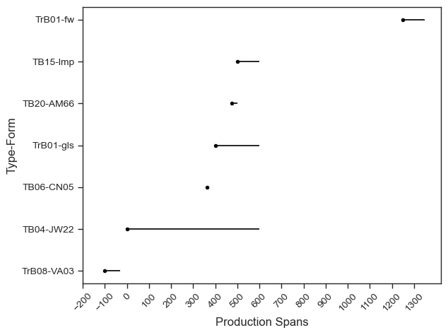

```python
KAGC_FUN.DU_MCLS_TPQ_Plt(bds1, "N", "Fig_9_31_BDS1_MCLS_TPQS", ".pdf", -200, 1350 )
#plt.xticks(rotation = 45)
#plt.savefig("F9_31_BDS1_MCLS_TPQ.pdf", dpi = 1200)
```

### CC TPQS

```python
bds1.CC_TPQS()
```

|  | DU | name | cxn | mcls | Cat | number | diag | type1 | date3 | date4 | Dspan | MPDate |
| --- | --- | --- | --- | --- | --- | --- | --- | --- | --- | --- | --- | --- |
| 1339 | BDS-1 | TRB19 | TRB19-0 | lmp | None | 0.0.3469 | UnID | lamp | 1.0 | 200.0 | 199.0 | 100.5 |
| 2950 | BDS-1 | TB21 | TB21-0 | gls | None | G17.51 | undiagnostic | undiagnostic | 51.0 | 300.0 | 249.0 | 175.5 |
| 2499 | BDS-1 | TB13 | TB13-0 | gls | None | 2927 | unguentarium | unguentarium | 101.0 | 300.0 | 199.0 | 200.5 |
| 416 | BDS-1 | TRB09 | TRB09-1 | lmp | None | 395 | Vessberg 16? | lamp | 201.0 | 300.0 | 99.0 | 250.5 |
| 641 | BDS-1 | TB10 | TB10-0 | lmp | None | 0.0.1 | Vessberg 18a? | lamp | 201.0 | 400.0 | 199.0 | 300.5 |
| 251 | BDS-1 | TRB08 | TRB08-0 | lmp | None | 593 | Vessberg 18b | lamp | 301.0 | 500.0 | 199.0 | 400.5 |
| 2613 | BDS-1 | TRB07 | TRB07-0 | gls | None | 626B | bowl | bowl | 301.0 | 500.0 | 199.0 | 400.5 |
| 210 | BDS-1 | TRB06 | TRB06-0 | lmp | None | 110 | Vessberg 18 | lamp | 301.0 | 500.0 | 199.0 | 400.5 |
| 111 | BDS-1 | TRB05 | TRB05-0 | lmp | None | 386 | Vessberg 18b | lamp | 301.0 | 500.0 | 199.0 | 400.5 |
| 110 | BDS-1 | TRB04 | TRB04-0 | lmp | LP37 | 274 | Vessberg 18b | lamp | 301.0 | 500.0 | 199.0 | 400.5 |
| 131 | BDS-1 | TRB03 | TRB03-0 | lmp | None | 212 | Vessberg 18b? | lamp | 301.0 | 500.0 | 199.0 | 400.5 |
| 638 | BDS-1 | TB19 | TB19-0 | lmp | LP39 | TB 19/1 | Vessberg 18b | lamp | 301.0 | 500.0 | 199.0 | 400.5 |
| 678 | BDS-1 | TB14 | TB14-0 | lmp | None | 0.0.10 | Vessberg 18b | lamp | 301.0 | 500.0 | 199.0 | 400.5 |
| 497 | BDS-1 | TB05 | TB05-0 | lmp | None | 194 | Vessberg 18b | lamp | 301.0 | 500.0 | 199.0 | 400.5 |
| 270 | BDS-1 | TB04 | TB04-0 | lmp | None | 301 | Vessberg 18b | lamp | 301.0 | 500.0 | 199.0 | 400.5 |
| 268 | BDS-1 | TB03 | TB03-0 | lmp | LP47 | 225 | Vessberg 18b | lamp | 301.0 | 500.0 | 199.0 | 400.5 |
| 267 | BDS-1 | TB02 | TB02-0 | lmp | None | 177 | Vessberg 18b? | lamp | 301.0 | 500.0 | 199.0 | 400.5 |
| 698 | BDS-1 | TB16 | TB16-0 | lmp | None | 0.0.51 | Vessberg 18b? | lamp | 301.0 | 500.0 | 199.0 | 400.5 |
| 1823 | BDS-1 | TB17 | TB17-0 | amp | None | TB_17_0.0_608 | LRA 1 | LRA 1 | 400.0 | 499.0 | 99.0 | 449.5 |
| 1792 | BDS-1 | TB06 | TB06-0 | amp | None | TB_6_0.0_508 | LRA 1 | LRA 1 | 400.0 | 450.0 | 50.0 | 425.0 |
| 1781 | BDS-1 | TB01 | TB01-0 | amp | AM60 | TB_1_0.0_115 | LRA 1 | LRA 1 | 450.0 | 600.0 | 150.0 | 525.0 |
| 1829 | BDS-1 | TB20 | TB20-0 | amp | AM66 | TB_20_0.0_1323 | LRA 4 | LRA 4 | 475.0 | 500.0 | 25.0 | 487.5 |
| 1039 | BDS-1 | TRB13 | TRB13-0 | lmp | LP52 | 0.0.410 | Vessberg 19? | lamp | 501.0 | 700.0 | 199.0 | 600.5 |
| 695 | BDS-1 | TB15 | TB15-0 | lmp | None | 0.0.49 | wheel-made | lamp | 501.0 | 600.0 | 99.0 | 550.5 |
| 3078 | BDS-1 | TRB01 | TRB01-0 | fw | None | 1 | byzantine fineware | Plate | 1250.0 | 1350.0 | 100.0 | 1300.0 |
| 3144 | BDS-1 | TRB02 | TRB02-0 | fw | None | 145 | cypriot green and brown glazed | Bowl | 1250.0 | 1350.0 | 100.0 | 1300.0 |
| 3079 | BDS-1 | TB09 | TB09-0 | fw | None | 547 | byzantine fineware | Plate | 1250.0 | 1350.0 | 100.0 | 1300.0 |

```python
len(bds1.CC_TPQS())
```

```
27
```

```python
len(bds1.CC_TPQS()[bds1.CC_TPQS().mcls =="lmp"])
```

```
17
```

```python
len(bds1.CC_TPQS()[bds1.CC_TPQS().date3 >= 400])
```

```
9
```

```python
bds1.CC_TPQS().mcls.value_counts()
```

```
lmp    17
amp     4
gls     3
fw      3
Name: mcls, dtype: int64
```

```python
len(bds1.CC_TPQS()[bds1.CC_TPQS().date3 >= 400])
```

```
9
```

[output not shown]

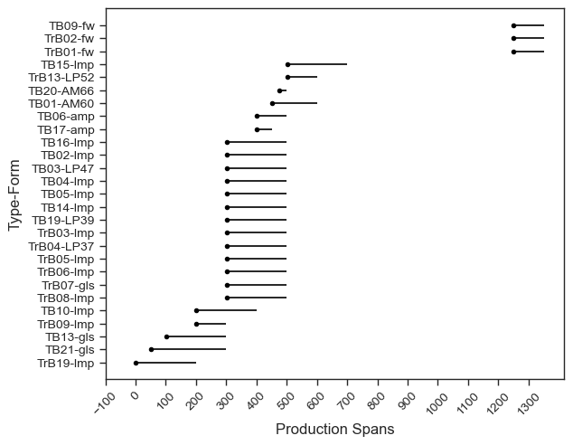

```python
KAGC_FUN.CC_DSpanPlt(bds1, "N", "", "", start =-100, stop=1400)
plt.xticks(rotation=45)
```

### BDS-1 Mean Median Dates

```python
KAGC_FUN.MMDate(bds1)
```

|  | mcls | MPDate |
| --- | --- | --- |
| 0 | amp | 61.821429 |
| 1 | fw | 24.557692 |
| 2 | gls | 262.617647 |
| 3 | jwl | 300.500000 |
| 4 | lmp | 363.973315 |
| 5 | mtl | NaN |
| 6 | num | 367.033333 |
| 7 | stn | NaN |
| 8 | trc | -65.500000 |

### Faunal

```python
bds1f =co.Faunal(art_db, KAGC_DUS.BDS1, 'BDS-1')
```

```python
bds1f.BBW()
```

|  | index | name | tr_tb | area | level | species | bone | cond | burnt | butchered | worked | freq | Comment | cxn | DU |
| --- | --- | --- | --- | --- | --- | --- | --- | --- | --- | --- | --- | --- | --- | --- | --- |
| 626 | 626.0 | TRB01 | TR | B | 0 | ovis-capra | shaft | f | y | n | n | 1.0 | None | TRB01-0 | BDS-1 |

```python
bds1f.BBWR()
```

```
122.0
```

```python
bds1.MKG2()
```

| type1 cxn | bead | beads | brazier attachment | coin | pyxis? | All |
| --- | --- | --- | --- | --- | --- | --- |
| TB04-0 | 4 | 0 | 0 | 0 | 0 | 4 |
| TB05-0 | 1 | 0 | 0 | 0 | 0 | 1 |
| TB06-0 | 15 | 0 | 0 | 13 | 1 | 29 |
| TB19-0 | 0 | 0 | 0 | 1 | 0 | 1 |
| TRB01-0 | 0 | 1 | 0 | 0 | 0 | 1 |
| TRB03-0 | 2 | 0 | 0 | 0 | 0 | 2 |
| TRB08-0 | 0 | 0 | 1 | 1 | 0 | 2 |
| All | 22 | 1 | 1 | 15 | 1 | 40 |

```python
bds1sh = co.Shell(art_db, KAGC_DUS.BDS1, 'BDS-1')
```

```python
bds1sh.FxTB()
```

| species cxn | Bolinus | Euthria | Hexaplex | All |
| --- | --- | --- | --- | --- |
| TRB19-0 | 1 | 3 | 223 | 227 |
| All | 1 | 3 | 223 | 227 |

```python
1*100/65
```

```
1.5384615384615385
```

```python
15*100/70
```

```
21.428571428571427
```

```python
23/30
```

```
0.7666666666666667
```

## DU B502

Nine Contributing Contexts (CC) comprise DU B502. When it is present, DU B502 corresponds to the middle layer in a given cist tomb. Its sediment consists of a semi-compact mottled grayish-brown sandy silt with varying amounts of rubble and tomb lid fragment inclusions. In every occurrence of DU B502, it overlaid DU B503, and in most cases, their interface was either sharply or clearly defined.

```python
b502 = co.Context(KAGC_FUN.DU_Select(df, KAGC_DUS.B502, 'B502'), -24)
```

### Cat Nos

```python
b502.DUCatNos()
```

|  | cxn | mcls | diag | Cat | type1 | date3 | date4 |
| --- | --- | --- | --- | --- | --- | --- | --- |
| 1797 | TB08-3.2 | amp | BH-AM | AM01 | BH-AM | -600.0 | -201.0 |
| 1839 | TB20-1 | amp | UnID | AM100 | UnID | NaN | NaN |
| 1838 | TB20-1 | amp | Kapitan 2 | AM57 | Kapitan 2 | 175.0 | 400.0 |
| 1835 | TB20-1 | amp | LRA 1 | AM61 | LRA 1 | 450.0 | 600.0 |
| 1813 | TB11-1 | amp | Agora M334 | AM67 | Agora M334 | 350.0 | 400.0 |
| 1833 | TB20-1 | amp | UnID | AM73 | UnID | 1.0 | 200.0 |
| 1790 | TB05-1 | amp | UnID | AM86 | UnID | NaN | NaN |
| 2849 | TB18-1 | gls | windowpane | GL747 | windowpane | 201.0 | 400.0 |
| 1343 | TB21-1 | lmp | Vessberg 18b | LP46 | lamp | 301.0 | 500.0 |
| 99 | TB05-1 | trc | figurine | TC22 | figurine | -300.0 | -250.0 |

### FCounts

```python
b502.FCounts()
```

| col_0 | index | DU | mcls | diag | date3 | date4 | Dspan | MPDate | EAAD | idn | freq | Seq |
| --- | --- | --- | --- | --- | --- | --- | --- | --- | --- | --- | --- | --- |
| 0 | 3 | B502 | amp | BH-AM | -600.0 | -201.0 | 399.0 | -400.5 | 1050.0 | amp-BH-AM--600.0--201.0 | 1 | 1 |
| 1 | 7 | B502 | amp | TR-BF-DBH | -75.0 | 175.0 | 250.0 | 50.0 | 525.0 | amp-TR-BF-DBH--75.0-175.0 | 1 | 2 |
| 2 | 4 | B502 | amp | Jug | 1.0 | 199.0 | 198.0 | 100.0 | 449.0 | amp-Jug-1.0-199.0 | 1 | 3 |
| 3 | 8 | B502 | amp | UnID | 1.0 | 199.0 | 198.0 | 100.0 | 449.0 | amp-UnID-1.0-199.0 | 3 | 4 |
| 4 | 9 | B502 | amp | UnID | 1.0 | 200.0 | 199.0 | 100.5 | 449.0 | amp-UnID-1.0-200.0 | 1 | 5 |
| 5 | 0 | B502 | amp | Agora G199 | 101.0 | 225.0 | 124.0 | 163.0 | 349.0 | amp-Agora G199-101.0-225.0 | 1 | 6 |
| 6 | 5 | B502 | amp | Kapitan 2 | 175.0 | 400.0 | 225.0 | 287.5 | 275.0 | amp-Kapitan 2-175.0-400.0 | 1 | 7 |
| 7 | 1 | B502 | amp | Agora M334 | 350.0 | 399.0 | 49.0 | 374.5 | 100.0 | amp-Agora M334-350.0-399.0 | 1 | 8 |
| 8 | 2 | B502 | amp | Agora M334 | 350.0 | 400.0 | 50.0 | 375.0 | 100.0 | amp-Agora M334-350.0-400.0 | 1 | 9 |
| 9 | 6 | B502 | amp | LRA 1 | 450.0 | 600.0 | 150.0 | 525.0 | 0.0 | amp-LRA 1-450.0-600.0 | 1 | 10 |
| 10 | 11 | B502 | fw | eastern sigillata a | -150.0 | 200.0 | 350.0 | 25.0 | 600.0 | fw-eastern sigillata a--150.0-200.0 | 1 | 11 |
| 11 | 10 | B502 | fw | cypriot sigillata form p10 | 51.0 | 150.0 | 99.0 | 100.5 | 399.0 | fw-cypriot sigillata form p10-51.0-150.0 | 1 | 12 |
| 12 | 12 | B502 | gls | bowl | -100.0 | 100.0 | 200.0 | 0.0 | 550.0 | gls-bowl--100.0-100.0 | 1 | 13 |
| 13 | 14 | B502 | gls | dish or bowl | 1.0 | 100.0 | 99.0 | 50.5 | 449.0 | gls-dish or bowl-1.0-100.0 | 1 | 14 |
| 14 | 15 | B502 | gls | undiagnostic | 1.0 | 400.0 | 399.0 | 200.5 | 449.0 | gls-undiagnostic-1.0-400.0 | 1 | 15 |
| 15 | 13 | B502 | gls | bowl | 101.0 | 300.0 | 199.0 | 200.5 | 349.0 | gls-bowl-101.0-300.0 | 1 | 16 |
| 16 | 16 | B502 | gls | windowpane | 201.0 | 400.0 | 199.0 | 300.5 | 249.0 | gls-windowpane-201.0-400.0 | 1 | 17 |
| 17 | 17 | B502 | lmp | Vessberg 10 | 1.0 | 100.0 | 99.0 | 50.5 | 449.0 | lmp-Vessberg 10-1.0-100.0 | 1 | 18 |
| 18 | 18 | B502 | lmp | Vessberg 10? | 1.0 | 100.0 | 99.0 | 50.5 | 449.0 | lmp-Vessberg 10?-1.0-100.0 | 2 | 19 |
| 19 | 19 | B502 | lmp | Vessberg 11/14? | 1.0 | 200.0 | 199.0 | 100.5 | 449.0 | lmp-Vessberg 11/14?-1.0-200.0 | 1 | 20 |
| 20 | 21 | B502 | lmp | Vessberg 18a | 201.0 | 400.0 | 199.0 | 300.5 | 249.0 | lmp-Vessberg 18a-201.0-400.0 | 2 | 21 |
| 21 | 20 | B502 | lmp | Vessberg 18 | 301.0 | 500.0 | 199.0 | 400.5 | 149.0 | lmp-Vessberg 18-301.0-500.0 | 1 | 22 |
| 22 | 22 | B502 | lmp | Vessberg 18b | 301.0 | 500.0 | 199.0 | 400.5 | 149.0 | lmp-Vessberg 18b-301.0-500.0 | 18 | 23 |
| 23 | 23 | B502 | lmp | Vessberg 18b? | 301.0 | 500.0 | 199.0 | 400.5 | 149.0 | lmp-Vessberg 18b?-301.0-500.0 | 6 | 24 |
| 24 | 24 | B502 | trc | figurine | -300.0 | -250.0 | 50.0 | -275.0 | 750.0 | trc-figurine--300.0--250.0 | 1 | 25 |

```python
b502.MCLS_Grps().get_group('gls')
```

|  | index | area | name | tb.tr | cxn | mcls | number | diag | Cat | date1 | date2 | date3 | date4 | type1 | type2 | type3 | type4 | type5 | type6 | cond | burnt | join | PL | PW | date5 | description | DU | MPDate | Dspan | … |
| --- | --- | --- | --- | --- | --- | --- | --- | --- | --- | --- | --- | --- | --- | --- | --- | --- | --- | --- | --- | --- | --- | --- | --- | --- | --- | --- | --- | --- | --- | --- |
| 2162 | 25.0 | B | TB20 | T | TB20-1 | gls | G17.95 | undiagnostic | None | None | None | NaN | NaN | undiagnostic | body | vessel | free-blown | olive-green | None | None | None | None | None | None | None | 2 B; thin-walled small curved fragments | B502 | NaN | NaN | … |
| 2211 | 74.0 | B | TB08 | T | TB08-3.2 | gls | G17.29 | undiagnostic | None | AD | AD 1-400 | 1.0 | 400.0 | undiagnostic | body | vessel | free-blown | yellow-green | None | None | None | None | None | None | None | 1 B; small thin-walled slightly curved fragment | B502 | 200.5 | 399.0 | … |
| 2309 | 172.0 | B | TB17 | T | TB17-1 | gls | 1458 | bowl | None | BC-AD | BC-AD -100-100 | -100.0 | 100.0 | bowl | rim | vessel | slumped | amber-brown | None | None | None | None | None | None | None | 1 R; vertical rim with pointed edge; convex body | B502 | 0.0 | 200.0 | … |
| 2501 | 364.0 | B | TB20 | T | TB20-1 | gls | 2926 | dish or bowl | None | AD | AD 1-100 | 1.0 | 100.0 | dish or bowl | body/base | tableware | cast | pale yellow-green | None | None | None | None | None | None | None | 10 B/6 Bs; thick-walled; flat base with vertical foot; | B502 | 50.5 | 99.0 | … |
| 2741 | 604.0 | B | TB21 | T | TB21-1 | gls | TB21/12 | bowl | None | AD | AD 101-300 | 101.0 | 300.0 | bowl | rim | vessel | free-blown | blue-green | None | None | None | None | None | None | None | 1 R; very large vertically (outward) folded rim of a large open vessel (cf. mortarium) | B502 | 200.5 | 199.0 | … |
| 2849 | 712.0 | B | TB18 | T | TB18-1 | gls | G17.75 | windowpane | GL747 | AD | AD 201-400 | 201.0 | 400.0 | windowpane | body | architectural | cylindrical blown | blue-green | None | None | None | None | None | None | None | 1 B; thin-walled; smooth and shiny on both sides | B502 | 300.5 | 199.0 | … |

### MCLS TPQs

```python
b502.MCLS_TPQS()
```

|  | DU | name | cxn | mcls | Cat | diag | type1 | type2 | date1 | date3 | date4 | Dspan | MPDate | EAAD | EAAD-M |
| --- | --- | --- | --- | --- | --- | --- | --- | --- | --- | --- | --- | --- | --- | --- | --- |
| 99 | B502 | TB05 | TB05-1 | trc | TC22 | figurine | figurine | horse back rider | BC | -300.0 | -250.0 | 50.0 | -275.0 | 750.0 | 800.0 |
| 3193 | B502 | TB18 | TB18-1 | fw | None | cypriot sigillata form p10 | UnID | rim | AD | 51.0 | 150.0 | 99.0 | 100.5 | 399.0 | 424.5 |
| 2849 | B502 | TB18 | TB18-1 | gls | GL747 | windowpane | windowpane | body | AD | 201.0 | 400.0 | 199.0 | 300.5 | 249.0 | 224.5 |
| 509 | B502 | TB08 | TB08-3.2 | lmp | None | Vessberg 18b? | lamp | base fragm | AD | 301.0 | 500.0 | 199.0 | 400.5 | 149.0 | 124.5 |
| 1835 | B502 | TB20 | TB20-1 | amp | AM61 | LRA 1 | LRA 1 | H | AD | 450.0 | 600.0 | 150.0 | 525.0 | 0.0 | 0.0 |

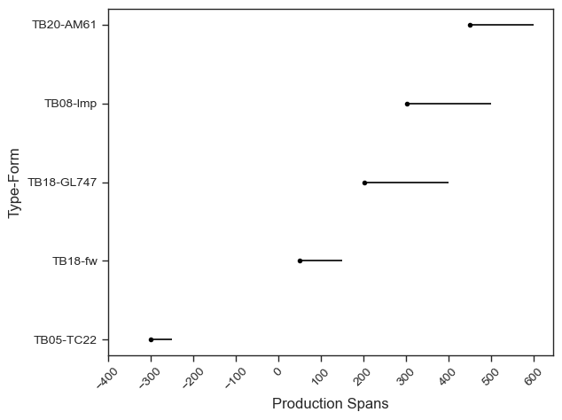

```python
KAGC_FUN.DU_MCLS_TPQ_Plt(b502, "Y", "Fig_9_27_B502_MCLS_TPQs", ".pdf", -400, 700)
```

### CC TPQS

```python
b502.CC_TPQS()
```

|  | DU | name | cxn | mcls | Cat | number | diag | type1 | date3 | date4 | Dspan | MPDate |
| --- | --- | --- | --- | --- | --- | --- | --- | --- | --- | --- | --- | --- |
| 99 | B502 | TB05 | TB05-1 | trc | TC22 | TB5/1A,B | figurine | figurine | -300.0 | -250.0 | 50.0 | -275.0 |
| 509 | B502 | TB08 | TB08-3.2 | lmp | None | 292 | Vessberg 18b? | lamp | 301.0 | 500.0 | 199.0 | 400.5 |
| 642 | B502 | TB10 | TB10-1 | lmp | None | 1.0.2 | Vessberg 18b | lamp | 301.0 | 500.0 | 199.0 | 400.5 |
| 712 | B502 | TB17 | TB17-1 | lmp | None | 1.0.64 | Vessberg 18b | lamp | 301.0 | 500.0 | 199.0 | 400.5 |
| 723 | B502 | TB18 | TB18-1 | lmp | None | 1.0.73 | Vessberg 18b | lamp | 301.0 | 500.0 | 199.0 | 400.5 |
| 1343 | B502 | TB21 | TB21-1 | lmp | LP46 | 1.0.1326 | Vessberg 18b | lamp | 301.0 | 500.0 | 199.0 | 400.5 |
| 1813 | B502 | TB11 | TB11-1 | amp | AM67 | TB_11_1.0_812 | Agora M334 | Agora M334 | 350.0 | 400.0 | 50.0 | 375.0 |
| 1835 | B502 | TB20 | TB20-1 | amp | AM61 | TB_20_1.0_1348 | LRA 1 | LRA 1 | 450.0 | 600.0 | 150.0 | 525.0 |

```python
zb502 = b502.cdu[['DU','name','cxn', 'mcls', 'Cat','diag','type1', 'type2', 'date1','date3', 'date4']].dropna(subset=['date3'])

z2b502 = zb502.loc[zb502.groupby(['cxn','mcls'])['date3'].idxmax()].sort_values(by=['cxn', 'date3'])
```

```python
zb502.sort_values(by=['cxn', 'date3'])
```

|  | DU | name | cxn | mcls | Cat | diag | type1 | type2 | date1 | date3 | date4 |
| --- | --- | --- | --- | --- | --- | --- | --- | --- | --- | --- | --- |
| 99 | B502 | TB05 | TB05-1 | trc | TC22 | figurine | figurine | horse back rider | BC | -300.0 | -250.0 |
| 1797 | B502 | TB08 | TB08-3.2 | amp | AM01 | BH-AM | BH-AM | HW | BC | -600.0 | -201.0 |
| 2211 | B502 | TB08 | TB08-3.2 | gls | None | undiagnostic | undiagnostic | body | AD | 1.0 | 400.0 |
| 509 | B502 | TB08 | TB08-3.2 | lmp | None | Vessberg 18b? | lamp | base fragm | AD | 301.0 | 500.0 |
| 510 | B502 | TB08 | TB08-3.2 | lmp | None | Vessberg 18b? | lamp | base fragm | AD | 301.0 | 500.0 |
| 511 | B502 | TB08 | TB08-3.2 | lmp | None | Vessberg 18b? | lamp | base fragm | AD | 301.0 | 500.0 |
| 512 | B502 | TB08 | TB08-3.2 | lmp | None | Vessberg 18b | lamp | upper part | AD | 301.0 | 500.0 |
| 513 | B502 | TB08 | TB08-3.2 | lmp | None | Vessberg 18b | lamp | upper part | AD | 301.0 | 500.0 |
| 643 | B502 | TB10 | TB10-1 | lmp | None | Vessberg 18a | lamp | shoulder | AD | 201.0 | 400.0 |
| 642 | B502 | TB10 | TB10-1 | lmp | None | Vessberg 18b | lamp | upper part | AD | 301.0 | 500.0 |
| 644 | B502 | TB10 | TB10-1 | lmp | None | Vessberg 18b | lamp | shoulder | AD | 301.0 | 500.0 |
| 645 | B502 | TB10 | TB10-1 | lmp | None | Vessberg 18b | lamp | shoulder | AD | 301.0 | 500.0 |
| 646 | B502 | TB10 | TB10-1 | lmp | None | Vessberg 18b? | lamp | nozzle | AD | 301.0 | 500.0 |
| 647 | B502 | TB10 | TB10-1 | lmp | None | Vessberg 18b | lamp | shoulder | AD | 301.0 | 500.0 |
| 648 | B502 | TB10 | TB10-1 | lmp | None | Vessberg 18b | lamp | shoulder | AD | 301.0 | 500.0 |
| 649 | B502 | TB10 | TB10-1 | lmp | None | Vessberg 18b | lamp | shoulder | AD | 301.0 | 500.0 |
| 650 | B502 | TB10 | TB10-1 | lmp | None | Vessberg 18b? | lamp | discus fr | AD | 301.0 | 500.0 |
| 658 | B502 | TB11 | TB11-1 | lmp | None | Vessberg 11/14? | lamp | handle | AD | 1.0 | 200.0 |
| 1813 | B502 | TB11 | TB11-1 | amp | AM67 | Agora M334 | Agora M334 | R | AD | 350.0 | 400.0 |
| 1814 | B502 | TB11 | TB11-1 | amp | None | Agora M334 | Agora M334 | HW | AD | 350.0 | 399.0 |
| 2309 | B502 | TB17 | TB17-1 | gls | None | bowl | bowl | rim | BC-AD | -100.0 | 100.0 |
| 713 | B502 | TB17 | TB17-1 | lmp | None | Vessberg 10? | lamp | shoulder | AD | 1.0 | 100.0 |
| 714 | B502 | TB17 | TB17-1 | lmp | None | Vessberg 10 | lamp | shoulder | AD | 1.0 | 100.0 |
| 712 | B502 | TB17 | TB17-1 | lmp | None | Vessberg 18b | lamp | upper part | AD | 301.0 | 500.0 |
| 715 | B502 | TB17 | TB17-1 | lmp | None | Vessberg 18b | lamp | shoulder | AD | 301.0 | 500.0 |
| 3335 | B502 | TB18 | TB18-1 | fw | None | eastern sigillata a | Bowl | rim | BC-AD | -150.0 | 200.0 |
| 1826 | B502 | TB18 | TB18-1 | amp | None | UnID | UnID | 1/W | AD | 1.0 | 199.0 |
| 1827 | B502 | TB18 | TB18-1 | amp | None | UnID | UnID | 3/W | AD | 1.0 | 199.0 |
| 3193 | B502 | TB18 | TB18-1 | fw | None | cypriot sigillata form p10 | UnID | rim | AD | 51.0 | 150.0 |
| 2849 | B502 | TB18 | TB18-1 | gls | GL747 | windowpane | windowpane | body | AD | 201.0 | 400.0 |
| 723 | B502 | TB18 | TB18-1 | lmp | None | Vessberg 18b | lamp | shoulder | AD | 301.0 | 500.0 |
| 1834 | B502 | TB20 | TB20-1 | amp | None | TR-BF-DBH | TR-BF-DBH | H | BC-AD | -75.0 | 175.0 |
| 749 | B502 | TB20 | TB20-1 | lmp | None | Vessberg 10? | lamp | shoulder | AD | 1.0 | 100.0 |
| 1833 | B502 | TB20 | TB20-1 | amp | AM73 | UnID | UnID | H | AD | 1.0 | 200.0 |
| 1837 | B502 | TB20 | TB20-1 | amp | None | UnID | UnID | HW | AD | 1.0 | 199.0 |
| 2501 | B502 | TB20 | TB20-1 | gls | None | dish or bowl | dish or bowl | body/base | AD | 1.0 | 100.0 |
| 1836 | B502 | TB20 | TB20-1 | amp | None | Agora G199 | Mau 27/28 | H | AD | 101.0 | 225.0 |
| 1838 | B502 | TB20 | TB20-1 | amp | AM57 | Kapitan 2 | Kapitan 2 | B | AD | 175.0 | 400.0 |
| 745 | B502 | TB20 | TB20-1 | lmp | None | Vessberg 18a | lamp | shoulder | AD | 201.0 | 400.0 |
| 743 | B502 | TB20 | TB20-1 | lmp | None | Vessberg 18b | lamp | shoulder | AD | 301.0 | 500.0 |
| 744 | B502 | TB20 | TB20-1 | lmp | None | Vessberg 18 | lamp | handle | AD | 301.0 | 500.0 |
| 746 | B502 | TB20 | TB20-1 | lmp | None | Vessberg 18b? | lamp | base fr | AD | 301.0 | 500.0 |
| 747 | B502 | TB20 | TB20-1 | lmp | None | Vessberg 18b | lamp | handle fr | AD | 301.0 | 500.0 |
| 748 | B502 | TB20 | TB20-1 | lmp | None | Vessberg 18b | lamp | nozzle | AD | 301.0 | 500.0 |
| 750 | B502 | TB20 | TB20-1 | lmp | None | Vessberg 18b | lamp | upper part | AD | 301.0 | 500.0 |
| 751 | B502 | TB20 | TB20-1 | lmp | None | Vessberg 18b | lamp | nozzle | AD | 301.0 | 500.0 |
| 1835 | B502 | TB20 | TB20-1 | amp | AM61 | LRA 1 | LRA 1 | H | AD | 450.0 | 600.0 |
| 1840 | B502 | TB21 | TB21-1 | amp | None | Jug | Jug | RN | AD | 1.0 | 199.0 |
| 2741 | B502 | TB21 | TB21-1 | gls | None | bowl | bowl | rim | AD | 101.0 | 300.0 |
| 1343 | B502 | TB21 | TB21-1 | lmp | LP46 | Vessberg 18b | lamp | base | AD | 301.0 | 500.0 |
| 1346 | B502 | TB21 | TB21-1 | lmp | None | Vessberg 18b | lamp | shoulder | AD | 301.0 | 500.0 |

```python
z2b502
```

|  | DU | name | cxn | mcls | Cat | diag | type1 | type2 | date1 | date3 | date4 |
| --- | --- | --- | --- | --- | --- | --- | --- | --- | --- | --- | --- |
| 99 | B502 | TB05 | TB05-1 | trc | TC22 | figurine | figurine | horse back rider | BC | -300.0 | -250.0 |
| 1797 | B502 | TB08 | TB08-3.2 | amp | AM01 | BH-AM | BH-AM | HW | BC | -600.0 | -201.0 |
| 2211 | B502 | TB08 | TB08-3.2 | gls | None | undiagnostic | undiagnostic | body | AD | 1.0 | 400.0 |
| 509 | B502 | TB08 | TB08-3.2 | lmp | None | Vessberg 18b? | lamp | base fragm | AD | 301.0 | 500.0 |
| 642 | B502 | TB10 | TB10-1 | lmp | None | Vessberg 18b | lamp | upper part | AD | 301.0 | 500.0 |
| 658 | B502 | TB11 | TB11-1 | lmp | None | Vessberg 11/14? | lamp | handle | AD | 1.0 | 200.0 |
| 1813 | B502 | TB11 | TB11-1 | amp | AM67 | Agora M334 | Agora M334 | R | AD | 350.0 | 400.0 |
| 2309 | B502 | TB17 | TB17-1 | gls | None | bowl | bowl | rim | BC-AD | -100.0 | 100.0 |
| 712 | B502 | TB17 | TB17-1 | lmp | None | Vessberg 18b | lamp | upper part | AD | 301.0 | 500.0 |
| 1826 | B502 | TB18 | TB18-1 | amp | None | UnID | UnID | 1/W | AD | 1.0 | 199.0 |
| 3193 | B502 | TB18 | TB18-1 | fw | None | cypriot sigillata form p10 | UnID | rim | AD | 51.0 | 150.0 |
| 2849 | B502 | TB18 | TB18-1 | gls | GL747 | windowpane | windowpane | body | AD | 201.0 | 400.0 |
| 723 | B502 | TB18 | TB18-1 | lmp | None | Vessberg 18b | lamp | shoulder | AD | 301.0 | 500.0 |
| 2501 | B502 | TB20 | TB20-1 | gls | None | dish or bowl | dish or bowl | body/base | AD | 1.0 | 100.0 |
| 743 | B502 | TB20 | TB20-1 | lmp | None | Vessberg 18b | lamp | shoulder | AD | 301.0 | 500.0 |
| 1835 | B502 | TB20 | TB20-1 | amp | AM61 | LRA 1 | LRA 1 | H | AD | 450.0 | 600.0 |
| 1840 | B502 | TB21 | TB21-1 | amp | None | Jug | Jug | RN | AD | 1.0 | 199.0 |
| 2741 | B502 | TB21 | TB21-1 | gls | None | bowl | bowl | rim | AD | 101.0 | 300.0 |
| 1343 | B502 | TB21 | TB21-1 | lmp | LP46 | Vessberg 18b | lamp | base | AD | 301.0 | 500.0 |

```python
z2b502[z2b502.date3 >300]
```

|  | DU | name | cxn | mcls | Cat | diag | type1 | type2 | date1 | date3 | date4 |
| --- | --- | --- | --- | --- | --- | --- | --- | --- | --- | --- | --- |
| 509 | B502 | TB08 | TB08-3.2 | lmp | None | Vessberg 18b? | lamp | base fragm | AD | 301.0 | 500.0 |
| 642 | B502 | TB10 | TB10-1 | lmp | None | Vessberg 18b | lamp | upper part | AD | 301.0 | 500.0 |
| 1813 | B502 | TB11 | TB11-1 | amp | AM67 | Agora M334 | Agora M334 | R | AD | 350.0 | 400.0 |
| 712 | B502 | TB17 | TB17-1 | lmp | None | Vessberg 18b | lamp | upper part | AD | 301.0 | 500.0 |
| 723 | B502 | TB18 | TB18-1 | lmp | None | Vessberg 18b | lamp | shoulder | AD | 301.0 | 500.0 |
| 743 | B502 | TB20 | TB20-1 | lmp | None | Vessberg 18b | lamp | shoulder | AD | 301.0 | 500.0 |
| 1835 | B502 | TB20 | TB20-1 | amp | AM61 | LRA 1 | LRA 1 | H | AD | 450.0 | 600.0 |
| 1343 | B502 | TB21 | TB21-1 | lmp | LP46 | Vessberg 18b | lamp | base | AD | 301.0 | 500.0 |

```python
b502.MCLS_Grps(). get_group('jwl')
```

|  | index | area | name | tb.tr | cxn | mcls | number | diag | Cat | date1 | date2 | date3 | date4 | type1 | type2 | type3 | type4 | type5 | type6 | cond | burnt | join | PL | PW | date5 | description | DU | MPDate | Dspan | … |
| --- | --- | --- | --- | --- | --- | --- | --- | --- | --- | --- | --- | --- | --- | --- | --- | --- | --- | --- | --- | --- | --- | --- | --- | --- | --- | --- | --- | --- | --- | --- |
| 12 | 12.0 | B | TB10 | T | TB10-1 | jwl | TB10/12 | bead | None | UnID | UnID nan-nan | NaN | NaN | bead | None | p.adornment | None | None | shell/stone | intact | None | None | None | None | None | Intact; cylinder; l 0.48, w 0.34 | B502 | NaN | NaN | … |

### B502 Summary

```python
b502.DUSmry()
```

|  | DU | TPQ | MMDate | Span | TForms | RForms | NRForms | NRF:RF | Dspan > 100 | Arch | Display | P.items | P.adorn | Tool | Production |
| --- | --- | --- | --- | --- | --- | --- | --- | --- | --- | --- | --- | --- | --- | --- | --- |
| 0 | B502 | 450.0 | 262 | 1200.0 | 25 | 5 | 20 | 4.0 | 18 | True | False | False | True | False | True |

### Marker Groups

```python
b502.MKG1()
```

| type1 cxn | moulding | suspension weight | windowpane | All |
| --- | --- | --- | --- | --- |
| TB08-3.2 | 1 | 0 | 0 | 1 |
| TB18-1 | 0 | 0 | 1 | 1 |
| TB21-1 | 0 | 1 | 0 | 1 |
| All | 1 | 1 | 1 | 3 |

```python
b502.MKG2()
```

| type1 cxn | bead | figurine | All |
| --- | --- | --- | --- |
| TB05-1 | 0 | 1 | 1 |
| TB10-1 | 1 | 0 | 1 |
| All | 1 | 1 | 2 |

```python
b502.MKG3()
```

| type1 cxn | Agora M334 | BH-AM | Bowl | Jug | Kapitan 2 | LRA 1 | Mau 27/28 | TR-BF-DBH | UnID | dish or bowl | lamp | All |
| --- | --- | --- | --- | --- | --- | --- | --- | --- | --- | --- | --- | --- |
| TB05-1 | 0 | 0 | 0 | 0 | 0 | 0 | 0 | 0 | 1 | 0 | 0 | 1 |
| TB08-3.2 | 0 | 1 | 0 | 0 | 0 | 0 | 0 | 0 | 0 | 0 | 5 | 6 |
| TB10-1 | 0 | 0 | 0 | 0 | 0 | 0 | 0 | 0 | 0 | 0 | 9 | 9 |
| TB11-1 | 2 | 0 | 0 | 0 | 0 | 0 | 0 | 0 | 0 | 0 | 1 | 3 |
| TB17-1 | 0 | 0 | 0 | 0 | 0 | 0 | 0 | 0 | 0 | 0 | 4 | 4 |
| TB18-1 | 0 | 0 | 1 | 0 | 0 | 0 | 0 | 0 | 3 | 0 | 2 | 6 |
| TB20-1 | 0 | 0 | 0 | 0 | 1 | 1 | 1 | 1 | 3 | 1 | 9 | 17 |
| TB21-1 | 0 | 0 | 0 | 1 | 0 | 0 | 0 | 0 | 0 | 0 | 4 | 5 |
| All | 2 | 1 | 1 | 1 | 1 | 1 | 1 | 1 | 7 | 1 | 34 | 51 |

```python
KAGC_FUN.MMDate(b502)
```

|  | mcls | MPDate |
| --- | --- | --- |
| 0 | amp | 156.25 |
| 1 | fw | 62.75 |
| 2 | gls | 150.40 |
| 3 | jwl | NaN |
| 4 | lmp | 350.50 |
| 5 | mtl | NaN |
| 6 | stn | NaN |
| 7 | trc | -275.00 |

### Faunal

```python
a502f =co.Faunal(art_db, KAGC_DUS.B502, 'B502')
```

```python
a502f.faun()
```

|  | index | name | tr_tb | area | level | species | bone | cond | burnt | butchered | worked | freq | Comment | cxn | DU |
| --- | --- | --- | --- | --- | --- | --- | --- | --- | --- | --- | --- | --- | --- | --- | --- |
| 52 | 52.0 | TB10 | T | B | 1 | ovis-capra | shaft | f | n | n | n | 4.0 | None | TB10-1 | B502 |
| 65 | 65.0 | TB11 | T | B | 1 | ovis-capra | molar | f | n | n | n | 1.0 | None | TB11-1 | B502 |
| 66 | 66.0 | TB11 | T | B | 1 | ovis-capra | shaft | f | n | n | n | 2.0 | None | TB11-1 | B502 |
| 91 | 91.0 | TB17 | T | B | 1 | ovis-capra | molar | i | n | n | n | 1.0 | None | TB17-1 | B502 |
| 92 | 92.0 | TB17 | T | B | 1 | ovis-capra | phalanx-1 | i | n | n | n | 1.0 | None | TB17-1 | B502 |
| 93 | 93.0 | TB17 | T | B | 1 | bird | shaft | f | n | n | n | 2.0 | None | TB17-1 | B502 |
| 103 | 103.0 | TB21 | T | B | 1 | bos-sized | vertebra | f | n | n | n | 2.0 | None | TB21-1 | B502 |
| 104 | 104.0 | TB21 | T | B | 1 | bos-sized | fragm | f | n | n | n | 25.0 | None | TB21-1 | B502 |
| 105 | 105.0 | TB21 | T | B | 1 | bird | shaft | f | n | n | n | 1.0 | None | TB21-1 | B502 |

```python
a502f.faun().freq.sum()
```

```
39.0
```

```python
b502s = co.Shell(art_db, KAGC_DUS.B502, 'B502')
```

```python
b502s.shell()
```

|  | index | area | tb_tr | name | cxn | species | type2 | freq | description | ref | DU |
| --- | --- | --- | --- | --- | --- | --- | --- | --- | --- | --- | --- |
| 1 | 1 | b | t | TB10 | TB10-1 | Fossil | Bivalve | 1 | fragment thin small | s.002 | B502 |

## DU B503

Fourteen Contributing Contexts (CC) comprise DU B503. When it is present, DU B503 corresponds to the lowest layer within a given cist tomb. Its sediment consists of loose to semi-compact comparatively thin (c. 0.25 m) deposits of either a yellowish silty sand or a yellowish-brown moist silty sand. Overall, DU B503 had appreciably fewer rubble and tomb lid fragment inclusions than DUs B502 and B501. Except for Tomb TB10, each of DU B503’s Contributing Contexts overlaid their respective tomb’s floor, and in nearly every case, this interface was sharply defined.

```python
b503 = co.Context(KAGC_FUN.DU_Select(df, KAGC_DUS.B503, 'B503'), -24)
```

### Cat nos

```python
b503.DUCatNos()
```

|  | cxn | mcls | diag | Cat | type1 | date3 | date4 |
| --- | --- | --- | --- | --- | --- | --- | --- |
| 1825 | TB17-2 | amp | Kouriote | AM14 | Kouriate | -325.0 | -275.0 |
| 1807 | TB10-2 | amp | UnID-Kouriote | AM15 | UnID-Kourite | -325.0 | -150.0 |
| 1808 | TB10-2 | amp | Dressel 43 | AM41 | Dressel 43/Creta 4 | 25.0 | 250.0 |
| 1817 | TB12-1 | amp | LRA 1 | AM59 | LRA 1 | 375.0 | 450.0 |
| 1821 | TB14-1 | amp | LRA 1 | AM63 | LRA 1 | 401.0 | 450.0 |
| 1812 | TB11-2 | amp | Agora M334 | AM67 | Agora M334 | 350.0 | 400.0 |
| 1810 | TB10-2 | amp | UnID-ER | AM84 | UnID-ER | 101.0 | 300.0 |
| 1809 | TB10-2 | amp | UnID | AM91 | UnID-Aegean fabric? | 1.0 | 200.0 |
| 1815 | TB11-2 | amp | UnID-ER | AM99 | UnID-ER | 1.0 | 200.0 |
| 3366 | TB11-2 | fw | eastern sigillata a form 3 | FW043 | Plate | -150.0 | 25.0 |
| 3430 | TB11-2 | fw | hellenistic color coated | FW066 | Bowl | -300.0 | -101.0 |
| 3074 | TB11-2 | fw | african red slip form 5 | FW184 | Plate | 50.0 | 150.0 |
| 2195 | TB05-2 | gls | windowpane | GL532 | windowpane | 201.0 | 400.0 |
| 45 | TB18-2 | jwl | ring | JW03 | ring | 301.0 | 500.0 |
| 25 | TB11-2 | jwl | earring | JW05 | earring | 301.0 | 425.0 |
| 52 | TB21-2 | jwl | earring | JW06 | earring | 301.0 | 425.0 |
| 53 | TB21-2 | jwl | earring | JW07 | earring | 301.0 | 425.0 |
| 55 | TB21-2 | jwl | earring | JW08 | earring | 301.0 | 425.0 |
| 54 | TB21-2 | jwl | earring | JW09 | earring | 201.0 | 500.0 |
| 26 | TB14-1 | jwl | earring | JW11 | earring | 101.0 | 600.0 |
| 39 | TB14-1 | jwl | earring | JW11 | earring | 101.0 | 600.0 |
| 22 | TB11-2 | jwl | amulet case | JW14 | amulet case | 201.0 | 500.0 |
| 10 | TB10-2 | jwl | bead | JW15 | bead | 1.0 | 600.0 |
| 16 | TB10-2 | jwl | bead | JW16 | bead | 1.0 | 600.0 |
| 17 | TB10-2 | jwl | bead | JW17 | bead | 1.0 | 600.0 |
| 18 | TB10-2 | jwl | bead | JW18 | bead | 1.0 | 600.0 |
| 23 | TB11-2 | jwl | bead | JW21 | bead | 1.0 | 600.0 |
| 24 | TB11-2 | jwl | bead | JW21 | bead | 1.0 | 600.0 |
| 38 | TB14-1 | jwl | ring | JW25 | ring | 201.0 | 500.0 |
| 19 | TB10-2 | jwl | hairpin | JW26 | hairpin | 201.0 | 600.0 |
| 48 | TB21-2 | jwl | hairpin | JW27 | hairpin | 201.0 | 600.0 |
| 50 | TB21-2 | jwl | hairpin | JW28 | hairpin | 201.0 | 600.0 |
| 27 | TB14-1 | jwl | buckle | JW29 | buckle | 401.0 | 600.0 |
| 42 | TB18-2 | jwl | bracelet | JW30 | bracelet | 301.0 | 500.0 |
| 43 | TB18-2 | jwl | bracelet | JW31 | bracelet | 301.0 | 500.0 |
| 44 | TB18-2 | jwl | bracelet | JW32 | bracelet | 301.0 | 500.0 |
| 46 | TB18-2 | jwl | bracelet | JW33 | bracelet | 301.0 | 500.0 |
| 47 | TB18-2 | jwl | bracelet | JW34 | bracelet | 301.0 | 500.0 |
| 637 | TB18-2 | lmp | Vessberg 18b? | LP38 | lamp | 301.0 | 400.0 |
| 639 | TB17-2 | lmp | Vessberg 18b | LP40 | lamp | 301.0 | 500.0 |
| 1427 | TB21-2 | lmp | Vessberg 18b | LP41 | lamp | 301.0 | 500.0 |
| 1360 | TB21-2 | lmp | Vessberg 18b | LP44 | lamp | 301.0 | 500.0 |
| 640 | TB18-2 | lmp | Egyptian? | LP51 | lamp | 401.0 | 700.0 |
| 1645 | TB11-2 | num | Valens – Valentinian I | CN13 | coin | 364.0 | 375.0 |
| 1646 | TB11-2 | num | Constantine I | CN14 | coin | 326.0 | 329.0 |
| 1657 | TB18-2 | num | coin | CN15 | coin | 301.0 | 500.0 |
| 1689 | TB18-2 | num | Arcadius, Honorius | CN16 | coin | 395.0 | 401.0 |
| 1690 | TB18-2 | num | Constantius II or Julian | CN17 | coin | 355.0 | 363.0 |
| 1694 | TB18-2 | num | coin | CN18 | coin | 301.0 | 500.0 |
| 1699 | TB21-2 | num | Constantine I | CN19 | coin | 317.0 | 320.0 |
| 3605 | TB16-1 | stn | None | ST16 | mortarium | NaN | NaN |
| 84 | TB13-1 | trc | figurine | TC23 | figurine | -300.0 | -250.0 |

### FCounts

```python
b503.FCounts()
```

| col_0 | index | DU | mcls | diag | date3 | date4 | Dspan | MPDate | EAAD | idn | freq | Seq |
| --- | --- | --- | --- | --- | --- | --- | --- | --- | --- | --- | --- | --- |
| 0 | 3 | B503 | amp | Kouriote | -325.0 | -275.0 | 50.0 | -300.0 | 726.0 | amp-Kouriote--325.0--275.0 | 1 | 1 |
| 1 | 11 | B503 | amp | UnID-Kouriote | -325.0 | -150.0 | 175.0 | -237.5 | 726.0 | amp-UnID-Kouriote--325.0--150.0 | 1 | 2 |
| 2 | 6 | B503 | amp | Sub-Koan type | -75.0 | 175.0 | 250.0 | 50.0 | 476.0 | amp-Sub-Koan type--75.0-175.0 | 1 | 3 |
| 3 | 0 | B503 | amp | 4W/LRA1 | 1.0 | 499.0 | 498.0 | 250.0 | 400.0 | amp-4W/LRA1-1.0-499.0 | 1 | 4 |
| 4 | 7 | B503 | amp | UnID | 1.0 | 200.0 | 199.0 | 100.5 | 400.0 | amp-UnID-1.0-200.0 | 1 | 5 |
| 5 | 8 | B503 | amp | UnID-ER | 1.0 | 200.0 | 199.0 | 100.5 | 400.0 | amp-UnID-ER-1.0-200.0 | 1 | 6 |
| 6 | 2 | B503 | amp | Dressel 43 | 25.0 | 250.0 | 225.0 | 137.5 | 376.0 | amp-Dressel 43-25.0-250.0 | 1 | 7 |
| 7 | 9 | B503 | amp | UnID-ER | 100.0 | 199.0 | 99.0 | 149.5 | 301.0 | amp-UnID-ER-100.0-199.0 | 1 | 8 |
| 8 | 10 | B503 | amp | UnID-ER | 101.0 | 300.0 | 199.0 | 200.5 | 300.0 | amp-UnID-ER-101.0-300.0 | 1 | 9 |
| 9 | 1 | B503 | amp | Agora M334 | 350.0 | 400.0 | 50.0 | 375.0 | 51.0 | amp-Agora M334-350.0-400.0 | 1 | 10 |
| 10 | 4 | B503 | amp | LRA 1 | 375.0 | 450.0 | 75.0 | 412.5 | 26.0 | amp-LRA 1-375.0-450.0 | 1 | 11 |
| 11 | 12 | B503 | amp | Water jug | 400.0 | 499.0 | 99.0 | 449.5 | 1.0 | amp-Water jug-400.0-499.0 | 1 | 12 |
| 12 | 5 | B503 | amp | LRA 1 | 401.0 | 450.0 | 49.0 | 425.5 | 0.0 | amp-LRA 1-401.0-450.0 | 1 | 13 |
| 13 | 14 | B503 | fw | classical-hellenistic black glaze | -500.0 | -201.0 | 299.0 | -350.5 | 901.0 | fw-classical-hellenistic black glaze--500.0--201.0 | 2 | 14 |
| 14 | 16 | B503 | fw | hellenistic color coated | -300.0 | -101.0 | 199.0 | -200.5 | 701.0 | fw-hellenistic color coated--300.0--101.0 | 1 | 15 |
| 15 | 15 | B503 | fw | eastern sigillata a form 3 | -150.0 | 25.0 | 175.0 | -62.5 | 551.0 | fw-eastern sigillata a form 3--150.0-25.0 | 1 | 16 |
| 16 | 13 | B503 | fw | african red slip form 5 | 50.0 | 150.0 | 100.0 | 100.0 | 351.0 | fw-african red slip form 5-50.0-150.0 | 1 | 17 |
| 17 | 20 | B503 | gls | undiagnostic | 1.0 | 700.0 | 699.0 | 350.5 | 400.0 | gls-undiagnostic-1.0-700.0 | 1 | 18 |
| 18 | 18 | B503 | gls | jug | 51.0 | 400.0 | 349.0 | 225.5 | 350.0 | gls-jug-51.0-400.0 | 1 | 19 |
| 19 | 21 | B503 | gls | undiagnostic | 51.0 | 400.0 | 349.0 | 225.5 | 350.0 | gls-undiagnostic-51.0-400.0 | 2 | 20 |
| 20 | 17 | B503 | gls | bowl | 101.0 | 300.0 | 199.0 | 200.5 | 300.0 | gls-bowl-101.0-300.0 | 1 | 21 |
| 21 | 23 | B503 | gls | unguentarium | 101.0 | 300.0 | 199.0 | 200.5 | 300.0 | gls-unguentarium-101.0-300.0 | 2 | 22 |
| 22 | 22 | B503 | gls | undiagnostic | 201.0 | 700.0 | 499.0 | 450.5 | 200.0 | gls-undiagnostic-201.0-700.0 | 1 | 23 |
| 23 | 24 | B503 | gls | windowpane | 201.0 | 400.0 | 199.0 | 300.5 | 200.0 | gls-windowpane-201.0-400.0 | 1 | 24 |
| 24 | 19 | B503 | gls | stemmed goblet | 401.0 | 600.0 | 199.0 | 500.5 | 0.0 | gls-stemmed goblet-401.0-600.0 | 1 | 25 |
| 25 | 26 | B503 | jwl | bead | 1.0 | 600.0 | 599.0 | 300.5 | 400.0 | jwl-bead-1.0-600.0 | 6 | 26 |
| 26 | 29 | B503 | jwl | earring | 101.0 | 600.0 | 499.0 | 350.5 | 300.0 | jwl-earring-101.0-600.0 | 2 | 27 |
| 27 | 25 | B503 | jwl | amulet case | 201.0 | 500.0 | 299.0 | 350.5 | 200.0 | jwl-amulet case-201.0-500.0 | 1 | 28 |
| 28 | 30 | B503 | jwl | earring | 201.0 | 500.0 | 299.0 | 350.5 | 200.0 | jwl-earring-201.0-500.0 | 1 | 29 |
| 29 | 32 | B503 | jwl | hairpin | 201.0 | 600.0 | 399.0 | 400.5 | 200.0 | jwl-hairpin-201.0-600.0 | 3 | 30 |
| 30 | 33 | B503 | jwl | ring | 201.0 | 500.0 | 299.0 | 350.5 | 200.0 | jwl-ring-201.0-500.0 | 1 | 31 |
| 31 | 27 | B503 | jwl | bracelet | 301.0 | 500.0 | 199.0 | 400.5 | 100.0 | jwl-bracelet-301.0-500.0 | 5 | 32 |
| 32 | 31 | B503 | jwl | earring | 301.0 | 425.0 | 124.0 | 363.0 | 100.0 | jwl-earring-301.0-425.0 | 4 | 33 |
| 33 | 34 | B503 | jwl | ring | 301.0 | 500.0 | 199.0 | 400.5 | 100.0 | jwl-ring-301.0-500.0 | 1 | 34 |
| 34 | 28 | B503 | jwl | buckle | 401.0 | 600.0 | 199.0 | 500.5 | 0.0 | jwl-buckle-401.0-600.0 | 1 | 35 |
| 35 | 35 | B503 | lmp | UnID | 1.0 | 100.0 | 99.0 | 50.5 | 400.0 | lmp-UnID-1.0-100.0 | 1 | 36 |
| 36 | 36 | B503 | lmp | UnID | 1.0 | 200.0 | 199.0 | 100.5 | 400.0 | lmp-UnID-1.0-200.0 | 1 | 37 |
| 37 | 39 | B503 | lmp | Vessberg 10? | 1.0 | 100.0 | 99.0 | 50.5 | 400.0 | lmp-Vessberg 10?-1.0-100.0 | 2 | 38 |
| 38 | 40 | B503 | lmp | Vessberg 13? | 1.0 | 200.0 | 199.0 | 100.5 | 400.0 | lmp-Vessberg 13?-1.0-200.0 | 1 | 39 |
| 39 | 43 | B503 | lmp | Vessberg 18a | 201.0 | 400.0 | 199.0 | 300.5 | 200.0 | lmp-Vessberg 18a-201.0-400.0 | 3 | 40 |
| 40 | 44 | B503 | lmp | Vessberg 18a? | 201.0 | 400.0 | 199.0 | 300.5 | 200.0 | lmp-Vessberg 18a?-201.0-400.0 | 1 | 41 |
| 41 | 37 | B503 | lmp | UnID | 301.0 | 500.0 | 199.0 | 400.5 | 100.0 | lmp-UnID-301.0-500.0 | 3 | 42 |
| 42 | 41 | B503 | lmp | Vessberg 18 | 301.0 | 500.0 | 199.0 | 400.5 | 100.0 | lmp-Vessberg 18-301.0-500.0 | 14 | 43 |
| 43 | 42 | B503 | lmp | Vessberg 18? | 301.0 | 500.0 | 199.0 | 400.5 | 100.0 | lmp-Vessberg 18?-301.0-500.0 | 2 | 44 |
| 44 | 45 | B503 | lmp | Vessberg 18b | 301.0 | 500.0 | 199.0 | 400.5 | 100.0 | lmp-Vessberg 18b-301.0-500.0 | 135 | 45 |
| 45 | 46 | B503 | lmp | Vessberg 18b? | 301.0 | 400.0 | 99.0 | 350.5 | 100.0 | lmp-Vessberg 18b?-301.0-400.0 | 1 | 46 |
| 46 | 47 | B503 | lmp | Vessberg 18b? | 301.0 | 500.0 | 199.0 | 400.5 | 100.0 | lmp-Vessberg 18b?-301.0-500.0 | 34 | 47 |
| 47 | 38 | B503 | lmp | Egyptian? | 401.0 | 700.0 | 299.0 | 550.5 | 0.0 | lmp-Egyptian?-401.0-700.0 | 1 | 48 |
| 48 | 48 | B503 | lmp | Vessberg 20? | 401.0 | 700.0 | 299.0 | 550.5 | 0.0 | lmp-Vessberg 20?-401.0-700.0 | 1 | 49 |
| 49 | 54 | B503 | num | coin | 301.0 | 500.0 | 199.0 | 400.5 | 100.0 | num-coin-301.0-500.0 | 50 | 50 |
| 50 | 50 | B503 | num | Constantine I | 317.0 | 320.0 | 3.0 | 318.5 | 84.0 | num-Constantine I-317.0-320.0 | 1 | 51 |
| 51 | 51 | B503 | num | Constantine I | 326.0 | 329.0 | 3.0 | 327.5 | 75.0 | num-Constantine I-326.0-329.0 | 1 | 52 |
| 52 | 52 | B503 | num | Constantius II or Julian | 355.0 | 363.0 | 8.0 | 359.0 | 46.0 | num-Constantius II or Julian-355.0-363.0 | 1 | 53 |
| 53 | 53 | B503 | num | Valens – Valentinian I | 364.0 | 375.0 | 11.0 | 369.5 | 37.0 | num-Valens – Valentinian I-364.0-375.0 | 1 | 54 |
| 54 | 49 | B503 | num | Arcadius, Honorius | 395.0 | 401.0 | 6.0 | 398.0 | 6.0 | num-Arcadius, Honorius-395.0-401.0 | 1 | 55 |
| 55 | 55 | B503 | trc | figurine | -300.0 | -250.0 | 50.0 | -275.0 | 701.0 | trc-figurine--300.0--250.0 | 1 | 56 |

```python
#b503.FCounts().to_excel("B503_FCounts.xlsx")
```

```python
sum(b503.FCounts().Dspan > 200)
```

```
16
```

### MCLS TPQs

```python
b503.MCLS_TPQS()
```

|  | DU | name | cxn | mcls | Cat | diag | type1 | type2 | date1 | date3 | date4 | Dspan | MPDate | EAAD | EAAD-M |
| --- | --- | --- | --- | --- | --- | --- | --- | --- | --- | --- | --- | --- | --- | --- | --- |
| 84 | B503 | TB13 | TB13-1 | trc | TC23 | figurine | figurine | horse torso | BC | -300.0 | -250.0 | 50.0 | -275.0 | 701.0 | 825.5 |
| 3074 | B503 | TB11 | TB11-2 | fw | FW184 | african red slip form 5 | Plate | rim | AD | 50.0 | 150.0 | 100.0 | 100.0 | 351.0 | 450.5 |
| 1689 | B503 | TB18 | TB18-2 | num | CN16 | Arcadius, Honorius | coin | intact | AD | 395.0 | 401.0 | 6.0 | 398.0 | 6.0 | 152.5 |
| 1821 | B503 | TB14 | TB14-1 | amp | AM63 | LRA 1 | LRA 1 | HW | AD | 401.0 | 450.0 | 49.0 | 425.5 | 0.0 | 125.0 |
| 2155 | B503 | TB14 | TB14-1 | gls | None | stemmed goblet | stemmed goblet | base | AD | 401.0 | 600.0 | 199.0 | 500.5 | 0.0 | 50.0 |
| 27 | B503 | TB14 | TB14-1 | jwl | JW29 | buckle | buckle | ogival with tongue | AD | 401.0 | 600.0 | 199.0 | 500.5 | 0.0 | 50.0 |
| 640 | B503 | TB18 | TB18-2 | lmp | LP51 | Egyptian? | lamp | half preserved | AD | 401.0 | 700.0 | 299.0 | 550.5 | 0.0 | 0.0 |

```python
b503.MCLS_TPQS()[b503.MCLS_TPQS().date3 > 400].MPDate.mean()
```

```
494.25
```

```python
np.mean([425,500.5, 500.5, 550.5])
```

```
494.125
```

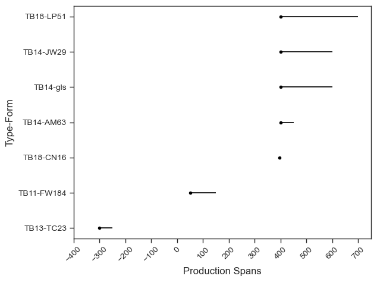

```python
KAGC_FUN.DU_MCLS_TPQ_Plt(b503, "N", "FIG_9_26_B503_MCLS_TPQs", ".pdf", -400, 800)
```

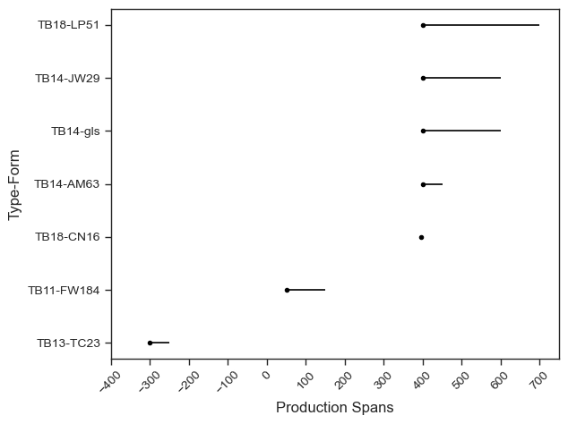

```python
KAGC_FUN.DU_MCLS_TPQ_Plt(b503, "N", "", "", -400, 800)
```

### CC TPQS

```python
b503.CC_TPQS()
```

|  | DU | name | cxn | mcls | Cat | number | diag | type1 | date3 | date4 | Dspan | MPDate |
| --- | --- | --- | --- | --- | --- | --- | --- | --- | --- | --- | --- | --- |
| 500 | B503 | TB05 | TB05-2 | lmp | None | 289 | Vessberg 18b | lamp | 301.0 | 500.0 | 199.0 | 400.5 |
| 673 | B503 | TB13 | TB13-1 | lmp | None | 1.0.32 | Vessberg 18b? | lamp | 301.0 | 500.0 | 199.0 | 400.5 |
| 696 | B503 | TB15 | TB15-2 | lmp | None | 1822 | Vessberg 18b | lamp | 301.0 | 500.0 | 199.0 | 400.5 |
| 639 | B503 | TB17 | TB17-2 | lmp | LP40 | TB 17/2 2.0 | Vessberg 18b | lamp | 301.0 | 500.0 | 199.0 | 400.5 |
| 752 | B503 | TB20 | TB20-2 | lmp | None | 2.0.84 | Vessberg 18b | lamp | 301.0 | 500.0 | 199.0 | 400.5 |
| 1699 | B503 | TB21 | TB21-2 | num | CN19 | Tb21/5 | Constantine I | coin | 317.0 | 320.0 | 3.0 | 318.5 |
| 1645 | B503 | TB11 | TB11-2 | num | CN13 | Tb11/6 | Valens – Valentinian I | coin | 364.0 | 375.0 | 11.0 | 369.5 |
| 1817 | B503 | TB12 | TB12-1 | amp | AM59 | TB_12_1.0_1279A, B | LRA 1 | LRA 1 | 375.0 | 450.0 | 75.0 | 412.5 |
| 1806 | B503 | TB10 | TB10-2 | amp | None | TB_10_2.0_13 | Water jug | Water jug | 400.0 | 499.0 | 99.0 | 449.5 |
| 27 | B503 | TB14 | TB14-1 | jwl | JW29 | TB14/13 | buckle | buckle | 401.0 | 600.0 | 199.0 | 500.5 |
| 701 | B503 | TB16 | TB16-1 | lmp | None | 1.0.55 | Vessberg 20? | lamp | 401.0 | 700.0 | 299.0 | 550.5 |
| 640 | B503 | TB18 | TB18-2 | lmp | LP51 | 2.0.7 | Egyptian? | lamp | 401.0 | 700.0 | 299.0 | 550.5 |

```python
b503.CC_TPQS()[b503.CC_TPQS().date3> 400].MPDate.mean()
```

```
533.8333333333334
```

```python
z1 = b503.cdu[['DU','name','cxn', 'mcls', 'Cat','diag','type1', 'type2', 'date1','date3', 'date4']].dropna(subset=['date3'])

z2 = z1.loc[z1.groupby(['cxn','mcls'])['date3'].idxmax()].sort_values(by=['cxn', 'date3'])
```

```python
z3 = z1[z1.date3 >400]

z3['MPDate'] = z3.loc[:, 'date3':'date4'].apply(np.median, axis = 1)
```

```python
z3
```

|  | DU | name | cxn | mcls | Cat | diag | type1 | type2 | date1 | date3 | date4 | MPDate |
| --- | --- | --- | --- | --- | --- | --- | --- | --- | --- | --- | --- | --- |
| 27 | B503 | TB14 | TB14-1 | jwl | JW29 | buckle | buckle | ogival with tongue | AD | 401.0 | 600.0 | 500.5 |
| 640 | B503 | TB18 | TB18-2 | lmp | LP51 | Egyptian? | lamp | half preserved | AD | 401.0 | 700.0 | 550.5 |
| 701 | B503 | TB16 | TB16-1 | lmp | None | Vessberg 20? | lamp | shoulder | AD | 401.0 | 700.0 | 550.5 |
| 1821 | B503 | TB14 | TB14-1 | amp | AM63 | LRA 1 | LRA 1 | HW | AD | 401.0 | 450.0 | 425.5 |
| 2155 | B503 | TB14 | TB14-1 | gls | None | stemmed goblet | stemmed goblet | base | AD | 401.0 | 600.0 | 500.5 |

```python
z3.cxn.unique()
```

```
array(['TB14-1', 'TB18-2', 'TB16-1'], dtype=object)
```

```python
z3.MPDate.mean()
```

```
505.5
```

```python
z2.cxn.unique()
```

```
array(['TB05-2', 'TB10-2', 'TB11-2', 'TB12-1', 'TB13-1', 'TB14-1',
       'TB15-2', 'TB16-1', 'TB17-2', 'TB18-2', 'TB20-2', 'TB21-2'],
      dtype=object)
```

```python
z2[z2.cxn.isin(['TB18-2'])]
```

|  | DU | name | cxn | mcls | Cat | diag | type1 | type2 | date1 | date3 | date4 |
| --- | --- | --- | --- | --- | --- | --- | --- | --- | --- | --- | --- |
| 42 | B503 | TB18 | TB18-2 | jwl | JW30 | bracelet | bracelet | twisted wire | AD | 301.0 | 500.0 |
| 1689 | B503 | TB18 | TB18-2 | num | CN16 | Arcadius, Honorius | coin | intact | AD | 395.0 | 401.0 |
| 640 | B503 | TB18 | TB18-2 | lmp | LP51 | Egyptian? | lamp | half preserved | AD | 401.0 | 700.0 |

```python
z2.diag.unique()
```

```
array(['classical-hellenistic black glaze', 'windowpane', 'Vessberg 18b',
       'hairpin', 'Vessberg 18b?', 'coin', 'Water jug',
       'african red slip form 5', 'earring', 'Agora M334',
       'Valens – Valentinian I', 'undiagnostic', 'LRA 1', 'figurine',
       'Sub-Koan type', 'stemmed goblet', 'buckle', '4W/LRA1',
       'Vessberg 20?', 'Kouriote', 'bracelet', 'Arcadius, Honorius',
       'Egyptian?', 'unguentarium', 'Constantine I'], dtype=object)
```

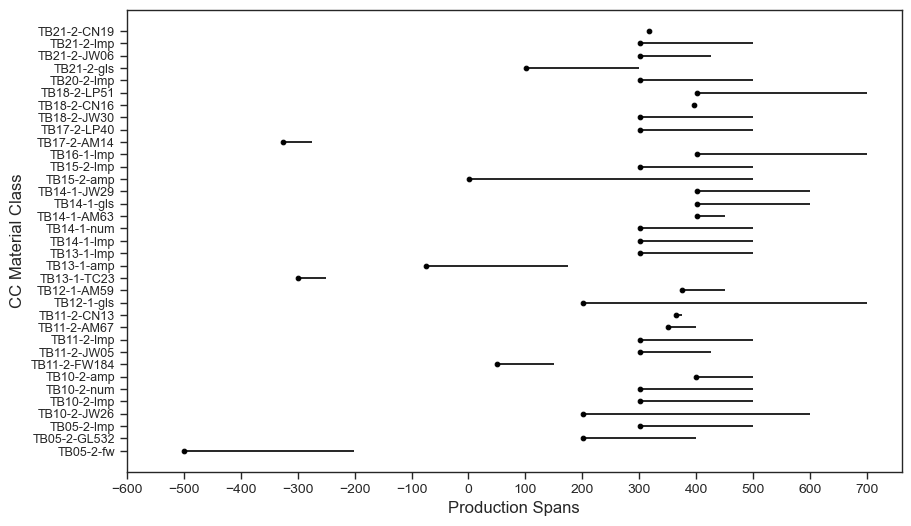

```python
CC_GenPlot(z2, "N", "B503_CC_TPQ", ".png", start=-600, stop= 800)
```

```python
b503.CC_TPQS().Dspan.describe()
```

```
count     12.000000
mean     165.000000
std       97.823589
min        3.000000
25%       93.000000
50%      199.000000
75%      199.000000
max      299.000000
Name: Dspan, dtype: float64
```

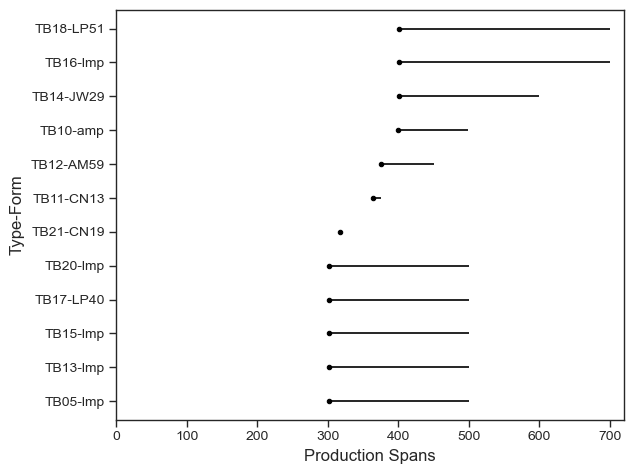

```python
KAGC_FUN.CC_DSpanPlt(b503, "N", "B503_CC_TPQs", ".png", -0, 800)
```

```python
#b503.CC_TPQS().to_excel("Chap_9_Tables.xlsx", sheet_name="B503_CC_TPQs")
```

```python
#b503_A.to_excel("b503_A.xlsx")
```

#### ubiquity

```python
KAGC_FUN.UBQ_MCLS(b503.cdu, KAGC_DUS.B503)
```

```
{'DU CC': 14,
 'Artifact Ubiquity': [('cxn', 0.93),
  ('amp', 0.57),
  ('fw', 0.14),
  ('gls', 0.64),
  ('jwl', 0.5),
  ('lmp', 0.79),
  ('mtl', 0.29),
  ('num', 0.36),
  ('stn', 0.36),
  ('trc', 0.07)]}
```

```python
b503.ResidualForms().cxn.unique()
```

```
array(['TB13-1', 'TB10-2', 'TB17-2', 'TB11-2', 'TB05-2'], dtype=object)
```

```python
b503.MCLS_Grps().get_group('gls').sort_values('date3')
```

|  | index | area | name | tb.tr | cxn | mcls | number | diag | Cat | date1 | date2 | date3 | date4 | type1 | type2 | type3 | type4 | type5 | type6 | cond | burnt | join | PL | PW | date5 | description | DU | MPDate | Dspan | … |
| --- | --- | --- | --- | --- | --- | --- | --- | --- | --- | --- | --- | --- | --- | --- | --- | --- | --- | --- | --- | --- | --- | --- | --- | --- | --- | --- | --- | --- | --- | --- |
| 2264 | 127.0 | B | TB14 | T | TB14-1 | gls | 1460 | undiagnostic | None | AD | AD 1-700 | 1.0 | 700.0 | undiagnostic | undiagnostic | vessel | undiagnostic | pale blue-green | None | deformed by fire/secondary melted | None | None | None | None | None | 2 irregular pieces; deformed by fire = secondary melted (pyre remains?) | B503 | 350.5 | 699.0 | … |
| 2237 | 100.0 | B | TB12 | T | TB12-1 | gls | 1461 | jug | None | AD | AD 51-400 | 51.0 | 400.0 | jug | handle | storage-processing | free-blown | pale blue-green | None | None | None | None | None | None | None | 1 R/H; horizonal outward rim with small upward-inward folded edge; narrow rounded handle from rim to neck and curving open in a large bow | B503 | 225.5 | 349.0 | … |
| 2949 | 812.0 | B | TB21 | T | TB21-2 | gls | G17.52 | undiagnostic | None | AD | AD 51-400 | 51.0 | 400.0 | undiagnostic | body | vessel | free-blown | pale blue-green | None | None | None | None | None | None | None | 12 B; very thin-walled; slightly curved | B503 | 225.5 | 349.0 | … |
| 2951 | 814.0 | B | TB21 | T | TB21-2 | gls | G17.53 | undiagnostic | None | AD | AD 51-400 | 51.0 | 400.0 | undiagnostic | base | vessel | free-blown | pale blue-green | None | None | None | None | None | None | None | 1 Bs; hemispherical base without footstand becoming thin-walled towards the belly | B503 | 225.5 | 349.0 | … |
| 2189 | 52.0 | B | TB14 | T | TB14-1 | gls | 1459 | unguentarium | None | AD | AD 101-300 | 101.0 | 300.0 | unguentarium | body | ung | free-blown | decolourised | None | None | None | None | None | None | None | 1 N; thin-walled; start of cylindrical neck with constriction at the shoulder | B503 | 200.5 | 199.0 | … |
| 2935 | 798.0 | B | TB21 | T | TB21-2 | gls | TB21/14 | unguentarium | None | AD | AD 101-300 | 101.0 | 300.0 | unguentarium | rim | ung | free-blown | decolourised | None | None | None | None | None | None | None | 1 R; horizontal rim with edge folded outward-upward-inward | B503 | 200.5 | 199.0 | … |
| 2956 | 819.0 | B | TB21 | T | TB21-2 | gls | TB21/15 | bowl | None | AD | AD 101-300 | 101.0 | 300.0 | bowl | rim | vessel | free-blown | blue-green | None | None | None | None | None | None | None | 1 R; small part of a very large vertically (outward) folded rim | B503 | 200.5 | 199.0 | … |
| 2156 | 19.0 | B | TB12 | T | TB12-1 | gls | G17.39 | undiagnostic | None | AD | AD 201-700 | 201.0 | 700.0 | undiagnostic | body | vessel | free-blown | decolourised | None | strongly weathered | None | None | None | None | None | 6 B; slightly concave wall fragments; strongly weathered | B503 | 450.5 | 499.0 | … |
| 2195 | 58.0 | B | TB05 | T | TB05-2 | gls | G17.18 | windowpane | GL532 | AD | AD 201-400 | 201.0 | 400.0 | windowpane | body | architectural | cylindrical blown | pale blue-green | None | None | None | None | None | None | None | 1 B; straight thin-walled small fragment | B503 | 300.5 | 199.0 | … |
| 2155 | 18.0 | B | TB14 | T | TB14-1 | gls | G17.38 | stemmed goblet | None | AD | AD 401-600 | 401.0 | 600.0 | stemmed goblet | base | tableware | free-blown | pale blue-green | None | None | None | None | None | None | None | 1 Bs; folded conical footstand | B503 | 500.5 | 199.0 | … |
| 2692 | 555.0 | B | TB10 | T | TB10-2 | gls | G17.60 | unguentarium | None | None | None | NaN | NaN | unguentarium | body | ung | free-blown | decolourised | None | None | None | None | None | None | None | 8 B; thin-walled; non-joining | B503 | NaN | NaN | … |
| 2697 | 560.0 | B | TB13 | T | TB13-1 | gls | G17.63 | bottle | None | None | None | NaN | NaN | bottle | base | storage-processing | mould-blown | blue-green | None | None | None | None | None | None | None | 1 Bs; thick-walled; incomplete circular negative pontil mark | B503 | NaN | NaN | … |
| 2703 | 566.0 | B | TB14 | T | TB14-1 | gls | G17.65 | undiagnostic | None | None | None | NaN | NaN | undiagnostic | undiagnostic | vessel | undiagnostic | undefined | None | deformed by fire/secondary melted | None | None | None | None | None | 1 irregular fragment deformed by fire; strongly weathered | B503 | NaN | NaN | … |
| 2704 | 567.0 | B | TB14 | T | TB14-1 | gls | G17.66 | undiagnostic | None | None | None | NaN | NaN | undiagnostic | body | vessel | free-blown | decolourised | None | None | None | None | None | None | None | 2 B; very thin-walled | B503 | NaN | NaN | … |
| 2705 | 568.0 | B | TB15 | T | TB15-2 | gls | G17.67 | undiagnostic | None | None | None | NaN | NaN | undiagnostic | body | vessel | free-blown | decolourised | None | None | None | None | None | None | None | 1 B; thin-walled; very small fragment | B503 | NaN | NaN | … |
| 2744 | 607.0 | B | TB16 | T | TB16-1 | gls | G17.69 | undiagnostic | None | None | None | NaN | NaN | undiagnostic | body | vessel | free-blown | pale blue-green | None | None | None | None | None | None | None | 1 B; curved fragment (neck?) | B503 | NaN | NaN | … |
| 2766 | 629.0 | B | TB16 | T | TB16-1 | gls | G17.70 | undiagnostic | None | None | None | NaN | NaN | undiagnostic | body | vessel | free-blown | pale blue-green | None | None | None | None | None | None | None | 1 B; curved | B503 | NaN | NaN | … |
| 2822 | 685.0 | B | TB16 | T | TB16-1 | gls | G17.72 | undiagnostic | None | None | None | NaN | NaN | undiagnostic | body | vessel | free-blown | decolourised | None | None | None | None | None | None | None | 1 B; thin-walled | B503 | NaN | NaN | … |
| 2826 | 689.0 | B | TB16 | T | TB16-1 | gls | G17.71 | undiagnostic | None | None | None | NaN | NaN | undiagnostic | body | vessel | cast | amber-brown | None | None | None | None | None | None | None | 1 B; thick-walled; small fragment (possibly of an early cast bowl) | B503 | NaN | NaN | … |
| 2847 | 710.0 | B | TB17 | T | TB17-2 | gls | G17.73 | undiagnostic | None | None | None | NaN | NaN | undiagnostic | body | vessel | free-blown | decolourised | None | None | None | None | None | None | None | 1 B; thin-walled | B503 | NaN | NaN | … |
| 2848 | 711.0 | B | TB17 | T | TB17-2 | gls | G17.74 | undiagnostic | None | None | None | NaN | NaN | undiagnostic | undiagnostic | vessel | undiagnostic | yellow-green | None | None | None | None | None | None | None | 1 B; thick-walled; very small fragment | B503 | NaN | NaN | … |
| 2851 | 714.0 | B | TB17 | T | TB17-2 | gls | G17.76 | undiagnostic | None | None | None | NaN | NaN | undiagnostic | body | vessel | free-blown | undefined | None | strongly weathered | None | None | None | None | None | 5 B; very thin-walled; strongly weathered | B503 | NaN | NaN | … |

```python
len(b503.cdu[b503.cdu.type1 =="coin"])
```

```
55
```

```python
5/14
```

```
0.35714285714285715
```

```python
b503.cdu.MPDate.mean()
```

```
365.90453074433657
```

```python
b503.cdu.date4.max() - b503.cdu.date3.min()
```

```
1200.0
```

```python
b503f =co.Faunal(art_db, KAGC_DUS.B503, 'B503')
```

```python
b503f.faun()
```

|  | index | name | tr_tb | area | level | species | bone | cond | burnt | butchered | worked | freq | Comment | cxn | DU |
| --- | --- | --- | --- | --- | --- | --- | --- | --- | --- | --- | --- | --- | --- | --- | --- |
| 12 | 12.0 | TB05 | T | B | 2 | ovis-capra | tibia | f | n | n | n | 1.0 | None | TB05-2 | B503 |
| 13 | 13.0 | TB05 | T | B | 2 | ovis-capra | unid | f | n | n | n | 4.0 | None | TB05-2 | B503 |
| 14 | 14.0 | TB05 | T | B | 2 | bos | carpus-tarsus | i | n | n | n | 1.0 | None | TB05-2 | B503 |
| 53 | 53.0 | TB10 | T | B | 2 | ovis-capra | horncore | f | n | n | n | 2.0 | None | TB10-2 | B503 |
| 54 | 54.0 | TB10 | T | B | 2 | ovis-capra | premolar | i | n | n | n | 1.0 | None | TB10-2 | B503 |
| 55 | 55.0 | TB10 | T | B | 2 | ovis-capra | mandible | f | n | n | n | 1.0 | None | TB10-2 | B503 |
| 56 | 56.0 | TB10 | T | B | 2 | ovis-capra | rib | f | n | n | n | 1.0 | None | TB10-2 | B503 |
| 57 | 57.0 | TB10 | T | B | 2 | ovis-capra | shaft | f | n | n | n | 2.0 | None | TB10-2 | B503 |
| 58 | 58.0 | TB10 | T | B | 2 | bos | pelvis | f | n | n | n | 3.0 | None | TB10-2 | B503 |
| 59 | 59.0 | TB10 | T | B | 2 | bos | phalanx-1 | f | n | n | n | 2.0 | None | TB10-2 | B503 |
| 60 | 60.0 | TB10 | T | B | 2 | rodent | pelvis | i | n | n | n | 1.0 | None | TB10-2 | B503 |
| 61 | 61.0 | TB10 | T | B | 2 | rodent | femur | i | n | n | n | 1.0 | None | TB10-2 | B503 |
| 62 | 62.0 | TB10 | T | B | 2 | rodent | rib | i | n | n | n | 1.0 | None | TB10-2 | B503 |
| 63 | 63.0 | TB10 | T | B | 2 | rodent | fragm | f | n | n | n | 1.0 | None | TB10-2 | B503 |
| 64 | 64.0 | TB10 | T | B | 2 | unid | unid | f | n | n | n | 4.0 | None | TB10-2 | B503 |
| 67 | 67.0 | TB11 | T | B | 2 | unid | tooth | f | y | n | n | 1.0 | None | TB11-2 | B503 |
| 68 | 68.0 | TB11 | T | B | 2 | equus caballus | molar | f | n | n | n | 3.0 | None | TB11-2 | B503 |
| 69 | 69.0 | TB11 | T | B | 2 | erinaceus | limb | i | n | n | n | 7.0 | 1 MNI | TB11-2 | B503 |
| 73 | 73.0 | TB13 | T | B | 1 | ovis-capra | molar | f | n | n | n | 8.0 | upper & lower, young adult | TB13-1 | B503 |
| 74 | 74.0 | TB13 | T | B | 1 | sus | molar | f | n | n | n | 2.0 | None | TB13-1 | B503 |
| 75 | 75.0 | TB13 | T | B | 1 | equus caballus | incisor | f | n | n | n | 1.0 | None | TB13-1 | B503 |
| 76 | 76.0 | TB13 | T | B | 1 | equus caballus | molar | f | n | n | n | 3.0 | None | TB13-1 | B503 |
| 77 | 77.0 | TB13 | T | B | 1 | equus caballus | rib | f | n | n | n | 1.0 | None | TB13-1 | B503 |
| 78 | 78.0 | TB13 | T | B | 1 | equus caballus | shaft | f | n | n | n | 1.0 | None | TB13-1 | B503 |
| 79 | 79.0 | TB13 | T | B | 1 | frog | bone | i | n | n | n | 5.0 | None | TB13-1 | B503 |
| 81 | 81.0 | TB14 | T | B | 1 | ovis-capra | skull | f | n | n | n | 5.0 | None | TB14-1 | B503 |
| 82 | 82.0 | TB14 | T | B | 1 | ovis-capra | fragm | f | n | n | n | 2.0 | None | TB14-1 | B503 |
| 83 | 83.0 | TB14 | T | B | 1 | erinaceus | scapula | i | n | n | n | 1.0 | None | TB14-1 | B503 |
| 84 | 84.0 | TB14 | T | B | 1 | rodent | femur | i | n | n | n | 1.0 | None | TB14-1 | B503 |
| 85 | 85.0 | TB14 | T | B | 1 | frog | limb | i | n | n | n | 1.0 | None | TB14-1 | B503 |
| 90 | 90.0 | TB16 | T | B | 1 | patella | shell | i | n | n | n | 1.0 | None | TB16-1 | B503 |
| 94 | 94.0 | TB17 | T | B | 2 | ovis-capra | humerus | f | n | n | n | 1.0 | None | TB17-2 | B503 |
| 95 | 95.0 | TB17 | T | B | 2 | ovis-capra | phalanx-2 | f | n | n | n | 1.0 | None | TB17-2 | B503 |
| 96 | 96.0 | TB17 | T | B | 2 | ovis-capra | shaft | f | n | n | n | 1.0 | None | TB17-2 | B503 |
| 97 | 97.0 | TB17 | T | B | 2 | equus caballus | molar | i | n | n | n | 1.0 | None | TB17-2 | B503 |
| 98 | 98.0 | TB17 | T | B | 2 | equus caballus | ulna | f | n | n | n | 1.0 | None | TB17-2 | B503 |
| 99 | 99.0 | TB17 | T | B | 2 | equus caballus | calcaneus | f | n | n | n | 1.0 | None | TB17-2 | B503 |
| 100 | 100.0 | TB17 | T | B | 2 | rodent | femur | i | n | n | n | 1.0 | None | TB17-2 | B503 |
| 101 | 101.0 | TB18 | T | B | 2 | bird | shaft | f | y | n | n | 1.0 | None | TB18-2 | B503 |
| 102 | 102.0 | TB18 | T | B | 2 | fish ?sparid | skull | f | n | n | n | 1.0 | None | TB18-2 | B503 |
| 106 | 106.0 | TB21 | T | B | 2 | bird | tibiotarsus | i | n | n | n | 1.0 | None | TB21-2 | B503 |
| 107 | 107.0 | TB21 | T | B | 2 | bird | phalanx-1 | i | n | n | n | 1.0 | None | TB21-2 | B503 |
| 108 | 108.0 | TB21 | T | B | 2 | bird | shaft | f | n | n | n | 4.0 | None | TB21-2 | B503 |
| 109 | 109.0 | TB21 | T | B | 2 | frog | humerus | i | n | n | n | 1.0 | None | TB21-2 | B503 |
| 110 | 110.0 | TB21 | T | B | 2 | unid | skull | i | n | n | n | 1.0 | None | TB21-2 | B503 |
| 111 | 111.0 | TB21 | T | B | 2 | mouse/shrew | unid | i | n | n | n | 1.0 | None | TB21-2 | B503 |
| 112 | 112.0 | TB21 | T | B | 2 | unid | skull | i | n | n | n | 1.0 | None | TB21-2 | B503 |
| 113 | 113.0 | TB21 | T | B | 2 | bird | bone | i | n | n | n | 1.0 | None | TB21-2 | B503 |
| 788 | 788.0 | TB05 | T | B | 2 | ovis-capra | horn core | f | n | n | n | 1.0 | None | TB05-2 | B503 |
| 789 | 789.0 | TB05 | T | B | 2 | ovis-capra | scapula | f | n | n | n | 1.0 | None | TB05-2 | B503 |
| 790 | 790.0 | TB05 | T | B | 2 | unid | unid | None | None | None | None | 9.0 | None | TB05-2 | B503 |
| 797 | 797.0 | TB13 | T | B | 1 | unid | unid | f | n | n | n | 10.0 | None | TB13-1 | B503 |
| 798 | 798.0 | TB14 | T | B | 1 | unid | unid | f | n | n | n | 3.0 | None | TB14-1 | B503 |

```python
b503f.faun().freq.sum()
```

```
113.0
```

```python
b503s = co.Shell(art_db, KAGC_DUS.B503, 'B503')
```

```python
b503s.shell()
```

|  | index | area | tb_tr | name | cxn | species | type2 | freq | description | ref | DU |
| --- | --- | --- | --- | --- | --- | --- | --- | --- | --- | --- | --- |
| 2 | 2 | b | t | TB10 | TB10-2 | Antalis vulgaris | None | 1 | None | s.003 | B503 |
| 4 | 4 | b | t | TB16 | TB16-1 | Patella | None | 1 | None | s.005 | B503 |

### B503 Summary

```python
b503.DUSmry()
```

|  | DU | TPQ | MMDate | Span | TForms | RForms | NRForms | NRF:RF | Dspan > 100 | Arch | Display | P.items | P.adorn | Tool | Production |
| --- | --- | --- | --- | --- | --- | --- | --- | --- | --- | --- | --- | --- | --- | --- | --- |
| 0 | B503 | 401.0 | 366 | 1200.0 | 56 | 7 | 49 | 7.0 | 40 | True | False | True | True | False | True |

```python
b503.ResidualForms().cxn.unique()
```

```
array(['TB13-1', 'TB10-2', 'TB17-2', 'TB11-2', 'TB05-2'], dtype=object)
```

```python
b503.ResidualForms().cxn.nunique()/len(KAGC_DUS.B503)
```

```
0.35714285714285715
```

```python
len(b503.ResidualForms())
```

```
8
```

### Mean Median Dates

```python
KAGC_FUN.MMDate(b503)
```

|  | mcls | MPDate |
| --- | --- | --- |
| 0 | amp | 162.576923 |
| 1 | fw | -172.800000 |
| 2 | gls | 288.000000 |
| 3 | jwl | 364.500000 |
| 4 | lmp | 391.500000 |
| 5 | mtl | NaN |
| 6 | num | 396.318182 |
| 7 | stn | NaN |
| 8 | trc | -275.000000 |

```python
bds1Sum  = bds1.DUSmry()
b502Sum = b502.DUSmry()
b503Sum = b503.DUSmry()
```

```python
BDUsum = pd.concat([bds1Sum, b502Sum, b503Sum])
```

```python
BDUsum
```

|  | DU | TPQ | MMDate | Span | TForms | RForms | NRForms | NRF:RF | Dspan > 100 | Arch | Display | P.items | P.adorn | Tool | Production |
| --- | --- | --- | --- | --- | --- | --- | --- | --- | --- | --- | --- | --- | --- | --- | --- |
| 0 | BDS-1 | 1250.0 | 314 | 1850.0 | 112 | 23 | 89 | 3.87 | 72 | True | True | True | True | True | True |
| 0 | B502 | 450.0 | 262 | 1200.0 | 25 | 5 | 20 | 4.00 | 18 | True | False | False | True | False | True |
| 0 | B503 | 401.0 | 366 | 1200.0 | 56 | 7 | 49 | 7.00 | 40 | True | False | True | True | False | True |

### Marker Groups

```python
b503.MKG2()
```

| type1 cxn | amulet case | bead | bracelet | buckle | coin | earring | figurine | hairpin | hairring | mirror | pyxis? | ring | All |
| --- | --- | --- | --- | --- | --- | --- | --- | --- | --- | --- | --- | --- | --- |
| TB05-2 | 0 | 2 | 0 | 0 | 0 | 0 | 0 | 0 | 0 | 0 | 0 | 0 | 2 |
| TB10-2 | 0 | 10 | 0 | 0 | 1 | 0 | 0 | 4 | 1 | 0 | 0 | 0 | 16 |
| TB11-2 | 1 | 4 | 0 | 0 | 2 | 1 | 0 | 0 | 0 | 0 | 0 | 0 | 8 |
| TB13-1 | 0 | 0 | 0 | 0 | 0 | 0 | 1 | 0 | 0 | 0 | 0 | 0 | 1 |
| TB14-1 | 0 | 3 | 0 | 1 | 1 | 2 | 0 | 6 | 1 | 3 | 0 | 1 | 18 |
| TB15-2 | 0 | 0 | 0 | 0 | 0 | 0 | 0 | 0 | 0 | 0 | 1 | 1 | 2 |
| TB18-2 | 0 | 0 | 5 | 0 | 50 | 0 | 0 | 0 | 0 | 0 | 1 | 1 | 57 |
| TB21-2 | 0 | 0 | 0 | 0 | 1 | 4 | 0 | 4 | 0 | 0 | 0 | 0 | 9 |
| All | 1 | 19 | 5 | 1 | 55 | 7 | 1 | 14 | 2 | 3 | 2 | 3 | 113 |

```python
#b503.MKG2().to_excel("B503_MG2.xlsx")
```

```python
14*100/112
```

```
12.5
```

##### comments

```python
xb503 = b503.MKG2().reset_index()
```

```python
xb503
```

| type1 | cxn | amulet case | bead | bracelet | buckle | coin | earring | figurine | hairpin | hairring | mirror | pyxis? | ring | All |
| --- | --- | --- | --- | --- | --- | --- | --- | --- | --- | --- | --- | --- | --- | --- |
| 0 | TB05-2 | 0 | 2 | 0 | 0 | 0 | 0 | 0 | 0 | 0 | 0 | 0 | 0 | 2 |
| 1 | TB10-2 | 0 | 10 | 0 | 0 | 1 | 0 | 0 | 4 | 1 | 0 | 0 | 0 | 16 |
| 2 | TB11-2 | 1 | 4 | 0 | 0 | 2 | 1 | 0 | 0 | 0 | 0 | 0 | 0 | 8 |
| 3 | TB13-1 | 0 | 0 | 0 | 0 | 0 | 0 | 1 | 0 | 0 | 0 | 0 | 0 | 1 |
| 4 | TB14-1 | 0 | 3 | 0 | 1 | 1 | 2 | 0 | 6 | 1 | 3 | 0 | 1 | 18 |
| 5 | TB15-2 | 0 | 0 | 0 | 0 | 0 | 0 | 0 | 0 | 0 | 0 | 1 | 1 | 2 |
| 6 | TB18-2 | 0 | 0 | 5 | 0 | 50 | 0 | 0 | 0 | 0 | 0 | 1 | 1 | 57 |
| 7 | TB21-2 | 0 | 0 | 0 | 0 | 1 | 4 | 0 | 4 | 0 | 0 | 0 | 0 | 9 |
| 8 | All | 1 | 19 | 5 | 1 | 55 | 7 | 1 | 14 | 2 | 3 | 2 | 3 | 113 |

```python
xb503a = xb503.iloc[0:7, 1:12].applymap(KAGC_FUN.to_binary()); xb503a
```

| type1 | amulet case | bead | bracelet | buckle | coin | earring | figurine | hairpin | hairring | mirror | pyxis? |
| --- | --- | --- | --- | --- | --- | --- | --- | --- | --- | --- | --- |
| 0 | 0 | 1 | 0 | 0 | 0 | 0 | 0 | 0 | 0 | 0 | 0 |
| 1 | 0 | 1 | 0 | 0 | 1 | 0 | 0 | 1 | 1 | 0 | 0 |
| 2 | 1 | 1 | 0 | 0 | 1 | 1 | 0 | 0 | 0 | 0 | 0 |
| 3 | 0 | 0 | 0 | 0 | 0 | 0 | 1 | 0 | 0 | 0 | 0 |
| 4 | 0 | 1 | 0 | 1 | 1 | 1 | 0 | 1 | 1 | 1 | 0 |
| 5 | 0 | 0 | 0 | 0 | 0 | 0 | 0 | 0 | 0 | 0 | 1 |
| 6 | 0 | 0 | 1 | 0 | 1 | 0 | 0 | 0 | 0 | 0 | 1 |

```python
xb503a.iloc[:, 1:13].sum(axis=1).median()
```

```
3.0
```

```python
b503.MKG3()
```

| type1 cxn | 4W/LRA1 | Agora M334 | Bowl | Dressel 43/Creta 4 | Kouriate | LRA 1 | Plate | Pot stand | Sub-Koan type | UnID | UnID-Aegean fabric? | UnID-ER | UnID-Kourite | Water jug | bottle | jug | lamp | stemmed goblet | unguentarium | All |
| --- | --- | --- | --- | --- | --- | --- | --- | --- | --- | --- | --- | --- | --- | --- | --- | --- | --- | --- | --- | --- |
| TB05-2 | 0 | 0 | 1 | 0 | 0 | 0 | 0 | 0 | 0 | 0 | 0 | 0 | 0 | 0 | 0 | 0 | 2 | 0 | 0 | 3 |
| TB09-0.1 | 0 | 0 | 0 | 0 | 0 | 0 | 0 | 0 | 0 | 1 | 0 | 0 | 0 | 0 | 0 | 0 | 0 | 0 | 0 | 1 |
| TB10-2 | 0 | 0 | 0 | 1 | 0 | 0 | 0 | 1 | 0 | 0 | 1 | 1 | 1 | 1 | 0 | 0 | 7 | 0 | 1 | 14 |
| TB11-2 | 0 | 1 | 2 | 0 | 0 | 0 | 2 | 0 | 0 | 0 | 0 | 1 | 0 | 0 | 0 | 0 | 13 | 0 | 0 | 19 |
| TB12-1 | 0 | 0 | 0 | 0 | 0 | 1 | 0 | 0 | 0 | 2 | 0 | 0 | 0 | 0 | 0 | 1 | 0 | 0 | 0 | 4 |
| TB13-1 | 0 | 0 | 0 | 0 | 0 | 0 | 0 | 0 | 1 | 0 | 0 | 0 | 0 | 0 | 1 | 0 | 5 | 0 | 0 | 7 |
| TB14-1 | 0 | 0 | 0 | 0 | 0 | 1 | 0 | 0 | 0 | 0 | 0 | 1 | 0 | 0 | 0 | 0 | 7 | 1 | 1 | 11 |
| TB15-2 | 1 | 0 | 0 | 0 | 0 | 0 | 0 | 0 | 0 | 0 | 0 | 0 | 0 | 0 | 0 | 0 | 1 | 0 | 0 | 2 |
| TB16-1 | 0 | 0 | 0 | 0 | 0 | 0 | 0 | 0 | 0 | 0 | 0 | 0 | 0 | 0 | 0 | 0 | 9 | 0 | 0 | 9 |
| TB17-2 | 0 | 0 | 0 | 0 | 1 | 0 | 0 | 0 | 0 | 0 | 0 | 0 | 0 | 0 | 0 | 0 | 8 | 0 | 0 | 9 |
| TB18-2 | 0 | 0 | 0 | 0 | 0 | 0 | 0 | 0 | 0 | 0 | 0 | 0 | 0 | 0 | 0 | 0 | 16 | 0 | 0 | 16 |
| TB20-2 | 0 | 0 | 0 | 0 | 0 | 0 | 0 | 0 | 0 | 0 | 0 | 0 | 0 | 0 | 0 | 0 | 69 | 0 | 0 | 69 |
| TB21-2 | 0 | 0 | 0 | 0 | 0 | 0 | 0 | 0 | 0 | 0 | 0 | 0 | 0 | 0 | 0 | 0 | 130 | 0 | 1 | 131 |
| All | 1 | 1 | 3 | 1 | 1 | 2 | 2 | 1 | 1 | 3 | 1 | 3 | 1 | 1 | 1 | 1 | 267 | 1 | 3 | 295 |

```python
b503.MCLS_Grps().get_group('lmp').diag.value_counts()
```

```
Vessberg 18b     135
UnID              71
Vessberg 18b?     35
Vessberg 18       14
Vessberg 18a       3
Vessberg 10?       2
Vessberg 18?       2
Egyptian?          1
lamp?              1
Vessberg 18a?      1
Vessberg 20?       1
Vessberg 13?       1
Name: diag, dtype: int64
```

```python
b503.MKG1 ()
```

| type1 cxn | fitting | mortarium | moulding | revetment | windowpane | All |
| --- | --- | --- | --- | --- | --- | --- |
| TB05-2 | 0 | 0 | 0 | 0 | 1 | 1 |
| TB14-1 | 0 | 0 | 1 | 0 | 0 | 1 |
| TB16-1 | 0 | 1 | 0 | 3 | 0 | 4 |
| TB18-2 | 1 | 0 | 0 | 0 | 0 | 1 |
| TB21-2 | 0 | 0 | 0 | 2 | 0 | 2 |
| All | 1 | 1 | 1 | 5 | 1 | 9 |

# Area B Case studies

he case studies presented in this section illustrate the primary stratigraphic sequences from Area B’s cist tombs. Tomb TB03 represents several tombs that contain only one DU, BDS-1’s DU B501 component. Similarly, Tomb TB09 provides an excellent representative example of cist tombs where BDS-1’s DU B501 component directly overlies DU B503. TB18 provides a clear example of the standard three deposit stratigraphic sequence, BDS-1’s DU B501 component, DU B502, and B503, from Area B’s cist tombs. Besides providing a clear example of the standard three-deposit sequence, TB10 also provides a unique example of a heavily modified/repaired cist tomb floor. Its “false” floor has no parallels within the KAGC study area. TB08 has the most complex stratigraphic sequence out of the cist tombs the project excavated. It also provides evidence of episodic infilling and historical disturbance not recorded in the stratigraphic sequences from Area B’s other cist tombs. The case studies also include one trench, Trench TrB09, which has a comparatively complex deposit sequence that includes DUs B901 and B002/BDS-1, an unaffiliated context, and two features (FB19 & FB17). In Chapter 10, we discuss Trench TrB15, the case study for DU B901.

## TB03

Tomb TB03 (max. L: 1.77 m; max. W: 0.76 m; D: 0.19–0.35 m; orientation: E–W; headrest: W; DU B501; BDS-1; MNI: 1) contained one context, 001, which is a Contributing Context to DU B501. The excavators also noted that this tomb lacks framing drainage channels and is noticeably shallow compared to neighboring Tombs TB01, TB04, and TB09 and has a damaged headrest. Except for a tibia fragment, the human bone assemblage consists mostly of unidentifiable fragments attributable to one indeterminate individual (Volume 2, Chapter 2).

```python
tb03 = co.TrenchTomb(df[df.name=='TB03'])
```

```python
tb03.cxn_mcls()
```

```
{'Levels': array(['TB03-0'], dtype=object),
 'Mcls': array(['lmp', 'gls', 'fw', 'stn'], dtype=object)}
```

```python
tb03.TrTb_L('TB03-0')
```

|  | cxn | mcls | diag | Cat | type1 | type2 | date3 | date4 | DSpan | MPDate |
| --- | --- | --- | --- | --- | --- | --- | --- | --- | --- | --- |
| 3100 | TB03-0 | fw | classical-hellenistic black glaze | None | UnID | body sherd | -500.0 | -201.0 | 299.0 | -350.5 |
| 2260 | TB03-0 | gls | undiagnostic | None | undiagnostic | base | 51.0 | 250.0 | 199.0 | 150.5 |
| 268 | TB03-0 | lmp | Vessberg 18b | LP47 | lamp | base | 301.0 | 500.0 | 199.0 | 400.5 |
| 269 | TB03-0 | lmp | Vessberg 18b | LP48 | lamp | base, body and upper part | 301.0 | 500.0 | 199.0 | 400.5 |
| 3542 | TB03-0 | stn | None | None | revetment | fragment | NaN | NaN | NaN | NaN |

## TB08

```python
tb08 = co.TrenchTomb(df[df.name=='TB08'])
```

```python
tb08.cxn_mcls()
```

```
{'Levels': array(['TB08-1', 'TB08-3.2'], dtype=object),
 'Mcls': array(['lmp', 'amp', 'gls', 'stn'], dtype=object)}
```

```python
tb08.TrTb_L('TB08-1')
```

|  | cxn | mcls | diag | Cat | type1 | type2 | date3 | date4 | DSpan | MPDate |
| --- | --- | --- | --- | --- | --- | --- | --- | --- | --- | --- |
| 508 | TB08-1 | lmp | Vessberg 18b | None | lamp | shoulder | 301.0 | 500.0 | 199.0 | 400.5 |

```python
KAGC_DUS.B502
```

```
['TB08-3.2',
 'TB05-1',
 'TB10-1',
 'TB11-1',
 'TB15-1',
 'TB17-1',
 'TB18-1',
 'TB20-1',
 'TB21-1']
```

```python
tb08.TrTb_L('TB08-3.2')
```

|  | cxn | mcls | diag | Cat | type1 | type2 | date3 | date4 | DSpan | MPDate |
| --- | --- | --- | --- | --- | --- | --- | --- | --- | --- | --- |
| 1797 | TB08-3.2 | amp | BH-AM | AM01 | BH-AM | HW | -600.0 | -201.0 | 399.0 | -400.5 |
| 2211 | TB08-3.2 | gls | undiagnostic | None | undiagnostic | body | 1.0 | 400.0 | 399.0 | 200.5 |
| 509 | TB08-3.2 | lmp | Vessberg 18b? | None | lamp | base fragm | 301.0 | 500.0 | 199.0 | 400.5 |
| 510 | TB08-3.2 | lmp | Vessberg 18b? | None | lamp | base fragm | 301.0 | 500.0 | 199.0 | 400.5 |
| 511 | TB08-3.2 | lmp | Vessberg 18b? | None | lamp | base fragm | 301.0 | 500.0 | 199.0 | 400.5 |
| 512 | TB08-3.2 | lmp | Vessberg 18b | None | lamp | upper part | 301.0 | 500.0 | 199.0 | 400.5 |
| 513 | TB08-3.2 | lmp | Vessberg 18b | None | lamp | upper part | 301.0 | 500.0 | 199.0 | 400.5 |
| 3538 | TB08-3.2 | stn | None | None | moulding | fragment | NaN | NaN | NaN | NaN |

## TB09

Tomb TB09 (max. L: 2.03 m; max. width: 0.85 m; D: 0.61–0.78 m; orientation: E–W; headrest: W; DU: B501, B503; MNI: 1) contained two contexts, 001 and 002, which are Contributing Contexts to DUs B501 and B503 respectively. The excavators noted that more significant pieces of rubble and lid fragments occupied the tomb’s western sector. They also noted that a large root had damaged a substantial portion of the tomb’s northern sector.

```python
tb09 = co.TrenchTomb(df[df.name=='TB09'])
```

```python
tb09.cxn_mcls()
```

```
{'Levels': array(['TB09-0', 'TB09-0.1'], dtype=object),
 'Mcls': array(['lmp', 'amp', 'fw'], dtype=object)}
```

```python
tb09.TrTb_L('TB09-0')
```

|  | cxn | mcls | diag | Cat | type1 | type2 | date3 | date4 | DSpan | MPDate |
| --- | --- | --- | --- | --- | --- | --- | --- | --- | --- | --- |
| 1801 | TB09-0 | amp | UnID-Kouriote | AM09 | UnID-Kouriate | H | -325.0 | -150.0 | 175.0 | -237.5 |
| 1803 | TB09-0 | amp | Kos | AM02 | Kos | HW | -225.0 | -1.0 | 224.0 | -113.0 |
| 1799 | TB09-0 | amp | Kos | AM05 | Kos | R | -75.0 | 175.0 | 250.0 | 50.0 |
| 1802 | TB09-0 | amp | TR-BF-DBH | None | TR-BF-DBH | H | -75.0 | 175.0 | 250.0 | 50.0 |
| 1798 | TB09-0 | amp | UnID | None | UnID | R | 1.0 | 99.0 | 98.0 | 50.0 |
| 1800 | TB09-0 | amp | Mau 27/28 | None | Mau 27/28 | HW | 100.0 | 199.0 | 99.0 | 149.5 |
| 1804 | TB09-0 | amp | LRA 4 | None | LRA 4 | HW | 300.0 | 499.0 | 199.0 | 399.5 |
| 3102 | TB09-0 | fw | classical-hellenistic black glaze | FW014 | Bowl | rim | -500.0 | -201.0 | 299.0 | -350.5 |
| 3103 | TB09-0 | fw | classical-hellenistic black glaze | None | Unguentarium | neck | -500.0 | -201.0 | 299.0 | -350.5 |
| 3145 | TB09-0 | fw | cypriot red slip form 8 | None | Bowl | rim | 500.0 | 650.0 | 150.0 | 575.0 |
| 3079 | TB09-0 | fw | byzantine fineware | None | Plate | body sherd | 1250.0 | 1350.0 | 100.0 | 1300.0 |
| 514 | TB09-0 | lmp | Vessberg 10? | None | lamp | base fragm | 1.0 | 100.0 | 99.0 | 50.5 |

```python
tb09.TrTb_L('TB09-0.1')
```

|  | cxn | mcls | diag | Cat | type1 | type2 | date3 | date4 | DSpan | MPDate |
| --- | --- | --- | --- | --- | --- | --- | --- | --- | --- | --- |
| 1805 | TB09-0.1 | amp | UnID | None | UnID | H | NaN | NaN | NaN | NaN |

## TB10

Tomb TB10 (max L: 1.92 m; max. W: 0.82 m; orientation: E–W; headrest: W; DU: B501–B503; MNI: 8) contained six contexts. The first three contexts, 001, 002, and 003, are Contributing Contexts to DUs B501, B502, and B503, respectively. The latter three contexts (i004–006) are associated with a repair to the tomb’s floor.

```python
tb10 = co.TrenchTomb(df[df.name=='TB10'])
```

```python
tb10.cxn_mcls()
```

```
{'Levels': array(['TB10-2', 'TB10-1', 'TB10-0'], dtype=object),
 'Mcls': array(['jwl', 'lmp', 'num', 'amp', 'gls', 'stn'], dtype=object)}
```

```python
tb10.TrTb_L('TB10-0')
```

|  | cxn | mcls | diag | Cat | type1 | type2 | date3 | date4 | DSpan | MPDate |
| --- | --- | --- | --- | --- | --- | --- | --- | --- | --- | --- |
| 641 | TB10-0 | lmp | Vessberg 18a? | None | lamp | shoulder | 201.0 | 400.0 | 199.0 | 300.5 |

```python
tb10.TrTb_L('TB10-1')
```

|  | cxn | mcls | diag | Cat | type1 | type2 | date3 | date4 | DSpan | MPDate |
| --- | --- | --- | --- | --- | --- | --- | --- | --- | --- | --- |
| 12 | TB10-1 | jwl | bead | None | bead | None | NaN | NaN | NaN | NaN |
| 643 | TB10-1 | lmp | Vessberg 18a | None | lamp | shoulder | 201.0 | 400.0 | 199.0 | 300.5 |
| 642 | TB10-1 | lmp | Vessberg 18b | None | lamp | upper part | 301.0 | 500.0 | 199.0 | 400.5 |
| 644 | TB10-1 | lmp | Vessberg 18b | None | lamp | shoulder | 301.0 | 500.0 | 199.0 | 400.5 |
| 645 | TB10-1 | lmp | Vessberg 18b | None | lamp | shoulder | 301.0 | 500.0 | 199.0 | 400.5 |
| 646 | TB10-1 | lmp | Vessberg 18b? | None | lamp | nozzle | 301.0 | 500.0 | 199.0 | 400.5 |
| 647 | TB10-1 | lmp | Vessberg 18b | None | lamp | shoulder | 301.0 | 500.0 | 199.0 | 400.5 |
| 648 | TB10-1 | lmp | Vessberg 18b | None | lamp | shoulder | 301.0 | 500.0 | 199.0 | 400.5 |
| 649 | TB10-1 | lmp | Vessberg 18b | None | lamp | shoulder | 301.0 | 500.0 | 199.0 | 400.5 |
| 650 | TB10-1 | lmp | Vessberg 18b? | None | lamp | discus fr | 301.0 | 500.0 | 199.0 | 400.5 |

```python
tb10.TrTb_L('TB10-2')
```

|  | cxn | mcls | diag | Cat | type1 | type2 | date3 | date4 | DSpan | MPDate |
| --- | --- | --- | --- | --- | --- | --- | --- | --- | --- | --- |
| 1807 | TB10-2 | amp | UnID-Kouriote | AM15 | UnID-Kourite | B | -325.0 | -150.0 | 175.0 | -237.5 |
| 1809 | TB10-2 | amp | UnID | AM91 | UnID-Aegean fabric? | H | 1.0 | 200.0 | 199.0 | 100.5 |
| 1808 | TB10-2 | amp | Dressel 43 | AM41 | Dressel 43/Creta 4 | H | 25.0 | 250.0 | 225.0 | 137.5 |
| 1810 | TB10-2 | amp | UnID-ER | AM84 | UnID-ER | H | 101.0 | 300.0 | 199.0 | 200.5 |
| 1806 | TB10-2 | amp | Water jug | None | Water jug | NHBODY | 400.0 | 499.0 | 99.0 | 449.5 |
| 1811 | TB10-2 | amp | Pot stand | None | Pot stand | R | NaN | NaN | NaN | NaN |
| 2692 | TB10-2 | gls | unguentarium | None | unguentarium | body | NaN | NaN | NaN | NaN |
| 10 | TB10-2 | jwl | bead | JW15 | bead | ridged | 1.0 | 600.0 | 599.0 | 300.5 |
| 16 | TB10-2 | jwl | bead | JW16 | bead | hexagonal | 1.0 | 600.0 | 599.0 | 300.5 |
| 17 | TB10-2 | jwl | bead | JW17 | bead | hexagonal | 1.0 | 600.0 | 599.0 | 300.5 |
| 18 | TB10-2 | jwl | bead | JW18 | bead | hexagonal | 1.0 | 600.0 | 599.0 | 300.5 |
| 19 | TB10-2 | jwl | hairpin | JW26 | hairpin | curved | 201.0 | 600.0 | 399.0 | 400.5 |
| 1 | TB10-2 | jwl | bead | None | bead | None | NaN | NaN | NaN | NaN |
| 11 | TB10-2 | jwl | hairpin | None | hairpin | shaft | NaN | NaN | NaN | NaN |
| 13 | TB10-2 | jwl | hairring | None | hairring | None | NaN | NaN | NaN | NaN |
| 14 | TB10-2 | jwl | bead | None | bead | None | NaN | NaN | NaN | NaN |
| 15 | TB10-2 | jwl | bead | None | bead | None | NaN | NaN | NaN | NaN |
| 20 | TB10-2 | jwl | hairpin | None | hairpin | head+shaft | NaN | NaN | NaN | NaN |
| 21 | TB10-2 | jwl | hairpin | None | hairpin | head+shaft | NaN | NaN | NaN | NaN |
| 651 | TB10-2 | lmp | Vessberg 18b? | None | lamp | base fr | 301.0 | 500.0 | 199.0 | 400.5 |
| 652 | TB10-2 | lmp | Vessberg 18b? | None | lamp | body | 301.0 | 500.0 | 199.0 | 400.5 |
| 653 | TB10-2 | lmp | Vessberg 18b? | None | lamp | upper part | 301.0 | 500.0 | 199.0 | 400.5 |
| 654 | TB10-2 | lmp | Vessberg 18b? | None | lamp | body | 301.0 | 500.0 | 199.0 | 400.5 |
| 655 | TB10-2 | lmp | UnID | None | lamp | nozzle | 301.0 | 500.0 | 199.0 | 400.5 |
| 657 | TB10-2 | lmp | Vessberg 18b | None | lamp | shoulder | 301.0 | 500.0 | 199.0 | 400.5 |
| 656 | TB10-2 | lmp | lamp? | None | lamp | fragm of body | NaN | NaN | NaN | NaN |
| 1644 | TB10-2 | num | coin | None | coin | intact | 301.0 | 500.0 | 199.0 | 400.5 |
| 3615 | TB10-2 | stn | None | None | bead | incomplete | NaN | NaN | NaN | NaN |
| 3616 | TB10-2 | stn | None | None | bead | complete | NaN | NaN | NaN | NaN |
| 3617 | TB10-2 | stn | None | None | bead | complete | NaN | NaN | NaN | NaN |

## TB18

Tomb B18 (max. length: 1.85 m; max. width: 0.88 m; max. depth: 0.80 m; orientation: E–W; headrest: W; DUs B501–B503; MNI: 3) contained three contexts, 001, 002, and 003, which are Contributing Contexts for DUs B501, B502, and B503 respectively.

```python
tb18 = co.TrenchTomb(df[df.name=='TB18'])
```

```python
tb18.cxn_mcls()
```

```
{'Levels': array(['TB18-2', 'TB18-1'], dtype=object),
 'Mcls': array(['jwl', 'lmp', 'num', 'mtl', 'amp', 'gls', 'fw'], dtype=object)}
```

```python
tb18.TrTb_L('TB18-1')
```

|  | cxn | mcls | diag | Cat | type1 | type2 | date3 | date4 | DSpan | MPDate |
| --- | --- | --- | --- | --- | --- | --- | --- | --- | --- | --- |
| 1826 | TB18-1 | amp | UnID | None | UnID | 1/W | 1.0 | 199.0 | 198.0 | 100.0 |
| 1827 | TB18-1 | amp | UnID | None | UnID | 3/W | 1.0 | 199.0 | 198.0 | 100.0 |
| 3335 | TB18-1 | fw | eastern sigillata a | None | Bowl | rim | -150.0 | 200.0 | 350.0 | 25.0 |
| 3193 | TB18-1 | fw | cypriot sigillata form p10 | None | UnID | rim | 51.0 | 150.0 | 99.0 | 100.5 |
| 2849 | TB18-1 | gls | windowpane | GL747 | windowpane | body | 201.0 | 400.0 | 199.0 | 300.5 |
| 723 | TB18-1 | lmp | Vessberg 18b | None | lamp | shoulder | 301.0 | 500.0 | 199.0 | 400.5 |
| 724 | TB18-1 | lmp | UnID | None | lamp | discus fr | NaN | NaN | NaN | NaN |

```python
tb18.TrTb_L('TB18-2')
```

|  | cxn | mcls | diag | Cat | type1 | type2 | date3 | date4 | DSpan | MPDate |
| --- | --- | --- | --- | --- | --- | --- | --- | --- | --- | --- |
| 45 | TB18-2 | jwl | ring | JW03 | ring | intaglio | 301.0 | 500.0 | 199.0 | 400.5 |
| 42 | TB18-2 | jwl | bracelet | JW30 | bracelet | twisted wire | 301.0 | 500.0 | 199.0 | 400.5 |
| 43 | TB18-2 | jwl | bracelet | JW31 | bracelet | wire | 301.0 | 500.0 | 199.0 | 400.5 |
| 44 | TB18-2 | jwl | bracelet | JW32 | bracelet | wire | 301.0 | 500.0 | 199.0 | 400.5 |
| 46 | TB18-2 | jwl | bracelet | JW33 | bracelet | wire | 301.0 | 500.0 | 199.0 | 400.5 |
| 47 | TB18-2 | jwl | bracelet | JW34 | bracelet | wire | 301.0 | 500.0 | 199.0 | 400.5 |
| 738 | TB18-2 | lmp | Vessberg 10? | None | lamp | body | 1.0 | 100.0 | 99.0 | 50.5 |
| 735 | TB18-2 | lmp | Vessberg 18a | None | lamp | shoulder | 201.0 | 400.0 | 199.0 | 300.5 |
| 637 | TB18-2 | lmp | Vessberg 18b? | LP38 | lamp | complete profile | 301.0 | 400.0 | 99.0 | 350.5 |
| 726 | TB18-2 | lmp | Vessberg 18b? | None | lamp | base fragm | 301.0 | 500.0 | 199.0 | 400.5 |
| 729 | TB18-2 | lmp | Vessberg 18b? | None | lamp | body | 301.0 | 500.0 | 199.0 | 400.5 |
| 730 | TB18-2 | lmp | Vessberg 18b | None | lamp | upper part | 301.0 | 500.0 | 199.0 | 400.5 |
| 731 | TB18-2 | lmp | Vessberg 18b | None | lamp | upper part | 301.0 | 500.0 | 199.0 | 400.5 |
| 732 | TB18-2 | lmp | Vessberg 18b | None | lamp | shoulder | 301.0 | 500.0 | 199.0 | 400.5 |
| 733 | TB18-2 | lmp | Vessberg 18b | None | lamp | shoulder | 301.0 | 500.0 | 199.0 | 400.5 |
| 734 | TB18-2 | lmp | Vessberg 18b | None | lamp | nozzle | 301.0 | 500.0 | 199.0 | 400.5 |
| 737 | TB18-2 | lmp | Vessberg 18b | None | lamp | nozzle | 301.0 | 500.0 | 199.0 | 400.5 |
| 640 | TB18-2 | lmp | Egyptian? | LP51 | lamp | half preserved | 401.0 | 700.0 | 299.0 | 550.5 |
| 725 | TB18-2 | lmp | UnID | None | lamp | discus | NaN | NaN | NaN | NaN |
| 727 | TB18-2 | lmp | UnID | None | lamp | base fragm | NaN | NaN | NaN | NaN |
| 728 | TB18-2 | lmp | UnID | None | lamp | body | NaN | NaN | NaN | NaN |
| 736 | TB18-2 | lmp | UnID | None | lamp | body | NaN | NaN | NaN | NaN |
| 1754 | TB18-2 | mtl | None | None | pyxis? | None | NaN | NaN | NaN | NaN |
| 1755 | TB18-2 | mtl | None | None | None | None | NaN | NaN | NaN | NaN |
| 1756 | TB18-2 | mtl | None | None | None | None | NaN | NaN | NaN | NaN |
| 1757 | TB18-2 | mtl | None | None | None | None | NaN | NaN | NaN | NaN |
| 1758 | TB18-2 | mtl | None | None | None | None | NaN | NaN | NaN | NaN |
| 1759 | TB18-2 | mtl | None | None | None | None | NaN | NaN | NaN | NaN |
| 1760 | TB18-2 | mtl | None | None | None | None | NaN | NaN | NaN | NaN |
| 1761 | TB18-2 | mtl | None | None | None | None | NaN | NaN | NaN | NaN |

[output cut: 65 more lines]

```python
tb18.TrTb_L('TB18-2').mcls.value_counts()
```

```
num    50
mtl    23
lmp    16
jwl     6
Name: mcls, dtype: int64
```

## TrB09

Trench TrB09’s (5 x 5 m, 25 m2; datum: NW; DUs B901, B002/ BDS-1; Features: FB17, FB19) stratigraphy is among the more complex from Area B’s eastern sector. It contained three contexts, 001, 002, and 003, and a feature, FB19. Contexts 001 and 002 are Contributing Contexts (CC) to DUs B901 and BDS-1’s DU B002 component, respectively; Context 003 is unaffiliated.

```python
trb09 = co.TrenchTomb(df[df.name=='TRB09'])
```

```python
trb09.cxn_mcls()
```

```
{'Levels': array(['TRB09-0', 'TRB09-1'], dtype=object),
 'Mcls': array(['lmp', 'mtl', 'gls', 'stn'], dtype=object)}
```

```python
trb09.TrTb_L('TRB09-0')
```

|  | cxn | mcls | diag | Cat | type1 | type2 | date3 | date4 | DSpan | MPDate |
| --- | --- | --- | --- | --- | --- | --- | --- | --- | --- | --- |
| 2256 | TRB09-0 | gls | undiagnostic | None | undiagnostic | body | 1.0 | 700.0 | 699.0 | 350.5 |
| 2153 | TRB09-0 | gls | undiagnostic | None | undiagnostic | base | 301.0 | 700.0 | 399.0 | 500.5 |
| 2150 | TRB09-0 | gls | bottle | None | bottle | body | 1878.0 | 2000.0 | 122.0 | 1939.0 |
| 2151 | TRB09-0 | gls | bottle | None | bottle | body | 1878.0 | 2000.0 | 122.0 | 1939.0 |
| 2254 | TRB09-0 | gls | bottle | None | bottle | body | 1878.0 | 2000.0 | 122.0 | 1939.0 |
| 415 | TRB09-0 | lmp | Vessberg 18b | None | lamp | base fr | 301.0 | 500.0 | 199.0 | 400.5 |
| 1778 | TRB09-0 | mtl | None | None | None | None | NaN | NaN | NaN | NaN |
| 3576 | TRB09-0 | stn | None | ST31 | revetment | 3 fragments | NaN | NaN | NaN | NaN |
| 3574 | TRB09-0 | stn | None | None | revetment | fragment | NaN | NaN | NaN | NaN |

```python
trb09.TrTb_L('TRB09-1')
```

|  | cxn | mcls | diag | Cat | type1 | type2 | date3 | date4 | DSpan | MPDate |
| --- | --- | --- | --- | --- | --- | --- | --- | --- | --- | --- |
| 416 | TRB09-1 | lmp | Vessberg 16? | None | lamp | shoulder fr | 201.0 | 300.0 | 99.0 | 250.5 |

# Area E

Except for the topographic survey, the project’s activities in Areas C, D, E, and F were limited in scope: KAGC personnel excavated only two tombs, TE20 and TE22, in Area E. Area E is located c. 200 m to Area B’s northeast and is situated on a comparatively flat roughly triangular plateau-like rise of limestone bedrock (Fig. 9.40; see Fig. 5.7 for a map and Fig. 5.12 for a photograph from above). This rise includes and overlooks parts of Areas, C, D, E, and F (Chapter 5.4). The rise is c. 50 m from east to west and 60 m from north to south, and covers an area of c. 0.21 ha. Grass/low scrub interspersed with stretches of exposed bedrock characterizes much of this area’s current ground surface.

Like the cist tombs in Area B, rock-cut channels/drains also help define Area E’s cist tombs against the quarried surface. TE22 is also equipped with what appears to be a roughly rendered lid stop on its eastern end (below). However, apart from its comparatively flat surface and facets associated with arcosolia tombs along the bedrock ridge that defines most of the rise’s western boundary, there is considerably less overt evidence for extensive quarry activity in this sector of the cemetery in comparison to Areas A and B.

DUs:

- E501
- E502
- E503

## E501

DU E501, the uppermost deposit from Tombs TE20 and TE22, has two CCs: Tomb TE20’s Context 001 and Tomb TE22’s Context 001. DU E501 consisted of comparatively thin (c. 0.10–0.15 m) loose, very dark brown loamy sediment with abundant rubble inclusions and tomb lid fragments. The excavators also noted extensive root disturbances in both DU’s Contributing Contexts. In Tomb TE20’s southern sector, the excavators also noted the presence of a large horizontally orientated limestone lid fragment at the interface of that tomb’s Context 001 and 002 (i.e., DU E502). In its western sector, the excavators noted several large lid fragments. DU E501 overlaid DU E502, and their interfaces were clearly defined (transitional zone: 2.5–6.0 cm).

```python
e501 = co.Context(KAGC_FUN.DU_Select(df, KAGC_DUS.E501, 'E501'), -24)
```

```python
e501.DUCatNos()
```

|  | cxn | mcls | diag | Cat | type1 | date3 | date4 |
| --- | --- | --- | --- | --- | --- | --- | --- |

```python
e501.cdu
```

|  | index | area | name | tb.tr | cxn | mcls | number | diag | Cat | date1 | date2 | date3 | date4 | type1 | type2 | type3 | type4 | type5 | type6 | cond | burnt | join | PL | PW | date5 | description | DU | MPDate |
| --- | --- | --- | --- | --- | --- | --- | --- | --- | --- | --- | --- | --- | --- | --- | --- | --- | --- | --- | --- | --- | --- | --- | --- | --- | --- | --- | --- | --- |
| 73 | 73.0 | E | TE20 | T | TE20-0 | jwl | TE20/1 | bead | None | UnID | UnID nan-nan | NaN | NaN | bead | None | p.adornment | None | None | glass | intact | None | None | None | None | None | None | E501 | NaN |
| 821 | 712.0 | E | TE20 | T | TE20-0 | lmp | 0.0.159 | Vessberg 11/14? | None | AD | AD 1-200 | 1.0 | 200.0 | lamp | handle | illumination | None | None | plain ware | None | N | N | None | None | None | pierced handle; dim: UniD; munsell: UnID; burnt: N; mended: UnID | E501 | 100.5 |
| 822 | 713.0 | E | TE20 | T | TE20-0 | lmp | 0.0.160 | Vessberg 18b | None | AD | AD 301-500 | 301.0 | 500.0 | lamp | upper part | illumination | None | None | plain ware | None | N | N | None | None | None | pinched handle with blurred fragm of shoulder; dim: UniD; munsell: UnID; burnt: N; mended: UnID | E501 | 400.5 |
| 2305 | 168.0 | E | TE22 | T | TE22-0 | gls | G17.45 | undiagnostic | None | AD | AD 1-700 | 1.0 | 700.0 | undiagnostic | body | vessel | free-blown | decolourised | None | None | None | None | None | None | None | 1 B; thin-walled; small fragment | E501 | 350.5 |
| 3018 | 881.0 | E | TE20 | T | TE20-0 | gls | 2925 | footed bowl or skyphos | None | BC | BC -200 - -1 | -200.0 | -1.0 | footed bowl or skyphos | base | tableware | cast | decolourised | None | None | None | None | None | None | None | 1 Bs; thick-walled; abraded decoration of two lines on the intersection of foot and body | E501 | -100.5 |

```python
e501.MCLS_TPQS()
```

|  | DU | name | cxn | mcls | Cat | diag | type1 | type2 | date1 | date3 | date4 | Dspan | MPDate | EAAD | EAAD-M |
| --- | --- | --- | --- | --- | --- | --- | --- | --- | --- | --- | --- | --- | --- | --- | --- |
| 2305 | E501 | TE22 | TE22-0 | gls | None | undiagnostic | undiagnostic | body | AD | 1.0 | 700.0 | 699.0 | 350.5 | 300.0 | 50.0 |
| 822 | E501 | TE20 | TE20-0 | lmp | None | Vessberg 18b | lamp | upper part | AD | 301.0 | 500.0 | 199.0 | 400.5 | 0.0 | 0.0 |

## E502

```python
e502 = co.Context(KAGC_FUN.DU_Select(df, KAGC_DUS.E502, 'E502'), -24)
```

```python
e502.cdu
```

|  | index | area | name | tb.tr | cxn | mcls | number | diag | Cat | date1 | date2 | date3 | date4 | type1 | type2 | type3 | type4 | type5 | type6 | cond | burnt | join | PL | PW | date5 | description | DU | MPDate |
| --- | --- | --- | --- | --- | --- | --- | --- | --- | --- | --- | --- | --- | --- | --- | --- | --- | --- | --- | --- | --- | --- | --- | --- | --- | --- | --- | --- | --- |
| 74 | 74.0 | E | TE22 | T | TE22-1 | jwl | TE22/1 | bead | JW19 | AD | AD 1-600 | 1.0 | 600.0 | bead | hexagonal | p.adornment | None | None | emerald | intact | None | None | 0.38 | 0.52 | None | Intact; short hexagonal tube; pl 0.38, pw 0.52 | E502 | 300.5 |
| 823 | 714.0 | E | TE20 | T | TE20-1 | lmp | 1.0.161 | Vessberg 18 | None | AD | AD 301-500 | 301.0 | 500.0 | lamp | handle | illumination | None | None | plain ware | None | N | N | None | None | None | short, pinched handle; dim: UniD; munsell: UnID; burnt: N; mended: UnID | E502 | 400.5 |
| 824 | 715.0 | E | TE20 | T | TE20-1 | lmp | 1.0.162 | Vessberg 18b | None | AD | AD 301-500 | 301.0 | 500.0 | lamp | upper part | illumination | None | None | plain ware | None | N | N | None | None | None | rosettes, wreath, v. blurred; dim: UniD; munsell: UnID; burnt: N; mended: UnID | E502 | 400.5 |
| 825 | 716.0 | E | TE20 | T | TE20-1 | lmp | 1.0.163 | Vessberg 18b | None | AD | AD 301-500 | 301.0 | 500.0 | lamp | shoulder | illumination | None | None | plain ware | None | N | N | None | None | None | simplified rosettes, wreath; dim: UniD; munsell: UnID; burnt: N; mended: UnID | E502 | 400.5 |
| 826 | 717.0 | E | TE20 | T | TE20-1 | lmp | 1.0.164 | Vessberg 18b | None | AD | AD 301-500 | 301.0 | 500.0 | lamp | nozzle | illumination | None | None | plain ware | None | Y | N | None | None | None | rounded end; dim: UniD; munsell: UnID; burnt: Y; mended: UnID | E502 | 400.5 |
| 827 | 718.0 | E | TE20 | T | TE20-1 | lmp | 1.0.165 | Vessberg 18b | None | AD | AD 301-500 | 301.0 | 500.0 | lamp | nozzle | illumination | None | None | plain ware | None | Y | N | None | None | None | end of nozzle; dim: UniD; munsell: UnID; burnt: Y; mended: UnID | E502 | 400.5 |
| 828 | 719.0 | E | TE20 | T | TE20-1 | lmp | 1.0.166 | Vessberg 18b | None | AD | AD 301-500 | 301.0 | 500.0 | lamp | nozzle | illumination | None | None | plain ware | None | Y | N | None | None | None | upper part of a nozzle with part of a wick-hole; circle near the hole?; dim: UniD; munsell: UnID; burnt: Y; mended: UnID | E502 | 400.5 |
| 829 | 720.0 | E | TE20 | T | TE20-1 | lmp | 1.0.167 | Vessberg 18 | None | AD | AD 301-500 | 301.0 | 500.0 | lamp | handle | illumination | None | None | plain ware | None | N | N | None | None | None | pinched handle; dim: UniD; munsell: UnID; burnt: N; mended: UnID | E502 | 400.5 |
| 830 | 721.0 | E | TE20 | T | TE20-1 | lmp | 1.0.168 | Vessberg 18b | None | AD | AD 301-500 | 301.0 | 500.0 | lamp | upper part | illumination | None | None | plain ware | None | N | N | None | None | None | grapes, wreath, some blurred depiction; dim: UniD; munsell: UnID; burnt: N; mended: UnID | E502 | 400.5 |
| 1842 | 62.0 | E | TE20 | T | TE20-1 | amp | TE_20_1.0_1387 | Kuzmanov 9 | AM68 | AD | AD 301.0 500 | 301.0 | 500.0 | Kuzmanov 9 | B | transport-storage | None | None | out: 7.5YR 7/4 pink; in: 2.5YR 6/8 light red; texture fine; some rough fine black grains (piroxen?) | None | None | None | None | None | LR | Kuzmanov 9 ; out: 7.5YR 7/4 pink; in: 2.5YR 6/8 light red; texture fine; some rough fine black grains (piroxen?); Sinopa; Fabric 27/PAP | E502 | 400.5 |
| 1844 | 64.0 | E | TE22 | T | TE22-1 | amp | TE_22_1.0_1029 (1429?) | UnID | None | UnID | UnID nan nan | NaN | NaN | UnID | H | transport-storage | None | None | semi-fine, a lot of fine gold mica and fine black grains | None | None | None | None | None | H | unknown ; semi-fine, a lot of fine gold mica and fine black grains; ?; re-used handle AM??/I'm not sure if it is an amphora fragment | E502 | NaN |
| 2933 | 796.0 | E | TE20 | T | TE20-1 | gls | G17.79 | undiagnostic | None | None | None | NaN | NaN | undiagnostic | body | vessel | undiagnostic | pale blue-green | None | None | None | None | None | None | None | 1 B; very small fragment | E502 | NaN |
| 2934 | 797.0 | E | TE20 | T | TE20-1 | gls | G17.80 | undiagnostic | None | None | None | NaN | NaN | undiagnostic | body | vessel | undiagnostic | decolourised | None | strongly weathered | None | None | None | None | None | 1 B; small fragment; curved; strongly weathered | E502 | NaN |
| 2936 | 799.0 | E | TE20 | T | TE20-1 | gls | G17.81 | undiagnostic | None | None | None | NaN | NaN | undiagnostic | body | vessel | undiagnostic | decolourised | None | strongly weathered | None | None | None | None | None | 1 B; small fragment; curved; strongly weathered | E502 | NaN |
| 3619 | 92.0 | E | TE22 | T | TE22-1 | stn | TE22/1 | None | None | None | None | NaN | NaN | bead | complete | p.item | None | green | picrolite | None | N | None | 0.5 | 0.3 | None | green bead. hexagonal in shape. drilled perforation at center. found in tomb. probable grave good. L: 0.5; W: 0.3; Th: 0.3 | E502 | NaN |

```python
e502.DUCatNos()
```

|  | cxn | mcls | diag | Cat | type1 | date3 | date4 |
| --- | --- | --- | --- | --- | --- | --- | --- |
| 1842 | TE20-1 | amp | Kuzmanov 9 | AM68 | Kuzmanov 9 | 301.0 | 500.0 |
| 74 | TE22-1 | jwl | bead | JW19 | bead | 1.0 | 600.0 |

```python
e502.MCLS_TPQS()
```

|  | DU | name | cxn | mcls | Cat | diag | type1 | type2 | date1 | date3 | date4 | Dspan | MPDate | EAAD | EAAD-M |
| --- | --- | --- | --- | --- | --- | --- | --- | --- | --- | --- | --- | --- | --- | --- | --- |
| 74 | E502 | TE22 | TE22-1 | jwl | JW19 | bead | bead | hexagonal | AD | 1.0 | 600.0 | 599.0 | 300.5 | 300.0 | 100.0 |
| 1842 | E502 | TE20 | TE20-1 | amp | AM68 | Kuzmanov 9 | Kuzmanov 9 | B | AD | 301.0 | 500.0 | 199.0 | 400.5 | 0.0 | 0.0 |
| 823 | E502 | TE20 | TE20-1 | lmp | None | Vessberg 18 | lamp | handle | AD | 301.0 | 500.0 | 199.0 | 400.5 | 0.0 | 0.0 |

## E503

DU E503, the lowest deposit in Tombs TE20 and TE22, has two CCs: Tomb TE20’s Context 003 and Tomb TE22’s Context 003. Its sediment consisted of a semi-compact light brown sandy silt with moderate angular rubble inclusions and tomb lid fragments. The excavators noted that in Tomb TE20, this sediment was comparatively moist. DU E503 overlaid the tombs’ floors, and their interfaces were sharply defined.

```python
e503 = co.Context(KAGC_FUN.DU_Select(df, KAGC_DUS.E503, 'E503'), -24)
```

```python
e503.DUCatNos()
```

|  | cxn | mcls | diag | Cat | type1 | date3 | date4 |
| --- | --- | --- | --- | --- | --- | --- | --- |
| 2308 | TE22-2 | gls | windowpane | GL554 | windowpane | 201.0 | 400.0 |

```python
e503.MCLS_TPQS()
```

|  | DU | name | cxn | mcls | Cat | diag | type1 | type2 | date1 | date3 | date4 | Dspan | MPDate | EAAD | EAAD-M |
| --- | --- | --- | --- | --- | --- | --- | --- | --- | --- | --- | --- | --- | --- | --- | --- |
| 2308 | E503 | TE22 | TE22-2 | gls | GL554 | windowpane | windowpane | body | AD | 201.0 | 400.0 | 199.0 | 300.5 | 100.0 | 100.0 |
| 831 | E503 | TE20 | TE20-2 | lmp | None | Vessberg 18b | lamp | shoulder | AD | 301.0 | 500.0 | 199.0 | 400.5 | 0.0 | 0.0 |

### Case studies: TE20 & TE22

```python
te20 = co.TrenchTomb(df[df.name=='TE20'])
```

```python
te22 = co.TrenchTomb(df[df.name=="TE22"])
```

# Discussion and Analysis

- incidence matrix
- jaccard dissimilarity values
  - dendrogram of B503 CCs
- DU attribute table
  - Grower's coefficient to generate a dissimilarity matrix

# Late Items (400 AD +)

```python
lateA = df[(df.date3 >= 400) & (df.date3 <= 1800) &(df.area == "A")]
lateB = df[(df.date3 >= 400) & (df.date3 <= 1800) &(df.area == "B")]
```

## Catalog Late Items from Area A

```python
pd.crosstab([lateA.area, lateA.mcls, lateA.cxn, lateA.diag, lateA.date3, lateA.Cat],["__DUMMY__"], margins = True)
```

| area | mcls | cxn | diag | date3 | col_0 Cat | __DUMMY__ | All |
| --- | --- | --- | --- | --- | --- | --- | --- |
| A | amp | TRA01-2 | LRA 1 | 450.0 | AM62 | 1 | 1 |
|  | fw | TRA02-OH-0 | byzantine fineware | 1250.0 | FW187 | 1 | 1 |
|  | gls | TRA05-3.1 | reshaped vessel | 401.0 | G17.158 | 1 | 1 |
|  | num | TRA05-2.3 | Arcadius & Honorius | 400.0 | CN29 | 1 | 1 |
| All |  |  |  |  |  | 4 | 4 |

```python
pd.crosstab([lateA.area, lateA.mcls, lateA.cxn, lateA.diag, lateA.date3],["__DUMMY__"], margins = True)
```

| area | mcls | cxn | diag | col_0 date3 | __DUMMY__ | All |
| --- | --- | --- | --- | --- | --- | --- |
| A | amp | TRA01-0 | LRA 5 | 400.0 | 1 | 1 |
|  |  | TRA01-1 | LRA 5 | 400.0 | 1 | 1 |
|  |  | TRA01-2 | LRA 1 | 400.0 | 1 | 1 |
|  |  |  |  | 450.0 | 1 | 1 |
|  |  | TRA02-1.1 | LRA 1 | 400.0 | 1 | 1 |
|  | fw | TRA02-OH-0 | byzantine fineware | 1250.0 | 1 | 1 |
|  | gls | TRA01-EE-034 | lamp | 501.0 | 1 | 1 |
|  |  | TRA02-0.2 | lamp | 501.0 | 1 | 1 |
|  |  | TRA05-3.1 | reshaped vessel | 401.0 | 1 | 1 |
|  |  | TRA05-BLK-0 | hollow stemmed lamp | 501.0 | 1 | 1 |
|  |  | TRA07-0 | lamp | 501.0 | 1 | 1 |
|  |  | TRA10-0 | lamp | 501.0 | 1 | 1 |
|  |  | TRA11-0 | cup or bowl | 401.0 | 1 | 1 |
|  |  |  | flask or jar | 701.0 | 1 | 1 |
|  |  |  | goblet | 401.0 | 1 | 1 |
|  |  |  | jug or flask | 801.0 | 1 | 1 |
|  | num | TRA05-2.3 | Arcadius & Honorius | 400.0 | 1 | 1 |
| All |  |  |  |  | 17 | 17 |

```python
ajc = df[(df.area == 'A') & (df.mcls.isin(['jwl', 'num']))]
```

```python
pd.crosstab([ajc.name],[ajc.mcls], margins = "True")
```

| mcls name | jwl | num | All |
| --- | --- | --- | --- |
| A-Surf | 0 | 1 | 1 |
| TA01 | 4 | 8 | 12 |
| TRA01 | 2 | 3 | 5 |
| TRA01-EE | 0 | 1 | 1 |
| TRA02 | 1 | 1 | 2 |
| TRA03 | 0 | 1 | 1 |
| TRA04 | 0 | 1 | 1 |
| TRA05 | 1 | 6 | 7 |
| TRA11 | 1 | 0 | 1 |
| TRA13 | 0 | 1 | 1 |
| All | 9 | 23 | 32 |

```python
14*100/32
```

```
43.75
```

## Late Items from Area B

```python
pd.crosstab([lateB.area, lateB.mcls, lateB.cxn, lateB.diag, lateB.date3, lateB.Cat],["__DUMMY__"], margins = True)
```

| area | mcls | cxn | diag | date3 | col_0 Cat | __DUMMY__ | All |
| --- | --- | --- | --- | --- | --- | --- | --- |
| B | amp | TB01-0 | LRA 1 | 450.0 | AM60 | 1 | 1 |
|  |  | TB14-1 | LRA 1 | 401.0 | AM63 | 1 | 1 |
|  |  | TB20-0 | LRA 4 | 475.0 | AM66 | 1 | 1 |
|  |  | TB20-1 | LRA 1 | 450.0 | AM61 | 1 | 1 |
|  | jwl | TB14-1 | buckle | 401.0 | JW29 | 1 | 1 |
|  | lmp | TB18-2 | Egyptian? | 401.0 | LP51 | 1 | 1 |
|  |  | TRB13-0 | Vessberg 19? | 501.0 | LP52 | 1 | 1 |
| All |  |  |  |  |  | 7 | 7 |

### B503

```python
b503L =b503.cdu[b503.cdu.date3 >= 400]
```

```python
pd.crosstab([b503L.mcls, b503L.cxn, b503L.diag, b503L.date3, b503L.date4], ["Frag_Count"], margins = True)
```

| mcls | cxn | diag | date3 | col_0 date4 | Frag_Count | All |
| --- | --- | --- | --- | --- | --- | --- |
| amp | TB10-2 | Water jug | 400.0 | 499.0 | 1 | 1 |
|  | TB14-1 | LRA 1 | 401.0 | 450.0 | 1 | 1 |
| gls | TB14-1 | stemmed goblet | 401.0 | 600.0 | 1 | 1 |
| jwl | TB14-1 | buckle | 401.0 | 600.0 | 1 | 1 |
| lmp | TB16-1 | Vessberg 20? | 401.0 | 700.0 | 1 | 1 |
|  | TB18-2 | Egyptian? | 401.0 | 700.0 | 1 | 1 |
| All |  |  |  |  | 6 | 6 |

```python
b503.ResidualForms()
```

|  | index | area | name | tb.tr | cxn | mcls | number | diag | Cat | date1 | date2 | date3 | date4 | type1 | type2 | type3 | type4 | type5 | type6 | cond | burnt | join | PL | PW | date5 | description | DU | MPDate | Dspan | … |
| --- | --- | --- | --- | --- | --- | --- | --- | --- | --- | --- | --- | --- | --- | --- | --- | --- | --- | --- | --- | --- | --- | --- | --- | --- | --- | --- | --- | --- | --- | --- |
| 84 | 0.0 | B | TB13 | T | TB13-1 | trc | 1290 | figurine | TC23 | BC | BC 300-250 | -300.0 | -250.0 | figurine | horse torso | special purpose | handmade-solid | pale red | semi-fine | frag | N | None | 5.3 | 4.9 | None | fabric: semi-fine, pale red (mansell: 10r/6/4), lime, brown and black inclusions; white slip; very fragmented, horse shoulders and base of horse’s neck are visible; comparanda: winter 1989: 222, pl. l… | B503 | -275.0 | 50.0 | … |
| 1807 | 27.0 | B | TB10 | T | TB10-2 | amp | TB_10_2.0_803 | UnID-Kouriote | AM15 | BC | BC -325.0 -150.0 | -325.0 | -150.0 | UnID-Kourite | B | transport-storage | None | None | surface: 2.5YR 5/6 red; fabric: 2.5YR 3/3 dark reddish brown | None | None | None | None | None | H | unknown ; surface: 2.5YR 5/6 red; fabric: 2.5YR 3/3 dark reddish brown; Kouriote; Fabric 29/PAP; very demaged | B503 | -237.5 | 175.0 | … |
| 1819 | 39.0 | B | TB13 | T | TB13-1 | amp | TB_13_1.0(?)_1286 | Sub-Koan type | None | BC-AD | BC-AD -75.0 175.0 | -75.0 | 175.0 | Sub-Koan type | H | transport-storage | None | None | red fabric:2.5YR 6/8 light red; with yellowish wash 2.5Y 7/3 pale brown; fine-grined, single fine gold mica, some black rough grains | None | None | None | None | None | ER | sub-koan type; red fabric:2.5YR 6/8 light red; with yellowish wash 2.5Y 7/3 pale brown; fine-grined, single fine gold mica, some black rough grains; ?; half of double-barreled handle,DRr: 2.5cm | B503 | 50.0 | 250.0 | … |
| 1825 | 45.0 | B | TB17 | T | TB17-2 | amp | TB_17_2.0_619 | Kouriote | AM14 | BC | BC -325.0 -275.0 | -325.0 | -275.0 | Kouriate | H/MARKED | transport-storage | None | None | fabric: 2.5YR 4/6 red; tex.med; many coarse, rough white, gray, black grains | None | None | None | None | None | H | unknown ; fabric: 2.5YR 4/6 red; tex.med; many coarse, rough white, gray, black grains; Kouriote; Fabric 29/PAP | B503 | -300.0 | 50.0 | … |
| 3099 | 28.0 | B | TB11 | T | TB11-2 | fw | 823 | classical-hellenistic black glaze | None | BC | BC -500.0--201.0 | -500.0 | -201.0 | Bowl | rim | tableware | None | pink; fabric=10r 6/4; slip=7.5yr 3/3 | None | frag | None | None | None | None | late Cypro-Classical and early Hellenistic | tiny, thin rim with black glaze | B503 | -350.5 | 299.0 | … |
| 3101 | 30.0 | B | TB05 | T | TB05-2 | fw | no number | classical-hellenistic black glaze | None | BC | BC -500.0--201.0 | -500.0 | -201.0 | Bowl | body sherd | tableware | None | orange | None | frag | None | None | None | None | late Cypro-Classical and early Hellenistic | black slip | B503 | -350.5 | 299.0 | … |
| 3366 | 295.0 | B | TB11 | T | TB11-2 | fw | 821 | eastern sigillata a form 3 | FW043 | BC-AD | BC-AD -150.0-25.0 | -150.0 | 25.0 | Plate | ring foot | tableware | None | buff; fab=5yr 7/6 fabric, slip=10r 5/6 | None | frag | None | None | None | None | Late Hellenistic to Early Roman | buff fabric brown slip, flat on botom rf, like hayes sig i, 8 | B503 | -62.5 | 175.0 | … |
| 3430 | 359.0 | B | TB11 | T | TB11-2 | fw | 822 | hellenistic color coated | FW066 | BC | BC -300.0--101.0 | -300.0 | -101.0 | Bowl | rim | tableware | None | orange | None | frag | None | None | None | None | Hellenistic | orange fabric with reddish slip, 2 grooves on exterior of rim | B503 | -200.5 | 199.0 | … |

### B502

```python
b502L = b502.cdu[b502.cdu.date3 >= 400]
```

```python
pd.crosstab([b502L.mcls, b502L.cxn, b502L.diag, b502L.date3, b502L.date4], ["Frag_Count"], margins = True)
```

| mcls | cxn | diag | date3 | col_0 date4 | Frag_Count | All |
| --- | --- | --- | --- | --- | --- | --- |
| amp | TB20-1 | LRA 1 | 450.0 | 600.0 | 1 | 1 |
| All |  |  |  |  | 1 | 1 |

```python
len(b502.ResidualForms())
```

```
5
```

### BDS1

```python
bds1L = bds1.cdu[bds1.cdu.date3 >= 400]
```

```python
pd.crosstab([bds1L.mcls, bds1L.cxn, bds1L.diag, bds1L.date3, bds1L.date4], ["Frag_Count"], margins = True)
```

| mcls | cxn | diag | date3 | col_0 date4 | Frag_Count | All |
| --- | --- | --- | --- | --- | --- | --- |
| amp | TB01-0 | LRA 1 | 450.0 | 600.0 | 1 | 1 |
|  | TB06-0 | LRA 1 | 400.0 | 450.0 | 1 | 1 |
|  | TB17-0 | LRA 1 | 400.0 | 499.0 | 1 | 1 |
|  | TB20-0 | LRA 4 | 475.0 | 500.0 | 1 | 1 |
| fw | TB09-0 | byzantine fineware | 1250.0 | 1350.0 | 1 | 1 |
|  |  | cypriot red slip form 8 | 500.0 | 650.0 | 1 | 1 |
|  | TRB01-0 | byzantine fineware | 1250.0 | 1350.0 | 1 | 1 |
|  | TRB02-0 | cypriot green and brown glazed | 1250.0 | 1350.0 | 1 | 1 |
| gls | TRB01-0 | stemmed goblet | 401.0 | 600.0 | 1 | 1 |
| lmp | TB15-0 | wheel-made | 501.0 | 600.0 | 1 | 1 |
|  | TRB13-0 | Vessberg 19? | 501.0 | 700.0 | 1 | 1 |
| All |  |  |  |  | 11 | 11 |

```python
len(b503.cdu.date3.dropna())
```

```
309
```

```python
len(b503.cdu)
```

```
455
```

```python
len(bds1.ResidualForms())
```

```
42
```

# Personal Items and adornments Tombs: Spatial

```python
jwl = df[(df.mcls=='jwl') & (df.cxn.isin(KAGC_DUS.B503))]
```

```python
list(jwl)
```

```
['index',
 'area',
 'name',
 'tb.tr',
 'cxn',
 'mcls',
 'number',
 'diag',
 'Cat',
 'date1',
 'date2',
 'date3',
 'date4',
 'type1',
 'type2',
 'type3',
 'type4',
 'type5',
 'type6',
 'cond',
 'burnt',
 'join',
 'PL',
 'PW',
 'date5',
 'description']
```

```python
jwl.type2.unique()
```

```
array([None, 'ridged', 'shaft', 'hexagonal', 'curved', 'head+shaft ',
       'cylindrical', 'teardrop', 'pendant', 'wire hoop',
       'ogival with tongue', 'head', 'band', 'twisted wire', 'wire',
       'intaglio', 'round head', 'pendant hoop only', 'pendant cluster',
       'cone bead'], dtype=object)
```

```python
jwl.type1.unique()
```

```
array(['bead', 'hairpin', 'hairring', 'amulet case', 'earring', 'buckle',
       'ring', 'pyxis?', 'bracelet'], dtype=object)
```

```python
jwl.type6.unique()
```

```
array(['glass', 'gold foil', 'bone', 'elephant ivory', 'emerald',
       'bronze', 'gold', 'quartz', 'gold, pearl', 'iron?', 'UnID',
       'silver, onyx', 'gold, glass', 'shell', 'stone?'], dtype=object)
```

## Point system

```python
jmat = df[df.mcls=='jwl'].type6.unique().tolist()
```

```python
jmatd = {'glass': "glass",
 'bone': "organic",
 'bronze': "metal",
 'iron': "metal",
 'gold, glass': "comp",
 'gold, garnet': "comp",
 'elephant ivory': "organic",
 'gold foil': "special",
 'shell/stone': "organic",
 'emerald': "stone",
 'gold': "metal",
 'quartz' : 'stone',
 'gold, pearl': "comp",
 'iron?': "metal",
 'UnID': np.nan,
 'silver, onyx': "comp",
 'amethyst': "stone",
 'shell': "organic",
 'stone': "stone",
 'stone?': 'stone',
 'shell?': "organic",
 'gold, emerald' : 'comp',
 'faience?': "special"}
```

```python
jpoints1 = {
    "glass": 1,
    "organic": 1,
    "metal": 1,
    "stone": 1,
    "special": 2,
    "comp": 2
    }
```

```python
jpoints2 = {
 'glass': 0,
 'bone': 0,
 'bronze': 1,
 'iron': 0,
 'gold, glass': 2,
 'gold, garnet': 3,
 'elephant ivory': 2,
 'gold foil': 1,
 'shell/stone': 1,
 'emerald': 2,
 'gold': 2,
 'quartz' : 1,
 'gold, pearl': 4,
 'iron?': 0,
 'UnID': 0,
 'silver, onyx': 3,
 'amethyst': 1,
 'shell': 0,
 'stone': 0,
 'stone?': 0,
 'shell?': 0,
 'gold, emerald' : 4,
 'faience?': 2
}
```

```python
list(jwl)
```

```
['index',
 'area',
 'name',
 'tb.tr',
 'cxn',
 'mcls',
 'number',
 'diag',
 'Cat',
 'date1',
 'date2',
 'date3',
 'date4',
 'type1',
 'type2',
 'type3',
 'type4',
 'type5',
 'type6',
 'cond',
 'burnt',
 'join',
 'PL',
 'PW',
 'date5',
 'description']
```

```python
jwl = jwl[["area", "name","tb.tr", "cxn", "diag", 'number', "Cat", "date3", "date4", "type1", "type2", "type6"]]
```

```python
jwl.head()
```

|  | area | name | tb.tr | cxn | diag | number | Cat | date3 | date4 | type1 | type2 | type6 |
| --- | --- | --- | --- | --- | --- | --- | --- | --- | --- | --- | --- | --- |
| 1 | B | TB10 | T | TB10-2 | bead | 1476A,B | None | NaN | NaN | bead | None | glass |
| 10 | B | TB10 | T | TB10-2 | bead | TB10/1 | JW15 | 1.0 | 600.0 | bead | ridged | gold foil |
| 11 | B | TB10 | T | TB10-2 | hairpin | TB10/10 | None | NaN | NaN | hairpin | shaft | bone |
| 13 | B | TB10 | T | TB10-2 | hairring | TB10/14 | None | NaN | NaN | hairring | None | elephant ivory |
| 14 | B | TB10 | T | TB10-2 | bead | TB10/2 | None | NaN | NaN | bead | None | glass |

```python
jwl['material'] = jwl.type6.replace(jmatd)
```

```python
jwl.head()
```

|  | area | name | tb.tr | cxn | diag | number | Cat | date3 | date4 | type1 | type2 | type6 | material |
| --- | --- | --- | --- | --- | --- | --- | --- | --- | --- | --- | --- | --- | --- |
| 1 | B | TB10 | T | TB10-2 | bead | 1476A,B | None | NaN | NaN | bead | None | glass | glass |
| 10 | B | TB10 | T | TB10-2 | bead | TB10/1 | JW15 | 1.0 | 600.0 | bead | ridged | gold foil | special |
| 11 | B | TB10 | T | TB10-2 | hairpin | TB10/10 | None | NaN | NaN | hairpin | shaft | bone | organic |
| 13 | B | TB10 | T | TB10-2 | hairring | TB10/14 | None | NaN | NaN | hairring | None | elephant ivory | organic |
| 14 | B | TB10 | T | TB10-2 | bead | TB10/2 | None | NaN | NaN | bead | None | glass | glass |

```python
jwl['material-1-Bpoints'] = jwl.material.replace(jpoints1)
```

```python
jwl['material-1-Bpoints'].unique()
```

```
array([ 1.,  2., nan])
```

```python
jwl.head()
```

|  | area | name | tb.tr | cxn | diag | number | Cat | date3 | date4 | type1 | type2 | type6 | material | material-1-Bpoints |
| --- | --- | --- | --- | --- | --- | --- | --- | --- | --- | --- | --- | --- | --- | --- |
| 1 | B | TB10 | T | TB10-2 | bead | 1476A,B | None | NaN | NaN | bead | None | glass | glass | 1.0 |
| 10 | B | TB10 | T | TB10-2 | bead | TB10/1 | JW15 | 1.0 | 600.0 | bead | ridged | gold foil | special | 2.0 |
| 11 | B | TB10 | T | TB10-2 | hairpin | TB10/10 | None | NaN | NaN | hairpin | shaft | bone | organic | 1.0 |
| 13 | B | TB10 | T | TB10-2 | hairring | TB10/14 | None | NaN | NaN | hairring | None | elephant ivory | organic | 1.0 |
| 14 | B | TB10 | T | TB10-2 | bead | TB10/2 | None | NaN | NaN | bead | None | glass | glass | 1.0 |

```python
jwl['material-2-points'] = jwl.type6.replace(jpoints2)
```

```python
jwl['material-1-Bpoints'].sum()
```

```
50.0
```

```python
jwl.head()
```

|  | area | name | tb.tr | cxn | diag | number | Cat | date3 | date4 | type1 | type2 | type6 | material | material-1-Bpoints | material-2-points |
| --- | --- | --- | --- | --- | --- | --- | --- | --- | --- | --- | --- | --- | --- | --- | --- |
| 1 | B | TB10 | T | TB10-2 | bead | 1476A,B | None | NaN | NaN | bead | None | glass | glass | 1.0 | 0 |
| 10 | B | TB10 | T | TB10-2 | bead | TB10/1 | JW15 | 1.0 | 600.0 | bead | ridged | gold foil | special | 2.0 | 1 |
| 11 | B | TB10 | T | TB10-2 | hairpin | TB10/10 | None | NaN | NaN | hairpin | shaft | bone | organic | 1.0 | 0 |
| 13 | B | TB10 | T | TB10-2 | hairring | TB10/14 | None | NaN | NaN | hairring | None | elephant ivory | organic | 1.0 | 2 |
| 14 | B | TB10 | T | TB10-2 | bead | TB10/2 | None | NaN | NaN | bead | None | glass | glass | 1.0 | 0 |

```python
jwl['jpoints'] = jwl.loc[:, 'material-1-Bpoints' : 'material-2-points'].apply(np.sum, axis=1)
```

```python
jwl.head()
```

|  | area | name | tb.tr | cxn | diag | number | Cat | date3 | date4 | type1 | type2 | type6 | material | material-1-Bpoints | material-2-points | jpoints |
| --- | --- | --- | --- | --- | --- | --- | --- | --- | --- | --- | --- | --- | --- | --- | --- | --- |
| 1 | B | TB10 | T | TB10-2 | bead | 1476A,B | None | NaN | NaN | bead | None | glass | glass | 1.0 | 0 | 1.0 |
| 10 | B | TB10 | T | TB10-2 | bead | TB10/1 | JW15 | 1.0 | 600.0 | bead | ridged | gold foil | special | 2.0 | 1 | 3.0 |
| 11 | B | TB10 | T | TB10-2 | hairpin | TB10/10 | None | NaN | NaN | hairpin | shaft | bone | organic | 1.0 | 0 | 1.0 |
| 13 | B | TB10 | T | TB10-2 | hairring | TB10/14 | None | NaN | NaN | hairring | None | elephant ivory | organic | 1.0 | 2 | 3.0 |
| 14 | B | TB10 | T | TB10-2 | bead | TB10/2 | None | NaN | NaN | bead | None | glass | glass | 1.0 | 0 | 1.0 |

```python
B503js = jwl[jwl.cxn.isin(KAGC_DUS.B503)]
```

```python
pd.pivot_table(data = B503js, values='jpoints', index="name", aggfunc='sum')
```

| name | jpoints |
| --- | --- |
| TB05 | 2.0 |
| TB10 | 23.0 |
| TB11 | 13.0 |
| TB14 | 20.0 |
| TB15 | 4.0 |
| TB18 | 11.0 |
| TB21 | 19.0 |

```python
B502js = jwl[jwl.cxn.isin(KAGC_DUS.B502)]
```

```python
pd.pivot_table(data = B502js, values='jpoints', index="name", aggfunc='sum')
```

| name |
| --- |

```python
B501js = jwl[jwl.cxn.isin(KAGC_DUS.B501)]
```

```python
pd.pivot_table(data = B501js, values='jpoints', index="name", aggfunc='sum')
```

| name |
| --- |

## TPQ spatial dist B501 & B503

```python
b503.CC_TPQS()
```

|  | DU | name | cxn | mcls | Cat | number | diag | type1 | date3 | date4 | Dspan | MPDate |
| --- | --- | --- | --- | --- | --- | --- | --- | --- | --- | --- | --- | --- |
| 500 | B503 | TB05 | TB05-2 | lmp | None | 289 | Vessberg 18b | lamp | 301.0 | 500.0 | 199.0 | 400.5 |
| 673 | B503 | TB13 | TB13-1 | lmp | None | 1.0.32 | Vessberg 18b? | lamp | 301.0 | 500.0 | 199.0 | 400.5 |
| 696 | B503 | TB15 | TB15-2 | lmp | None | 1822 | Vessberg 18b | lamp | 301.0 | 500.0 | 199.0 | 400.5 |
| 639 | B503 | TB17 | TB17-2 | lmp | LP40 | TB 17/2 2.0 | Vessberg 18b | lamp | 301.0 | 500.0 | 199.0 | 400.5 |
| 752 | B503 | TB20 | TB20-2 | lmp | None | 2.0.84 | Vessberg 18b | lamp | 301.0 | 500.0 | 199.0 | 400.5 |
| 1699 | B503 | TB21 | TB21-2 | num | CN19 | Tb21/5 | Constantine I | coin | 317.0 | 320.0 | 3.0 | 318.5 |
| 1645 | B503 | TB11 | TB11-2 | num | CN13 | Tb11/6 | Valens – Valentinian I | coin | 364.0 | 375.0 | 11.0 | 369.5 |
| 1817 | B503 | TB12 | TB12-1 | amp | AM59 | TB_12_1.0_1279A, B | LRA 1 | LRA 1 | 375.0 | 450.0 | 75.0 | 412.5 |
| 1806 | B503 | TB10 | TB10-2 | amp | None | TB_10_2.0_13 | Water jug | Water jug | 400.0 | 499.0 | 99.0 | 449.5 |
| 27 | B503 | TB14 | TB14-1 | jwl | JW29 | TB14/13 | buckle | buckle | 401.0 | 600.0 | 199.0 | 500.5 |
| 701 | B503 | TB16 | TB16-1 | lmp | None | 1.0.55 | Vessberg 20? | lamp | 401.0 | 700.0 | 299.0 | 550.5 |
| 640 | B503 | TB18 | TB18-2 | lmp | LP51 | 2.0.7 | Egyptian? | lamp | 401.0 | 700.0 | 299.0 | 550.5 |

```python
bds1.CC_TPQS()
```

|  | DU | name | cxn | mcls | Cat | number | diag | type1 | date3 | date4 | Dspan | MPDate |
| --- | --- | --- | --- | --- | --- | --- | --- | --- | --- | --- | --- | --- |
| 1339 | BDS-1 | TRB19 | TRB19-0 | lmp | None | 0.0.3469 | UnID | lamp | 1.0 | 200.0 | 199.0 | 100.5 |
| 2950 | BDS-1 | TB21 | TB21-0 | gls | None | G17.51 | undiagnostic | undiagnostic | 51.0 | 300.0 | 249.0 | 175.5 |
| 2499 | BDS-1 | TB13 | TB13-0 | gls | None | 2927 | unguentarium | unguentarium | 101.0 | 300.0 | 199.0 | 200.5 |
| 416 | BDS-1 | TRB09 | TRB09-1 | lmp | None | 395 | Vessberg 16? | lamp | 201.0 | 300.0 | 99.0 | 250.5 |
| 641 | BDS-1 | TB10 | TB10-0 | lmp | None | 0.0.1 | Vessberg 18a? | lamp | 201.0 | 400.0 | 199.0 | 300.5 |
| 251 | BDS-1 | TRB08 | TRB08-0 | lmp | None | 593 | Vessberg 18b | lamp | 301.0 | 500.0 | 199.0 | 400.5 |
| 2613 | BDS-1 | TRB07 | TRB07-0 | gls | None | 626B | bowl | bowl | 301.0 | 500.0 | 199.0 | 400.5 |
| 210 | BDS-1 | TRB06 | TRB06-0 | lmp | None | 110 | Vessberg 18 | lamp | 301.0 | 500.0 | 199.0 | 400.5 |
| 111 | BDS-1 | TRB05 | TRB05-0 | lmp | None | 386 | Vessberg 18b | lamp | 301.0 | 500.0 | 199.0 | 400.5 |
| 110 | BDS-1 | TRB04 | TRB04-0 | lmp | LP37 | 274 | Vessberg 18b | lamp | 301.0 | 500.0 | 199.0 | 400.5 |
| 131 | BDS-1 | TRB03 | TRB03-0 | lmp | None | 212 | Vessberg 18b? | lamp | 301.0 | 500.0 | 199.0 | 400.5 |
| 638 | BDS-1 | TB19 | TB19-0 | lmp | LP39 | TB 19/1 | Vessberg 18b | lamp | 301.0 | 500.0 | 199.0 | 400.5 |
| 678 | BDS-1 | TB14 | TB14-0 | lmp | None | 0.0.10 | Vessberg 18b | lamp | 301.0 | 500.0 | 199.0 | 400.5 |
| 497 | BDS-1 | TB05 | TB05-0 | lmp | None | 194 | Vessberg 18b | lamp | 301.0 | 500.0 | 199.0 | 400.5 |
| 270 | BDS-1 | TB04 | TB04-0 | lmp | None | 301 | Vessberg 18b | lamp | 301.0 | 500.0 | 199.0 | 400.5 |
| 268 | BDS-1 | TB03 | TB03-0 | lmp | LP47 | 225 | Vessberg 18b | lamp | 301.0 | 500.0 | 199.0 | 400.5 |
| 267 | BDS-1 | TB02 | TB02-0 | lmp | None | 177 | Vessberg 18b? | lamp | 301.0 | 500.0 | 199.0 | 400.5 |
| 698 | BDS-1 | TB16 | TB16-0 | lmp | None | 0.0.51 | Vessberg 18b? | lamp | 301.0 | 500.0 | 199.0 | 400.5 |
| 1823 | BDS-1 | TB17 | TB17-0 | amp | None | TB_17_0.0_608 | LRA 1 | LRA 1 | 400.0 | 499.0 | 99.0 | 449.5 |
| 1792 | BDS-1 | TB06 | TB06-0 | amp | None | TB_6_0.0_508 | LRA 1 | LRA 1 | 400.0 | 450.0 | 50.0 | 425.0 |
| 1781 | BDS-1 | TB01 | TB01-0 | amp | AM60 | TB_1_0.0_115 | LRA 1 | LRA 1 | 450.0 | 600.0 | 150.0 | 525.0 |
| 1829 | BDS-1 | TB20 | TB20-0 | amp | AM66 | TB_20_0.0_1323 | LRA 4 | LRA 4 | 475.0 | 500.0 | 25.0 | 487.5 |
| 1039 | BDS-1 | TRB13 | TRB13-0 | lmp | LP52 | 0.0.410 | Vessberg 19? | lamp | 501.0 | 700.0 | 199.0 | 600.5 |
| 695 | BDS-1 | TB15 | TB15-0 | lmp | None | 0.0.49 | wheel-made | lamp | 501.0 | 600.0 | 99.0 | 550.5 |
| 3078 | BDS-1 | TRB01 | TRB01-0 | fw | None | 1 | byzantine fineware | Plate | 1250.0 | 1350.0 | 100.0 | 1300.0 |
| 3144 | BDS-1 | TRB02 | TRB02-0 | fw | None | 145 | cypriot green and brown glazed | Bowl | 1250.0 | 1350.0 | 100.0 | 1300.0 |
| 3079 | BDS-1 | TB09 | TB09-0 | fw | None | 547 | byzantine fineware | Plate | 1250.0 | 1350.0 | 100.0 | 1300.0 |

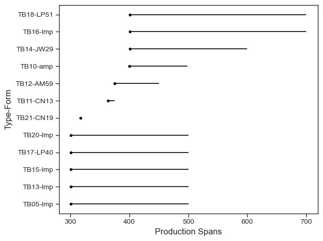

```python
KAGC_FUN.CC_DSpanPlt(b503, "N", "", "", start= 300, stop=750)
```

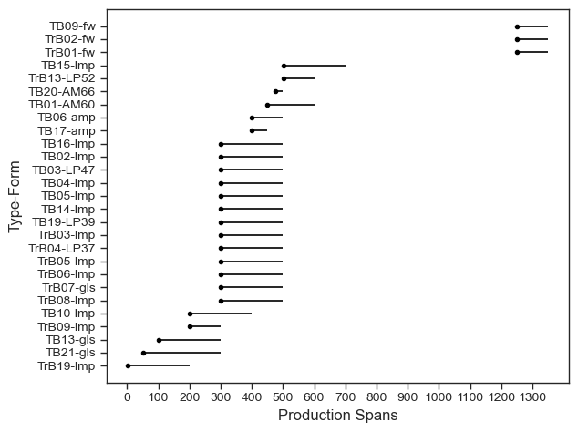

```python
KAGC_FUN.CC_DSpanPlt(bds1, "N", "", "", start= 0, stop=1400)
```

```python
#du_ttest = pd.concat([b503.CC_TPQS(), bds1.CC_TPQS()])
```

```python
#du_ttest.to_excel("B_du_ttests.xlsx")
```